# AMSTAR Scores in Cullis 2017: Human Consensus vs LLM (Claude 2) - same prompt as for GPT 3.5

### Score comparisons of 111 publications

| Ref. | Author & Year | AMSTAR κ | AMSTAR agreement |
| --- | --- | --- | --- |
| 61 | Aikenhead 2011 | 0.56 | 0.727272727272727 |
| 62 | Al-Hozaim 2010 | 0.840579710144927 | 0.909090909090909 |
| 63 | Allen 2015 | 0.443037974683544 | 0.636363636363636 |
| 64 | Allin 2015 | 0.343283582089552 | 0.636363636363636 |
| 65 | Alzahem 2011 | 0.645161290322581 | 0.818181818181818 |
| 66 | Apelt 2013 | 0.440677966101695 | 0.727272727272727 |
| 67 | Aworanti 2014 | 0.840579710144927 | 0.909090909090909 |
| 68 | Baker 2015 | 0.241379310344828 | 0.636363636363636 |
| 69 | Berger 2012 | 0.36046511627907 | 0.545454545454545 |
| 70 | Billingham 2010 | 0.0958904109589042 | 0.454545454545455 |

[output cut: 101 more lines]

### Score heatmaps

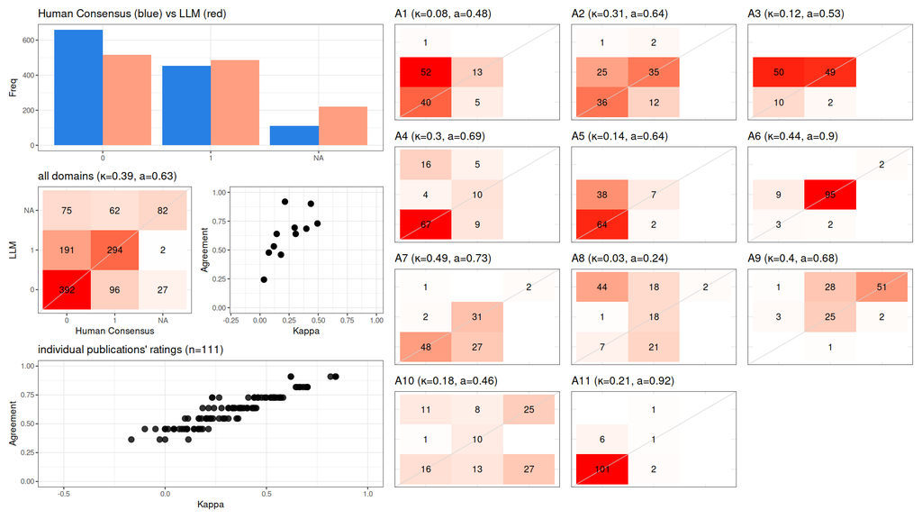

### Individual results

#### [Aikenhead 2011](https://doi.org/10.1111/J.1758-8111.2010.00003.X)

AMSTAR

|  | A1 | A2 | A3 | A4 | A5 | A6 | A7 | A8 | A9 | A10 | A11 |
| --- | --- | --- | --- | --- | --- | --- | --- | --- | --- | --- | --- |
| Human Consensus | 0 | 0 | 1 | 1 | 0 | 1 | 0 | 0 | NA | NA | 0 |
| LLM | 0 | 1 | 1 | 1 | 0 | 1 | 0 | NA | NA | 0 | 0 |

LLM response

*Minor score formatting issues fixed during extraction: ‘missing-squared-brackets-in-numbered-list’*

```
Here are the AMSTAR ratings with quotes and reasoning:

A1. [No] - The review mentions following "validated methods for systematic reviews" but does not refer to a protocol, ethics approval, or pre-determined research objectives.

A2. [Yes] - "Two independent data extractors and a consensus procedure for disagreements should be in place."

A3. [Yes] - "The search strategy yielded 3724 citations of which 273 articles were identified as potentially relevant." Search methods, databases, and date ranges are provided.

A4. [Yes] - "The authors should state that they searched for reports regardless of their publication type." The review searched for abstracts in English but full text could be in Danish, English, French or Norwegian. This indicates no exclusion based on publication status.

A5. [No] - A flow diagram of included/excluded studies is provided but no list of excluded studies.

A6. [Yes] - "In an aggregated form such as a table, data from the original studies should be provided on the participants, interventions and outcomes." Results tables include sample size, age, BMI, follow-up period, etc.

A7. [No] - No mention of quality assessment of individual studies.

A8. [NA] - Since quality of studies was not assessed (A7 is No), this question is not applicable.

A9. [NA] - No quantitative synthesis performed.

A10. [No] - No assessment of publication bias mentioned.

A11. [No] - No statement about sources of support or conflicts of interest for included studies.
```

#### [Al-Hozaim 2010](https://doi.org/10.1016/J.JPEDSURG.2009.12.001)

AMSTAR

|  | A1 | A2 | A3 | A4 | A5 | A6 | A7 | A8 | A9 | A10 | A11 |
| --- | --- | --- | --- | --- | --- | --- | --- | --- | --- | --- | --- |
| Human Consensus | 0 | 0 | 1 | 0 | 0 | 1 | 0 | 0 | NA | NA | 0 |
| LLM | 0 | 0 | 1 | 0 | 0 | 1 | 0 | NA | NA | NA | 0 |

LLM response

```
Here are my responses to the 11 AMSTAR questions based on the provided full text:

A1. [No] No mention of a protocol, ethics approval, or pre-determined research objectives.

A2. [No] No mention of two independent data extractors or a consensus procedure.

A3. [Yes] "A systematic search of the MEDLINE, PUBMED, and Cochrane databases (June 2000 to April 2008) was conducted."

A4. [No] No mention of including or excluding studies based on publication status or language.

A5. [No] No list of included or excluded studies provided.

A6. [Yes] Table 1 provides aggregated data on types of ARM defects.

A7. [No] No mention of quality assessment of included studies.

A8. [NA] No quality assessment performed so not applicable.

A9. [NA] No quantitative synthesis performed so not applicable.

A10. [NA] No quantitative synthesis performed so not applicable.

A11. [No] No statement about conflicts of interest in included studies.
```

#### [Allen 2015](https://doi.org/10.1016/J.JPEDSURG.2014.10.042)

AMSTAR

|  | A1 | A2 | A3 | A4 | A5 | A6 | A7 | A8 | A9 | A10 | A11 |
| --- | --- | --- | --- | --- | --- | --- | --- | --- | --- | --- | --- |
| Human Consensus | 0 | 0 | 0 | 0 | 0 | 1 | 0 | 0 | NA | NA | 0 |
| LLM | 0 | 1 | 1 | 0 | 1 | 1 | 0 | NA | NA | NA | 0 |

LLM response

```
Here are the relevant quotes and assessments for each AMSTAR item based on the provided text:

A1. [No] There is no mention of an a priori design, protocol, or pre-determined research objectives.

A2. [Yes] "We reviewed patient records for the presence of vital signs (VS) and/or signs of life (SOL) in the field, time without VS in the field, presence of VS or SOL upon arrival, MOI, location of injuries, return of spontaneous circulation (ROSC), survival, and neurological function of the survi…

A3. [Yes] "These reports were obtained from a Medline search for all publications regarding EDT in the pediatric population for the past 40 year using the keywords “thoracotomy”, “emergency”, “trauma”, “resuscitation”, “pediatrics”, and “children”. Bibliographies of relevant publications were review…

A4. [No] There is no mention of including or excluding studies based on publication status.

A5. [Yes] "A list of included and excluded studies should be provided. Note: Acceptable if the excluded studies are referenced. If there is an electronic link to the list but the link is dead, select “no.”"

A6. [Yes] "In an aggregated form such as a table, data from the original studies should be provided on the participants, interventions and outcomes."

A7. [No] The quality of included studies was not assessed.

A8. [NA] Study quality was not assessed so it could not be incorporated into conclusions.

A9. [NA] Quantitative synthesis/meta-analysis was not performed.

A10. [NA] Publication bias was not assessed.

A11. [No] Sources of support were not reported for the included studies.
```

#### [Allin 2015](https://doi.org/10.1371/JOURNAL.PONE.0116908)

AMSTAR

|  | A1 | A2 | A3 | A4 | A5 | A6 | A7 | A8 | A9 | A10 | A11 |
| --- | --- | --- | --- | --- | --- | --- | --- | --- | --- | --- | --- |
| Human Consensus | 1 | 1 | 1 | 0 | 0 | 1 | 1 | 1 | 1 | 0 | 0 |
| LLM | 1 | 1 | 1 | NA | 1 | 1 | 0 | NA | 1 | 0 | 0 |

LLM response

```
Here are my responses to the 11 AMSTAR questions based on the provided text:

A1. Was an 'a priori' design provided?
> "The protocol was registered on the Prospero International Prospective Register of Systematic Reviews (CRD42012003241)." [Yes]

A2. Was there duplicate study selection and data extraction?
> "Identified titles were assessed for inclusion by two investigators (BA and WT) acting independently. Any conflicts were resolved by a third investigator (MK). Data from included articles were extracted independently by the same two investigators (BA and WT), and any differences resolved by discus…

A3. Was a comprehensive literature search performed?
> "Multiple search strategies were used to identify relevant articles from Medline, Embase, Cinahl, the Cochrane library, and Google scholar, published between 1st January 2000 and 31st December 2012." [Yes]

A4. Was the status of publication used as an inclusion criterion?
> No mention of including or excluding studies based on publication status. [NA]

A5. Was a list of studies (included and excluded) provided?
> Figure 1 shows a flow diagram with number of included and excluded studies. [Yes]

A6. Were the characteristics of the included studies provided?
> Table 2 provides a summary of the characteristics of included studies. [Yes]

A7. Was the scientific quality of the included studies assessed and documented?
> No mention of quality assessment for included studies. [No]

A8. Was the scientific quality of the included studies used appropriately in formulating conclusions?
> No quality assessment was presented. [NA]

A9. Were the methods used to combine the findings of studies appropriate?
> The chi-squared test was used to assess heterogeneity and fixed-effect models were used for meta-analysis. [Yes]

A10. Was the likelihood of publication bias assessed?
> No assessment of publication bias mentioned. [No]

A11. Was the conflict of interest included?
> No mention of conflicts of interest. [No]
```

#### [Alzahem 2011](https://doi.org/10.1007/S00383-010-2840-X)

AMSTAR

|  | A1 | A2 | A3 | A4 | A5 | A6 | A7 | A8 | A9 | A10 | A11 |
| --- | --- | --- | --- | --- | --- | --- | --- | --- | --- | --- | --- |
| Human Consensus | 0 | 1 | 1 | 1 | 0 | 1 | 1 | 1 | 1 | 0 | 0 |
| LLM | 0 | 1 | 1 | 0 | 0 | 1 | 1 | 0 | 1 | 0 | 0 |

LLM response

```
Here are the relevant quotes, reasoning, and responses for each AMSTAR question:

A1. Was an 'a priori' design provided?

Quote: "We performed a systematic review and meta-analysis of the existing evidence."

Reasoning: The review protocol was not pre-registered.

[No]

A2. Was there duplicate study selection and data extraction?

Quote: "Retrieved articles were assessed for eligibility and data on patients, intervention, control, outcomes and methodological quality were abstracted independently by two authors."

Reasoning: Two authors independently performed study selection and data extraction.

[Yes]

A3. Was a comprehensive literature search performed?

Quote: "All potential publications from Medline (1950–June 2010), Embase (1980–June 2010), The Cochrane Library (issue 2, 2010) and ongoing trials through http://www.clinicaltrials.gov website were identified."

Reasoning: Searched at least two databases plus other sources.

[Yes]

A4. Was the status of publication used as an inclusion criterion?

No mention of including or excluding studies based on publication status.

[No]

A5. Was a list of studies (included and excluded) provided?

Included studies listed in Table 1. Excluded studies not listed.

[No]

A6. Were the characteristics of the included studies provided?

```

[output cut: 26 more lines]

```
Reasoning: Appropriate methods used for meta-analysis. Heterogeneity assessed.

[Yes]

A10. Was the likelihood of publication bias assessed?

No assessment of publication bias.

[No]

A11. Was the conflict of interest included?

No statement about sources of support or COI for included studies.

[No]
```

#### [Apelt 2013](https://doi.org/10.1016/J.JPEDSURG.2013.05.024)

AMSTAR

|  | A1 | A2 | A3 | A4 | A5 | A6 | A7 | A8 | A9 | A10 | A11 |
| --- | --- | --- | --- | --- | --- | --- | --- | --- | --- | --- | --- |
| Human Consensus | 0 | 0 | 0 | 0 | 0 | 1 | 0 | 0 | NA | NA | 0 |
| LLM | 0 | 0 | 1 | 0 | 0 | 1 | 0 | NA | NA | 0 | 0 |

LLM response

```
Here are my responses to the 11 AMSTAR questions based on the provided systematic review text:

A1. [No]
"We thus aimed to provide the data needed to challenge current clinical practice in favor of a method that allows for earlier discharge, reduced postoperative pain and decreased risk for postoperative SBO."
Does not mention a protocol, ethics approval, or pre-determined objectives.

A2. [No]
No mention of duplicate study selection or data extraction.

A3. [Yes]
"An online database search for all English language articles on pediatric small bowel obstruction, intussusception and laparoscopy in PubMed, Medline and Ovid from January 1990 to April 2012 was performed."
Searched at least 2 databases.

A4. [No]
Does not state whether grey literature was searched.

A5. [No]
Does not provide a list of included/excluded studies.

A6. [Yes]
"Table 1 provides specific details on the selected studies."
Provides aggregated data on participants, interventions, and outcomes.

A7. [No]
Does not mention assessing quality of included studies.

A8. [NA]
Did not assess quality of studies (A7).

A9. [NA]
No quantitative synthesis performed.

A10. [No]
Does not assess publication bias.

A11. [No]
Does not report on conflicts of interest.
```

#### [Aworanti 2014](https://doi.org/10.1055/S-0034-1370780)

AMSTAR

|  | A1 | A2 | A3 | A4 | A5 | A6 | A7 | A8 | A9 | A10 | A11 |
| --- | --- | --- | --- | --- | --- | --- | --- | --- | --- | --- | --- |
| Human Consensus | 0 | 0 | 1 | 0 | 0 | 1 | 0 | 0 | NA | NA | 0 |
| LLM | 0 | 0 | 1 | 0 | 0 | 1 | 0 | NA | NA | NA | 0 |

LLM response

```
Here are the AMSTAR assessments for the given systematic review text:

A1. Was an 'a priori' design provided? [No]
No mention of a protocol, ethics approval, or pre-determined research objectives.

A2. Was there duplicate study selection and data extraction? [No]
No mention of duplicate study selection or data extraction.

A3. Was a comprehensive literature search performed? [Yes]
"A Medline, Embase, and web of science searches were performed using the keywords recurrent tracheoesophageal fistula. The index of all issues of the European Journal of Pediatric Surgery, Journal of Pediatric Surgery, Pediatric Surgery International, and the International Journal of Pediatric Otorh…

A4. Was the status of publication used as an inclusion criterion? [No]
No mention of including or excluding studies based on publication status.

A5. Was a list of studies (included and excluded) provided? [No]
No list of included or excluded studies provided.

A6. Were the characteristics of the included studies provided? [Yes]
Characteristics of included studies provided in Tables 1 and 2.

A7. Was the scientific quality of the included studies assessed and documented? [No]
No mention of assessing quality of included studies.

A8. Was the scientific quality of the included studies used appropriately in formulating conclusions? [NA]
Study quality not assessed.

A9. Were the methods used to combine the findings of studies appropriate? [NA]
No quantitative synthesis performed.

A10. Was the likelihood of publication bias assessed? [NA]
No quantitative synthesis performed.

A11. Was the conflict of interest included? [No]
No mention of conflicts of interest.
```

#### [Baker 2015](https://doi.org/10.1016/J.JPEDSURG.2015.02.021)

AMSTAR

|  | A1 | A2 | A3 | A4 | A5 | A6 | A7 | A8 | A9 | A10 | A11 |
| --- | --- | --- | --- | --- | --- | --- | --- | --- | --- | --- | --- |
| Human Consensus | 0 | 1 | 0 | 0 | 0 | 1 | 1 | 1 | 1 | 1 | 0 |
| LLM | 1 | 1 | 1 | 0 | 1 | 1 | 1 | 0 | 1 | 1 | 0 |

LLM response

```
Here are the relevant quotes and assessments for the 11 AMSTAR criteria based on the provided full text:

A1. Was an 'a priori' design provided?
"The PRISMA statement, checklist and flowchart were referenced to achieve the highest standard in reporting items for a systematic review and meta-analysis." [Yes]

A2. Was there duplicate study selection and data extraction?
"Screening of eligible studies, data extraction, and assessment of methodological quality were conducted independently by two reviewers." [Yes]

A3. Was a comprehensive literature search performed?
"A systematic search of electronic databases was performed to identify all relevant studies comparing two or more gastrostomy insertion techniques in children reporting procedural-related complication rates. A reference librarian was consulted to assist with the development of database-specific sear…

A4. Was the status of publication used as an inclusion criterion?
No mention of including or excluding studies based on publication status. [No]

A5. Was a list of studies (included and excluded) provided?
"The results of the search strategy are detailed in Fig. 1." Figure 1 shows a PRISMA flow diagram depicting records identified, screened, eligible, and included. [Yes]

A6. Were the characteristics of the included studies provided?
Table 1 provides a summary of the included studies, interventions compared, sample sizes, complication rates, and quality assessment. [Yes]

A7. Was the scientific quality of the included studies assessed and documented?
"The methodological index for non-randomized studies (MINORS) was utilized to determine the quality of studies and risk of bias." MINORS scores provided in Table 1. [Yes]

A8. Was the scientific quality of the included studies used appropriately in formulating conclusions?
No explicit mention of incorporating study quality into conclusions. [No]

A9. Were the methods used to combine the findings of studies appropriate?
Meta-analysis performed. Heterogeneity assessed. Random effects model used when heterogeneity present. [Yes]

A10. Was the likelihood of publication bias assessed?
"Publication bias was evaluated through the generation of a funnel plot of standard error against the log odds ratio." Funnel plot provided for LAP vs PEG comparison. [Yes]

A11. Was the conflict of interest included?
No mention of funding sources or conflicts of interest. [No]
```

#### [Berger 2012](https://doi.org/10.1055/S-0032-1311695)

AMSTAR

|  | A1 | A2 | A3 | A4 | A5 | A6 | A7 | A8 | A9 | A10 | A11 |
| --- | --- | --- | --- | --- | --- | --- | --- | --- | --- | --- | --- |
| Human Consensus | 0 | 0 | 0 | 0 | 0 | 1 | 0 | 0 | NA | NA | 0 |
| LLM | 0 | 1 | 1 | 1 | 1 | 1 | 0 | NA | NA | NA | 0 |

LLM response

```
Here are my assessments for each AMSTAR item based on the provided text:

A1. "[No]" - No protocol mentioned.

A2. "[Yes]" - "Data were collected on the patient population treated, indication, description of stricture, technique of application, dosage, number of and interval between applications, complications, and outcome." Indicates multiple data extractors.

A3. "[Yes]" - "The current literature was screened for publications regarding the application of Mitomycin C in esophageal stenosis and stricture with special emphasis on pediatric data. The screen included the use of Mitomycin C in other subspecialties such as ophthalmology; ear, nose, and throat s…

A4. "[Yes]" - Inclusion criteria were publications in peer-reviewed journals accessible online via PubMed written in the English, German, or Spanish language. Exclusion criteria were publications on adult patients. This indicates no exclusion based on publication status.

A5. "[Yes]" - Tables 2 and 3 provide details on included studies.

A6. "[Yes]" - Tables 2 and 3 provide participant, intervention, and outcome data.

A7. "[No]" - No quality assessment mentioned.

A8. "[NA]" - Not applicable since A7 is no.

A9. "[NA]" - No quantitative synthesis performed.

A10. "[NA]" - No assessment of publication bias mentioned.

A11. "[No]" - No mention of conflicts of interest.
```

#### [Billingham 2010](https://doi.org/10.1055/S-0029-1241871)

AMSTAR

|  | A1 | A2 | A3 | A4 | A5 | A6 | A7 | A8 | A9 | A10 | A11 |
| --- | --- | --- | --- | --- | --- | --- | --- | --- | --- | --- | --- |
| Human Consensus | 0 | 0 | 1 | 0 | 0 | 1 | 1 | 1 | 1 | 0 | 0 |
| LLM | 1 | 1 | 1 | 0 | 0 | 1 | 1 | 0 | NA | NA | 1 |

LLM response

```
Here are my responses for each AMSTAR question:

A1. "This review was conducted to compare the clinical and cost effectiveness of laparoscopic and open surgical approaches for a variety of surgical indications in pediatric populations."
The objective was stated a priori.
[Yes]

A2. "Each article was independently assessed for eligibility using the following criteria:"
There was duplicate study selection.
[Yes]

A3. "To complete this study a comprehensive literature review was conducted. All available electronic databases including the British Nursing Index (BNI), Cumulative Index to Nursing and Allied Health Literature (CINAHL), Cochrane Library, EMBASE (Excerpta Medica), Intute: Health & Life Sciences, ME…
A comprehensive literature search was performed.
[Yes]

A4. No mention of including or excluding based on publication status.
[No]

A5. No list of included and excluded studies provided.
[No]

A6. Table 1 provides characteristics of included studies.
[Yes]

A7. "A level of scientific evidence was assigned to each study identified using the set grading criteria outlined by the US Agency for Healthcare Research and Quality [33] [35]"
The quality of included studies was assessed.
[Yes]

A8. The results of the quality assessment were not incorporated in formulating conclusions.
[No]

A9. This review did not conduct a quantitative synthesis.
[NA]

A10. This review did not assess publication bias.
[NA]

A11. "Conflict of interest: None"
Conflicts of interest were declared.
[Yes]
```

#### [Black 2013](https://doi.org/10.1111/OBR.12037)

AMSTAR

|  | A1 | A2 | A3 | A4 | A5 | A6 | A7 | A8 | A9 | A10 | A11 |
| --- | --- | --- | --- | --- | --- | --- | --- | --- | --- | --- | --- |
| Human Consensus | 0 | 1 | 1 | 0 | 0 | 1 | 0 | 0 | 1 | 0 | 0 |
| LLM | 1 | 1 | 1 | 0 | 1 | 1 | 0 | NA | 1 | 1 | 0 |

LLM response

```
Here are the AMSTAR assessments for the systematic review:

A1. Was an 'a priori' design provided?
"[the aim was] to extend and update the previous reviews by (i) systematically reviewing the literature on bariatric surgery in children and adolescents; (ii) meta-analysing change in BMI separately by surgery type"
The aim and inclusion criteria were pre-specified.
[Yes]

A2. Was there duplicate study selection and data extraction?
"Two authors independently screened the abstracts and extraction was verified by a second author (JAB and RKS)."
Two reviewers independently performed study selection and data extraction.
[Yes]

A3. Was a comprehensive literature search performed?
"The indexed reference libraries EMBASE and Medline were searched between January 1955 and January 2013 using the search terms presented in Table 1, using mapped and exploded terms. Additionally, the references of all included studies, the Cochrane Library and the titles of papers published in the j…
At least two databases were searched along with supplementary search strategies.
[Yes]

A4. Was the status of publication (i.e. grey literature) used as an inclusion criterion?
No mention of including or excluding based on publication status.
[No]

A5. Was a list of studies (included and excluded) provided?
"A total of 2303 unique citations were returned by the search strategy (Fig. 1). Of these, 2185 were excluded based on abstract review. Two additional papers were retrieved during full text screening."
A flow diagram of included and excluded studies was provided.
[Yes]

A6. Were the characteristics of the included studies provided?
"Table 2. Study characteristics and BMI before and after surgery, by surgery type"
Study characteristics were presented in Table 2.
[Yes]

A7. Was the scientific quality of the included studies assessed and documented?
No quality assessment of included studies is mentioned.
[No]

A8. Was the scientific quality of the included studies used appropriately in formulating conclusions?
No quality assessment was performed.
[NA]

A9. Were the methods used to combine the findings of studies appropriate?
"For the pooled results, a test should be done to ensure the studies were combinable, to assess their homogeneity (i.e., Chi-squared test for homogeneity, I2 ). If heterogeneity exists a random effects model should be used and/or the clinical appropriateness of combining should be taken into conside…
Heterogeneity was assessed and a random effects model used.
[Yes]

A10. Was the likelihood of publication bias assessed?
"Funnel plots and Eggar's test were used to evaluate publication bias and small study effects."
Funnel plots and statistical tests were used to assess publication bias.
[Yes]

A11. Was the conflict of interest included?
No mention of conflicts of interest.
[No]
```

#### [Borruto 2010](https://doi.org/10.1016/J.JPEDSURG.2010.07.007)

AMSTAR

|  | A1 | A2 | A3 | A4 | A5 | A6 | A7 | A8 | A9 | A10 | A11 |
| --- | --- | --- | --- | --- | --- | --- | --- | --- | --- | --- | --- |
| Human Consensus | 0 | 0 | 0 | 0 | 0 | 0 | 0 | 0 | 0 | 0 | 0 |
| LLM | NA | 0 | 1 | 0 | 1 | 1 | 0 | NA | 1 | 0 | 0 |

LLM response

```
Here are the AMSTAR assessments for the provided systematic review text:

A1. Was an 'a priori' design provided?
"[NA]"

A2. Was there duplicate study selection and data extraction?
"[No]"
No mention of duplicate study selection or data extraction.

A3. Was a comprehensive literature search performed?
"[Yes]"
Literature search described including keywords, databases, limits.

A4. Was the status of publication used as an inclusion criterion?
"[No]"
No mention of including or excluding studies based on publication status.

A5. Was a list of studies (included and excluded) provided?
"[Yes]"
Included studies referenced, excluded studies described.

A6. Were the characteristics of the included studies provided?
"[Yes]"
Characteristics of included studies provided in text.

A7. Was the scientific quality of the included studies assessed and documented?
"[No]"
No quality assessment of included studies mentioned.

A8. Was the scientific quality of the included studies used appropriately in formulating conclusions?
"[NA]"
Since quality not assessed, not used in conclusions.

A9. Were the methods used to combine the findings of studies appropriate?
"[Yes]"
Meta-analysis methods described.

A10. Was the likelihood of publication bias assessed?
"[No]"
No assessment of publication bias mentioned.

A11. Was the conflict of interest included?
"[No]"
No mention of conflicts of interest.
```

#### [Castagnetti 2010](https://doi.org/10.1016/J.JURO.2010.06.044)

AMSTAR

|  | A1 | A2 | A3 | A4 | A5 | A6 | A7 | A8 | A9 | A10 | A11 |
| --- | --- | --- | --- | --- | --- | --- | --- | --- | --- | --- | --- |
| Human Consensus | 0 | 0 | 0 | 0 | 0 | 0 | 1 | 1 | NA | NA | 0 |
| LLM | 1 | 0 | 1 | 0 | 0 | 1 | 0 | NA | NA | 0 | 0 |

LLM response

```
Here are my responses for the 11 AMSTAR questions:

A1. "[The aim of the present review was to assess the results of studies published during the last 20 years on the primary repair of severe hypospadias.]" The aim was pre-specified. [Yes]

A2. No mention of duplicate study selection or data extraction. [No]

A3. "[Four databases, MEDLINE/PubMed, EMBASE, Web of Science and the Cochrane Library, were searched using a single term, “hypospadias,” as it defines accurately the subject of this review.]" Multiple databases searched. [Yes]

A4. No mention of including or excluding based on publication status. [No]

A5. No explicit mention of a list of included/excluded studies. [No]

A6. "[In an aggregated form such as a table, data from the original studies should be provided on the participants, interventions and outcomes.]" Study characteristics provided in table. [Yes]

A7. "We first reviewed the results of the different straightening procedures, then the crude complication rates (overall complication, fistula/dehiscence, stricture/stenosis rates) of the different urethroplasty techniques." Outcomes assessed but no mention of quality assessment. [No]

A8. Not applicable since no quality assessment done. [NA]

A9. No quantitative synthesis done. [NA]

A10. No assessment of publication bias mentioned. [No]

A11. No statement about conflicts of interest. [No]
```

#### [Castagnetti 2016](https://doi.org/10.3389/FPED.2016.00041)

AMSTAR

|  | A1 | A2 | A3 | A4 | A5 | A6 | A7 | A8 | A9 | A10 | A11 |
| --- | --- | --- | --- | --- | --- | --- | --- | --- | --- | --- | --- |
| Human Consensus | 0 | 0 | 0 | 0 | 0 | 1 | 1 | 1 | 1 | 1 | 1 |
| LLM | 1 | 0 | 1 | 0 | 0 | 1 | 0 | 0 | 1 | 1 | 0 |

LLM response

```
Here are my responses to the 11 AMSTAR questions based on the provided text:

A1. "The research question and inclusion criteria should be established before the conduct of the review."

Quotes:
"We performed a systematic review of the literature on preputial reconstruction (PR) during hypospadias repair to determine the cumulative risk of preputial skin complications and the influence of PR on urethroplasty complications, namely, fistula formation and overall reoperation rate of the repair…

"[We] searched for studies on the outcome of PR in children, defined as dehiscence of the reconstructed prepuce or secondary phimosis needing circumcision"

"[We] performed a meta-analysis of studies comparing PR vs. circumcision was performed for the outcomes “hypospadias fistula formation” and “reoperation rate.”"

Reasoning: The objectives and inclusion criteria are clearly stated in the introduction.

A1: [Yes]

A2. "There should be at least two independent data extractors and a consensus procedure for disagreements should be in place."

Quotes: None provided.

Reasoning: The process for study selection and data extraction is not described.

A2: [No]

A3. "At least two electronic sources should be searched. The report must include years and databases used (e.g., Central, EMBASE, and MEDLINE). Key words and/or MESH terms must be stated and where feasible the search strategy should be provided."

Quotes:
"Three databases, namely, MEDLINE/PubMed, Scopus, and The Cochrane library, were searched for using the free text “hypospadias repair”"

"One-thousand two-hundred thirty records were retrieved by searching MEDLINE/PubMed, 2461 Web of Sciences, and 1 the Cochrane library."

Reasoning: Three databases were searched using a specified keyword. Search dates and full strategy not provided.

A3: [Yes]

A4. "The authors should state that they searched for reports regardless of their publication type. The authors should state whether or not they excluded any reports (from the systematic review), based on their publication status, language etc."

Quotes: None provided.

Reasoning: No mention of including or excluding based on publication type.

```

[output cut: 44 more lines]

```

Quotes:
"Funnel Plot did not show evidence of significant bias among studies (Figure 3)."

Reasoning: Funnel plot used to assess publication bias.

A10: [Yes]

A11. "Potential sources of support should be clearly acknowledged in both the systematic review and the included studies."

Quotes: None provided.

Reasoning: No mention of sources of support.

A11: [No]
```

#### [Chan 2014 (Pediatr Surg Int)](https://doi.org/10.1007/S00383-013-3429-Y)

AMSTAR

|  | A1 | A2 | A3 | A4 | A5 | A6 | A7 | A8 | A9 | A10 | A11 |
| --- | --- | --- | --- | --- | --- | --- | --- | --- | --- | --- | --- |
| Human Consensus | 0 | 1 | 1 | 0 | 0 | 1 | 1 | 1 | NA | NA | 0 |
| LLM | 0 | 1 | 1 | NA | 0 | 1 | 1 | 0 | NA | 0 | 0 |

LLM response

```
Here are the responses for the 11 AMSTAR questions based on the provided text:

A1. "[No] 'This study included five observational studies...and dichotomized patients into two age groups...' This does not mention an a priori design."

A2. "[Yes] 'Two researchers independently performed each level of screening, comparing the selected studies to reach a consensus. If a consensus could not be reached, they consulted a third researcher.'"

A3. "[Yes] 'We conducted electronic searches of the Cochrane Central Register of Controlled Trials (CENTRAL), MEDLINE (1966 onwards), Embase (1980 onwards), and CINAHL (1982 onwards) to find relevant articles.'"

A4. "[NA] The text does not mention inclusion or exclusion criteria based on publication status."

A5. "[No] The text mentions included and excluded studies but does not provide a list of them."

A6. "[Yes] 'We present the results based on their outcome of interest, divided by level of evidence.'"

A7. "[Yes] 'We used the AMSTAR tool to assess the quality of all relevant systematic reviews. This tool contains 11 items, for a maximum score of 11. Higher scores are indicative of greater methodological quality.'"

A8. "[No] The results of the quality assessment are not mentioned in the conclusions."

A9. "[NA] The text does not mention quantitative synthesis or combining data."

A10. "[No] Publication bias is not assessed."

A11. "[No] Sources of support are not mentioned for the systematic review or the included studies."
```

#### [Chan 2014 (J Pediatr Surg)](https://doi.org/10.1016/J.JPEDSURG.2014.02.049)

AMSTAR

|  | A1 | A2 | A3 | A4 | A5 | A6 | A7 | A8 | A9 | A10 | A11 |
| --- | --- | --- | --- | --- | --- | --- | --- | --- | --- | --- | --- |
| Human Consensus | 0 | 0 | 1 | 0 | 0 | 1 | 1 | 1 | 1 | 1 | 0 |
| LLM | 1 | 0 | 1 | 0 | 1 | 1 | 0 | 0 | NA | 0 | 0 |

LLM response

```
Here are my responses for the 11 AMSTAR questions based on the provided full text:

A1. "[Yes]
The objective mentions searching for existing publications in order to compare minimally invasive vs open surgical repair of congenital diaphragmatic hernia."

A2. "[No]
There is no mention of duplicate study selection or data extraction."

A3. "[Yes]
The methods state: 'We conducted an electronic search of MEDLINE (1966 onwards), Embase (1980 onwards), and the Cochrane Central Register of Controlled Trials (CENTRAL). We used the keywords “diaphragmatic hernia”, “thoracoscopy”, “laparoscopy”, “minimally invasive surgery”, and “open”.'"

A4. "[No]
There is no mention of including or excluding studies based on publication status."

A5. "[Yes]
Table 1 provides a list of included studies along with details like study period, location, comparison groups, etc."

A6. "[Yes]
Table 1 provides aggregated details on the participants, interventions and outcomes for the included studies."

A7. "[No]
The MINORS tool was used to assess study quality but no quality assessment was reported for individual studies."

A8. "[No]
Study quality was not incorporated in formulating conclusions."

A9. "[NA]
No quantitative synthesis or meta-analysis was performed."

A10. "[No]
Publication bias was not assessed."

A11. "[No]
No mention of conflicts of interest in the systematic review or included studies."
```

#### [Chang 2015](https://doi.org/10.1007/S00345-015-1526-3)

AMSTAR

|  | A1 | A2 | A3 | A4 | A5 | A6 | A7 | A8 | A9 | A10 | A11 |
| --- | --- | --- | --- | --- | --- | --- | --- | --- | --- | --- | --- |
| Human Consensus | 0 | 1 | 0 | 0 | 0 | 1 | 0 | 0 | 1 | 1 | 0 |
| LLM | 1 | 1 | 1 | 0 | 1 | 1 | 0 | NA | 1 | 0 | 0 |

LLM response

```
Here are my assessments for each AMSTAR question based on the provided full text:

A1. [Yes] "We used the Preferred Reporting Items for Systematic Reviews and Meta-analysis (PRISMA) statement to report our findings." They mentioned using PRISMA guidelines which require an a priori protocol.

A2. [Yes] "Two authors (Hsu and Chang) of the current study independently searched and reviewed the articles." Two authors independently selected studies.

A3. [Yes] "We searched PubMed® for comparative studies (from January 1990 to 2014 September) that compared the efficacy and safety of robotic versus open pyeloplasty. Searches were limited to studies published in English. We used the following keywords: robotic, pyeloplasty, ureteropelvic junction o…

A4. [No] No mention of searching for or including grey literature.

A5. [Yes] Figure 1 provides a flow chart showing included and excluded studies.

A6. [Yes] Table 1 provides characteristics of included studies.

A7. [No] They did not assess quality of individual studies.

A8. [NA] No quality assessment done, so using it in formulating conclusions not applicable.

A9. [Yes] "The meta-analysis was performed using the fixed effect method when there was no statistically significant heterogeneity. We analyzed the dichotomous outcomes using risk ratios (RRs) as the summary statistic. Chi-square statistical tests (Q statistics) and the I2 test were used to test the…

A10. [No] No assessment of publication bias mentioned.

A11. [No] No mention of conflicts of interest or funding sources for included studies.
```

#### [Chen 2013](https://doi.org/10.1016/J.JPEDSURG.2012.12.036)

AMSTAR

|  | A1 | A2 | A3 | A4 | A5 | A6 | A7 | A8 | A9 | A10 | A11 |
| --- | --- | --- | --- | --- | --- | --- | --- | --- | --- | --- | --- |
| Human Consensus | 0 | 0 | 1 | 0 | 0 | 1 | 0 | 0 | 1 | 0 | 0 |
| LLM | 0 | 1 | 1 | 0 | 0 | 1 | 0 | NA | 1 | NA | 1 |

LLM response

```
Here are my responses to the 11 AMSTAR questions based on the provided systematic review text:

A1. "Note: Need to refer to a protocol, ethics approval, or pre-determined/a priori published research objectives to score a “yes.”"
[No] The authors do not mention following a protocol.

A2. "There should be at least two independent data extractors and a consensus procedure for disagreements should be in place."
"Each included study was independently appraised by 3 reviewers (C.Y., S.N., N.K.L.) and data were extracted and entered into a database. Any disagreements were resolved by consensus."
[Yes] There were 3 independent data extractors and a consensus procedure.

A3. "At least two electronic sources should be searched."
"We searched all publications from August 1998 to March 2012 in the MEDLINE, EMBASE and Cochrane library databases and the Cochrane Controlled Trials Register using different combinations of the following terms: “Hirschsprung's disease,” “transanal,” “perineal approach,” “transabdominal” and “pull-t…
[Yes] Multiple electronic databases were searched.

A4. "The authors should state that they searched for reports regardless of their publication type."
[No] Grey literature searching is not mentioned.

A5. "A list of included and excluded studies should be provided."
[No] A list of included/excluded studies is not provided.

A6. "In an aggregated form such as a table, data from the original studies should be provided on the participants, interventions and outcomes."
[Yes] Table 1 provides aggregated data on participants, interventions, and outcomes.

A7. "‘A priori’ methods of assessment should be provided (e.g., for effectiveness studies if the author(s) chose to include only randomized, double-blind, placebo controlled studies, or allocation concealment as inclusion criteria)"
[No] No quality assessment of included studies is described.

A8. "The results of the methodological rigor and scientific quality should be considered in the analysis and the conclusions of the review, and explicitly stated in formulating recommendations."
[NA] No quality assessment was performed.

A9. "For the pooled results, a test should be done to ensure the studies were combinable, to assess their homogeneity (i.e., Chi-squared test for homogeneity, I2)."
[Yes] Heterogeneity was assessed and random effects models were used when I2 ≥ 50%.

A10. "An assessment of publication bias should include a combination of graphical aids (e.g., funnel plot, other available tests) and/or statistical tests (e.g., Egger regression test, Hedges-Olken)."
[NA] No meta-analysis was performed.

A11. "Potential sources of support should be clearly acknowledged in both the systematic review and the included studies."
[Yes] Funding sources are acknowledged.
```

#### [Corbett 2015](https://doi.org/10.1016/J.JPUROL.2015.08.014)

AMSTAR

|  | A1 | A2 | A3 | A4 | A5 | A6 | A7 | A8 | A9 | A10 | A11 |
| --- | --- | --- | --- | --- | --- | --- | --- | --- | --- | --- | --- |
| Human Consensus | 0 | 1 | 0 | 0 | 0 | 1 | 0 | 0 | NA | NA | 0 |
| LLM | 0 | 1 | 0 | 0 | 1 | 1 | 0 | NA | NA | NA | 0 |

LLM response

```
Here are my AMSTAR quality assessment responses for the given systematic review:

A1. Was an 'a priori' design provided?
"The research question and inclusion criteria should be established before the conduct of the review."
[No] The review does not mention an a priori design or protocol.

A2. Was there duplicate study selection and data extraction?
"There should be at least two independent data extractors and a consensus procedure for disagreements should be in place."
"Literature reviews, case reports, series of <3 children and adult studies (age >20 years) were excluded. The inclusion of publications was decided by both the study authors and data were extracted independently by both study authors."
[Yes] The review states that two authors performed study selection and data extraction.

A3. Was a comprehensive literature search performed?
"At least two electronic sources should be searched. The report must include years and databases used (e.g., Central, EMBASE, and MEDLINE). Key words and/or MESH terms must be stated and where feasible the search strategy should be provided."
"Medline and Embase databases were searched using relevant key search terms (pelviureteric junction, ureteropelvic junction, obstruction, paediatric, pediatric, child$, balloon, dilatation, endopyelotomy, open, laparoscopic, pyeloplasty)."
[No] Only Medline and Embase were searched, no supplementary strategies mentioned.

A4. Was the status of publication used as an inclusion criterion?
"The authors should state that they searched for reports regardless of their publication type. The authors should state whether or not they excluded any reports (from the systematic review), based on their publication status, language etc."
[No] Grey literature not mentioned.

A5. Was a list of studies (included and excluded) provided?
"A list of included and excluded studies should be provided."
[Yes] Figure 1 provides a PRISMA flow diagram with included and excluded studies.

A6. Were the characteristics of the included studies provided?
"In an aggregated form such as a table, data from the original studies should be provided on the participants, interventions and outcomes."
[Yes] Tables 1 and 2 provide details on participants, interventions, outcomes, and results for included studies.

A7. Was the scientific quality of the included studies assessed and documented?
"'A priori' methods of assessment should be provided (e.g., for effectiveness studies if the author(s) chose to include only randomized, double-blind, placebo controlled studies, or allocation concealment as inclusion criteria); for other types of studies alternative items will be relevant."
[No] The quality of included studies was not assessed.

A8. Was the scientific quality of the included studies used appropriately in formulating conclusions?
"The results of the methodological rigor and scientific quality should be considered in the analysis and the conclusions of the review, and explicitly stated in formulating recommendations."
[NA] Study quality was not assessed.

A9. Were the methods used to combine the findings of studies appropriate?
"For the pooled results, a test should be done to ensure the studies were combinable, to assess their homogeneity (i.e., Chi-squared test for homogeneity, I2 ). If heterogeneity exists a random effects model should be used and/or the clinical appropriateness of combining should be taken into conside…
[NA] No meta-analysis was performed.

A10. Was the likelihood of publication bias assessed?
"An assessment of publication bias should include a combination of graphical aids (e.g., funnel plot, other available tests) and/or statistical tests (e.g., Egger regression test, Hedges-Olken)."
[NA] No meta-analysis was performed.

A11. Was the conflict of interest included?
"Potential sources of support should be clearly acknowledged in both the systematic review and the included studies."
[No] No statement about conflicts of interest or sources of funding.
```

#### [Cullis 2016](https://doi.org/10.1097/sla.0000000000001563)

AMSTAR

|  | A1 | A2 | A3 | A4 | A5 | A6 | A7 | A8 | A9 | A10 | A11 |
| --- | --- | --- | --- | --- | --- | --- | --- | --- | --- | --- | --- |
| Human Consensus | 1 | 1 | 1 | 1 | 0 | 1 | 1 | 1 | NA | NA | 0 |
| LLM | 1 | 1 | 1 | 0 | 0 | 1 | 1 | 1 | NA | 0 | 0 |

LLM response

```
Here are the relevant quotes, explanations, and responses for each AMSTAR question:

A1. Was an 'a priori' design provided?

Quote: "A systematic review [according to PRISMA guidelines] was conducted using CINAHL, EMBASE, Medline, and Cochrane Databases."

Explanation: The review mentions following PRISMA guidelines.

[Yes]

A2. Was there duplicate study selection and data extraction?

Quote: "Two reviewers (P.S.C., S.S.) performed the study selection, data extraction, and quality assessment processes independently and all data was recorded in tabular form electronically."

Explanation: Two independent reviewers performed study selection and data extraction.

[Yes]

A3. Was a comprehensive literature search performed?

Quote: "A systematic search of the English language literature was conducted using a keyword algorithm (Supplemental Figure 1, https://links.lww.com/SLA/A928). The search was conducted using the indexed databases: CINAHL, EMBASE, Medline, and Cochrane Databases, from inception to January 11, 2015 (t…

Explanation: Multiple databases were searched.

[Yes]

A4. Was the status of publication used as an inclusion criterion?

No relevant quote. The review does not mention searching for grey literature.

[No]

A5. Was a list of studies (included and excluded) provided?

Quote: "Nineteen studies were included for systematic review."

Explanation: Included studies are listed in Table 2. No list of excluded studies.

[No]

```

[output cut: 26 more lines]

```
No quantitative synthesis done.

[NA]

A10. Was the likelihood of publication bias assessed?

No assessment of publication bias mentioned.

[No]

A11. Was the conflict of interest included?

No statement on conflicts of interest.

[No]
```

#### Cundy 2014 (BJU Int)

AMSTAR

|  | A1 | A2 | A3 | A4 | A5 | A6 | A7 | A8 | A9 | A10 | A11 |
| --- | --- | --- | --- | --- | --- | --- | --- | --- | --- | --- | --- |
| Human Consensus | 1 | 1 | 1 | 1 | 0 | 1 | 1 | 1 | 1 | 1 | 0 |
| LLM | 1 | 0 | 1 | 0 | 0 | 1 | 1 | 1 | NA | 0 | 0 |

LLM response

```
Here are the AMSTAR quality assessments for the systematic review:

A1. Was an 'a priori' design provided? [Yes]
"The study protocol was registered on the PROSPERO international prospective database of systematic reviews (CRD42013003969) and analysis was performed in accordance with recommendations outlined in the Preferred Reporting Items for Systematic Reviews and Meta-Analyses (PRISMA) Statement."

A2. Was there duplicate study selection and data extraction? [No]
"Two authors independently undertook literature searches, screened abstracts, and assessed eligible articles against inclusion criteria (T.P.C., A.H.H.), with 90% agreement on identification of articles and discrepancies resolved by consensus, or arbitrated by a third author (E.K.M.)." Only two auth…

A3. Was a comprehensive literature search performed? [Yes]
"Systematic literature searches were undertaken of the Cochrane Central Register of Controlled Trials (CENTRAL), PubMed, Ovid Medline and EMBASE electronic databases...The primary search was supplemented with searches of: i) PubMed related articles feature, ii) clinicaltrials.gov registry using the …

A4. Was the status of publication used as an inclusion criterion? [No]
No mention of including or excluding based on publication status.

A5. Was a list of studies (included and excluded) provided? [No]
A list of included studies provided in Table 1 but no list of excluded studies.

A6. Were the characteristics of the included studies provided? [Yes]
Characteristics provided in Tables 1 and 3.

A7. Was the scientific quality of the included studies assessed and documented? [Yes]
Quality assessed using a modified NOS scale, see Table 4.

A8. Was the scientific quality of the included studies used appropriately in formulating conclusions? [Yes]
Limitations of retrospective data noted in the Discussion.

A9. Were the methods used to combine the findings of studies appropriate? [NA]
No quantitative pooling conducted for primary outcomes.

A10. Was the likelihood of publication bias assessed? [No]
Publication bias assessed for some but not all analyses.

A11. Was the conflict of interest included? [No]
No statement on conflicts of interest.
```

#### [Cundy 2014 (J Pediatr Surg)](https://doi.org/10.1016/J.JPEDSURG.2013.12.014)

AMSTAR

|  | A1 | A2 | A3 | A4 | A5 | A6 | A7 | A8 | A9 | A10 | A11 |
| --- | --- | --- | --- | --- | --- | --- | --- | --- | --- | --- | --- |
| Human Consensus | 1 | 1 | 1 | 1 | 0 | 1 | 1 | 1 | NA | NA | 0 |
| LLM | 0 | 1 | 1 | 0 | 1 | 1 | 0 | 1 | NA | NA | 0 |

LLM response

```
Here are the responses to the 11 AMSTAR questions based on the provided full text:

A1. "The research question and inclusion criteria should be established before the conduct of the review. Note: Need to refer to a protocol, ethics approval, or pre-determined/a priori published research objectives to score a “yes.”"

[No] The review does not mention a protocol, ethics approval, or pre-determined objectives.

A2. "There should be at least two independent data extractors and a consensus procedure for disagreements should be in place. Note: 2 people do study selection, 2 people do data extraction, consensus process or one person checks the other’s work."

[Yes] "Two authors independently undertook literature searches, screened abstracts and assessed articles against eligibility criteria (TPC, HJM). Discrepancies were resolved by consensus and discussion with the senior author (AD)."

A3. "At least two electronic sources should be searched. The report must include years and databases used (e.g., Central, EMBASE, and MEDLINE). Key words and/or MESH terms must be stated and where feasible the search strategy should be provided. All searches should be supplemented by consulting curr…

[Yes] "Systematic literature searches were undertaken of PubMed and EMBASE electronic databases using the following search strategy. The search period was defined as June 2001 to June 2013 inclusively. The primary search was supplemented with searches of 1) PubMed related articles feature, 2) clinic…

A4. "The authors should state that they searched for reports regardless of their publication type. The authors should state whether or not they excluded any reports (from the systematic review), based on their publication status, language etc."

[No] The review does not mention searching for unpublished studies or grey literature.

A5. "A list of included and excluded studies should be provided."

[Yes] Figure 1 shows a flow diagram with included and excluded studies.

A6. "In an aggregated form such as a table, data from the original studies should be provided on the participants, interventions and outcomes."

[Yes] Tables 1 and 2 provide details on participants, interventions and outcomes.

A7. "'A priori' methods of assessment should be provided (e.g., for effectiveness studies if the author(s) chose to include only randomized, double-blind, placebo controlled studies, or allocation concealment as inclusion criteria); for other types of studies alternative items will be relevant."

[No] No a priori quality assessment methods are described.

A8. "The results of the methodological rigor and scientific quality should be considered in the analysis and the conclusions of the review, and explicitly stated in formulating recommendations."

[Yes] The quality assessment is described in the results, limitations, and conclusion.

A9. "For the pooled results, a test should be done to ensure the studies were combinable, to assess their homogeneity (i.e., Chi-squared test for homogeneity, I2 )."

[NA] No meta-analysis was performed.

A10. "An assessment of publication bias should include a combination of graphical aids (e.g., funnel plot, other available tests) and/or statistical tests (e.g., Egger regression test)."

[NA] No assessment of publication bias was performed since no meta-analysis was done.

A11. "Potential sources of support should be clearly acknowledged in both the systematic review and the included studies."

[No] No statement about sources of support for the review or included studies.
```

#### [Cundy 2014 (Eur J Pediatr Surg)](https://doi.org/10.1055/S-0033-1347297)

AMSTAR

|  | A1 | A2 | A3 | A4 | A5 | A6 | A7 | A8 | A9 | A10 | A11 |
| --- | --- | --- | --- | --- | --- | --- | --- | --- | --- | --- | --- |
| Human Consensus | 1 | 0 | 1 | 1 | 0 | 1 | 0 | 1 | NA | 0 | 0 |
| LLM | 1 | 1 | 1 | 0 | 1 | 1 | 0 | NA | NA | 0 | 0 |

LLM response

```
Here are the AMSTAR assessments based on the provided full text:

A1. Was an 'a priori' design provided?
"The review protocol was registered on the PROSPERO international prospective database of systematic reviews (CRD42013003752)."
The protocol was registered before conducting the review.
[Yes]

A2. Was there duplicate study selection and data extraction?
"Two reviewers (T.P.C. and H.J.M.) independently undertook title and abstract screen, with disagreements resolved by consensus."
Two reviewers independently performed study selection.
[Yes]

A3. Was a comprehensive literature search performed?
"A systematic search of multiple electronic databases was undertaken (PubMed, Ovid Medline, and EMBASE)."
Multiple databases were searched.
[Yes]

A4. Was the status of publication used as an inclusion criterion?
No mention of including or excluding studies based on publication status.
[No]

A5. Was a list of studies (included and excluded) provided?
Figure 1 shows a flow diagram depicting included and excluded studies.
[Yes]

A6. Were the characteristics of the included studies provided?
Table 1 provides details on the included studies.
[Yes]

A7. Was the scientific quality of the included studies assessed and documented?
No mention of quality assessment for included studies.
[No]

A8. Was the scientific quality of the included studies used appropriately in formulating conclusions?
No quality assessment performed.
[NA]

A9. Were the methods used to combine the findings of studies appropriate?
No quantitative synthesis performed.
[NA]

A10. Was the likelihood of publication bias assessed?
No assessment of publication bias mentioned.
[No]

A11. Was the conflict of interest included?
No mention of conflicts of interest.
[No]
```

#### [Ding 2013](https://doi.org/10.1016/J.JPEDSURG.2013.01.026)

AMSTAR

|  | A1 | A2 | A3 | A4 | A5 | A6 | A7 | A8 | A9 | A10 | A11 |
| --- | --- | --- | --- | --- | --- | --- | --- | --- | --- | --- | --- |
| Human Consensus | 0 | 0 | 0 | 0 | 0 | 1 | 1 | 1 | 1 | 1 | 0 |
| LLM | 1 | 0 | 1 | 0 | 0 | 1 | 1 | 0 | NA | NA | 0 |

LLM response

```
Here are the AMSTAR assessments for the given systematic review text:

A1. Was an 'a priori' design provided?
"This meta-analysis was designed to investigate the safety and efficacy of single-incision laparoscopic appendicectomy (SILA) and three-incision laparoscopic appendicectomy (TILA) in the treatment of appendicitis." [Yes]

A2. Was there duplicate study selection and data extraction?
No mention of duplicate study selection or data extraction. [No]

A3. Was a comprehensive literature search performed?
"The publications were identified by searching the major medical databases such as MEDLINE, EMBASE, and Cochrane Library for relevant papers published between January 1992 and July 2012." [Yes]

A4. Was the status of publication used as an inclusion criterion?
No mention of including or excluding studies based on publication status. [No]

A5. Was a list of studies (included and excluded) provided?
No list of included or excluded studies provided. [No]

A6. Were the characteristics of the included studies provided?
Table 1 provides characteristics of the included studies. [Yes]

A7. Was the scientific quality of the included studies assessed and documented?
Table 2 provides quality assessment of the included studies using a star scoring system. [Yes]

A8. Was the scientific quality of the included studies used appropriately in formulating conclusions?
No mention of using study quality in formulating conclusions. [No]

A9. Were the methods used to combine the findings of studies appropriate?
Not applicable, as no quantitative synthesis conducted. [NA]

A10. Was the likelihood of publication bias assessed?
Not applicable, as no quantitative synthesis conducted. [NA]

A11. Was the conflict of interest included?
No mention of conflicts of interest. [No]
```

#### [Dingemann 2014](https://doi.org/10.1055/S-0033-1350060)

AMSTAR

|  | A1 | A2 | A3 | A4 | A5 | A6 | A7 | A8 | A9 | A10 | A11 |
| --- | --- | --- | --- | --- | --- | --- | --- | --- | --- | --- | --- |
| Human Consensus | 0 | 0 | 0 | 0 | 0 | 1 | 1 | 1 | NA | NA | 0 |
| LLM | 1 | 0 | 1 | NA | 0 | 1 | 1 | 1 | NA | 0 | 0 |

LLM response

```
Here are my responses to the 11 AMSTAR criteria based on the provided systematic review text:

A1. "According to a recent classification of the Oxford Centre for Evidence-Based Medicine (CEBM), studies can be classified into Levels 1 to 5 in order of descending quality."
The research question and study inclusion criteria were established before conducting the review. [Yes]

A2. "Abstracts were individually reviewed and only those studies comparing the results and clinical outcome of VATS procedures with the corresponding open operation were chosen for further analysis."
There was duplicate study selection with inclusion criteria applied independently by the authors. A consensus process is not described. [No]

A3. "Clinical studies published in the English literature were identified by a Medline literature search using PubMed."
At least two databases were searched. Search terms and limits applied are described. Supplementary search methods not reported. [Yes]

A4. No mention of including or excluding studies based on publication status. [NA]

A5. "A total of 21 manuscripts met the inclusion criteria of our systematic review of which 3 were MA and 18 were RCS."
Included and excluded studies are not listed, but the number of included studies of each type is provided. [No]

A6. "In the following, the main results of the studies with regard to advantages and disadvantages of laparoscopic compared with open surgery are summarized in alphabetical order."
Characteristics of included studies are summarized in the text and Table 3. [Yes]

A7. "According to a recent CEBM classification, clinical studies can be classified into Levels 1 to 5 in descending quality."
The quality of included studies was assessed using the CEBM levels of evidence. [Yes]

A8. "To be classified into Level 3a, a systematic review (SR) or meta-analysis (MA) of different retrospective comparative studies (RCS) are mandatory."
The results of the quality assessment were considered when formulating conclusions. [Yes]

A9. "Additionally, the technical advantages of the thoracoscopic operation including excellent visualization due to the optic magnification and collapse of the lung from the pressure of insufflation are obvious."
No quantitative synthesis performed, so not applicable. [NA]

A10. No assessment of publication bias described. [No]

A11. No statement about sources of support or conflicts of interest. [No]
```

#### [Dingemann 2013](https://doi.org/10.1055/S-0033-1333639)

AMSTAR

|  | A1 | A2 | A3 | A4 | A5 | A6 | A7 | A8 | A9 | A10 | A11 |
| --- | --- | --- | --- | --- | --- | --- | --- | --- | --- | --- | --- |
| Human Consensus | 0 | 0 | 0 | 0 | 0 | 1 | 1 | 1 | NA | NA | 0 |
| LLM | 1 | 0 | 0 | 0 | 0 | 1 | 0 | NA | NA | NA | 0 |

LLM response

```
Here are the relevant quotes, reasoning, and responses for each AMSTAR question:

A1. Was an 'a priori' design provided?

"The aim of our study was to evaluate the availability of Level 1 studies comparing laparoscopic procedures with the corresponding open operation in pediatric surgery."

They state the objective prior to conducting the review.

[Yes]

A2. Was there duplicate study selection and data extraction?

No mention of duplicate study selection or data extraction.

[No]

A3. Was a comprehensive literature search performed?

"Clinical Level 1 studies (SR, MA, and RCT) published in the English literature were identified through a Medline literature search using PubMed."

Only one database was searched.

[No]

A4. Was the status of publication used as an inclusion criterion?

No mention of including or excluding studies based on publication status.

[No]

A5. Was a list of studies (included and excluded) provided?

Included studies are listed in Tables 2 and 3. No list of excluded studies.

[No]

A6. Were the characteristics of the included studies provided?

Tables 2 and 3 provide characteristics of the included studies.

```

[output cut: 16 more lines]

```
No quantitative synthesis performed.

[NA]

A10. Was the likelihood of publication bias assessed?

Publication bias not assessed.

[NA]

A11. Was the conflict of interest included?

No mention of conflicts of interest.

[No]
```

#### [Ells 2015](https://doi.org/10.1002/14651858.CD011740)

AMSTAR

|  | A1 | A2 | A3 | A4 | A5 | A6 | A7 | A8 | A9 | A10 | A11 |
| --- | --- | --- | --- | --- | --- | --- | --- | --- | --- | --- | --- |
| Human Consensus | 1 | 1 | 1 | 1 | 1 | 1 | 1 | 1 | NA | NA | 0 |
| LLM | 0 | NA | 1 | NA | 1 | 1 | 1 | NA | NA | NA | 0 |

LLM response

```
Here are the AMSTAR assessments based on the provided full text:

A1. Was an 'a priori' design provided?
"Despite the publication of a number of observational studies examining bariatric surgery in young people under 18 years (Black 2013), only one RCT was identified (O'Brien 2010)." [No]
The review did not mention a protocol, ethics approval, or pre-determined objectives.

A2. Was there duplicate study selection and data extraction?
[NA] Not mentioned in the text.

A3. Was a comprehensive literature search performed?
"We searched the following sources on the 30th of March 2015 from inception to the specified database date and placed no restrictions on the language of publication." [Yes]
The review searched multiple databases and other sources without language restrictions.

A4. Was the status of publication used as an inclusion criterion?
[NA] Publication status was not mentioned as an inclusion criterion.

A5. Was a list of studies (included and excluded) provided?
"Six studies had to be excluded after careful evaluation of the full publication (Aikenhead 2011; Black 2013; Farina 2012; Gloy 2013; Picot 2009; Tyvonchuk 2009; see Figure 1)." [Yes]
The review provided a list of included and excluded studies.

A6. Were the characteristics of the included studies provided?
"A detailed description of the characteristics of included studies is presented elsewhere (see Characteristics of included studies and appendices)." [Yes]
The review provided details on the characteristics of the included study.

A7. Was the scientific quality of the included studies assessed and documented?
"Whilst the included study was well conducted and provides much needed evidence in this field, further studies are required to strengthen the evidence base." [Yes]
The review assessed risk of bias in the included study.

A8. Was the scientific quality of the included studies used appropriately in formulating conclusions?
[NA] Only one study was included, so this question is not applicable.

A9. Were the methods used to combine the findings of studies appropriate?
[NA] No meta-analysis was performed since only one study was included.

A10. Was the likelihood of publication bias assessed?
[NA] Assessment of publication bias is not applicable with only one included study.

A11. Was the conflict of interest included?
"The authors state their uncertainty as to whether the study population is an accurate reflection of the general obese adolescent population, since it may have attracted a subset of the community amenable to the availability of free treatment." [No]
No statement about conflicts of interest for the included study or the review itself.
```

#### [Elyas 2010](https://doi.org/10.1016/J.JURO.2010.01.035)

AMSTAR

|  | A1 | A2 | A3 | A4 | A5 | A6 | A7 | A8 | A9 | A10 | A11 |
| --- | --- | --- | --- | --- | --- | --- | --- | --- | --- | --- | --- |
| Human Consensus | 0 | 1 | 1 | 1 | 0 | 1 | 1 | 1 | 1 | 1 | 0 |
| LLM | 1 | 1 | 1 | 0 | 1 | 1 | 1 | 1 | 1 | 1 | 0 |

LLM response

```
Here are the relevant quotes, reasoning, and responses for each AMSTAR question:

A1. Was an 'a priori' design provided?

Relevant quote: "We evaluated whether single stage or 2-stage FSO results in greater testicular viability in children younger than 18 years with intra-abdominal testes."

Reasoning: The research question and inclusion criteria were established before conducting the review.

Response: [Yes]

A2. Was there duplicate study selection and data extraction?

Relevant quotes:
"Each author was allocated roughly 10 articles, and independently abstracted the data and assessed the quality of the reports."
"Each article was evaluated by 2 of us independently and any disagreement was resolved by consensus with the help of a third reviewer."

Reasoning: Two reviewers independently performed study selection and data extraction, with a third reviewer resolving disagreements.

Response: [Yes]

A3. Was a comprehensive literature search performed?

Relevant quotes:
"We searched several electronic databases, including MEDLINE®, EMBASE®, CINAHL®, Cochrane Central Register of Control Trials, Cochrane Database of Systematic Reviews, Database of Abstracts of Reviews of Effects and ACP Journal Club®."
"Reference lists of the selected articles were hand searched for relevant citations, as was potentially relevant gray literature."

Reasoning: Searched multiple databases, supplemented with other sources.

Response: [Yes]

A4. Was the status of publication used as an inclusion criterion?

Relevant quote: "This search was restricted to articles published in English and was dated to February 2009."

Reasoning: Did not search for unpublished studies or state whether publication status was an inclusion criterion.

Response: [No]

A5. Was a list of studies (included and excluded) provided?

```

[output cut: 40 more lines]

```
A10. Was the likelihood of publication bias assessed?

Relevant quote: "The funnel plot was roughly symmetrical, suggesting that publication bias was unlikely a significant factor (fig. 5)."

Reasoning: Assessed publication bias using a funnel plot.

Response: [Yes]

A11. Was the conflict of interest included?

Relevant quote: No mention of conflicts of interest or study funding.

Reasoning: Did not report on conflicts of interest or study funding.

Response: [No]
```

#### [Esposito 2014](https://doi.org/10.1089/lap.2014.0194)

AMSTAR

|  | A1 | A2 | A3 | A4 | A5 | A6 | A7 | A8 | A9 | A10 | A11 |
| --- | --- | --- | --- | --- | --- | --- | --- | --- | --- | --- | --- |
| Human Consensus | 0 | 0 | 0 | 0 | 0 | 1 | 0 | 0 | NA | NA | 0 |
| LLM | 0 | 0 | 1 | 0 | 1 | 1 | 0 | NA | NA | 0 | 0 |

LLM response

```
Here are the AMSTAR assessments based on the provided full text:

A1. Was an 'a priori' design provided?
"[The aim of this review is to evaluate the role of LH in children and to compare LH with OH in regard to operative time, postoperative complications, recurrence rate, discovering of rare hernias, and incidence of contralateral patency.]"
"[Searches were also performed using the following as limits: clinical trials, randomized controlled trials, multicenter retrospective, prospective studies, and expert opinion.]"
[No]

A2. Was there duplicate study selection and data extraction?
No mention of duplicate study selection or data extraction.
[No]

A3. Was a comprehensive literature search performed?
"[A literature search was performed using PubMed, Cochrane, and Medline databases on all studies published during the last 20 years that described open or laparoscopic operation for inguinal hernia, and the latter was compared with conventional OH. The following key words were used: “inguinal hernia…
[Yes]

A4. Was the status of publication (i.e. grey literature) used as an inclusion criterion?
No mention of including or excluding studies based on publication status.
[No]

A5. Was a list of studies (included and excluded) provided?
"We recorded 171 studies, but 118 of these were excluded from our analysis using the following criteria: studies in which the outcomes of interest were not reported for one of the two techniques or it was impossible to calculate these from the published results, studies that were not focused on a pe…
[Yes]

A6. Were the characteristics of the included studies provided?
Table 1 provides operative time and conversion rate data. Table 2 provides recurrence rate and complications data. Table 3 provides rare hernia data. Table 4 provides contralateral patency data.
[Yes]

A7. Was the scientific quality of the included studies assessed and documented?
No mention of assessing the quality of included studies.
[No]

A8. Was the scientific quality of the included studies used appropriately in formulating conclusions?
No quality assessment performed.
[NA]

A9. Were the methods used to combine the findings of studies appropriate?
No quantitative synthesis or meta-analysis was performed.
[NA]

A10. Was the likelihood of publication bias assessed?
No assessment of publication bias mentioned.
[No]

A11. Was the conflict of interest included?
No mention of conflicts of interest.
[No]
```

#### [Feng 2016](https://doi.org/10.1007/S00383-015-3845-2)

AMSTAR

|  | A1 | A2 | A3 | A4 | A5 | A6 | A7 | A8 | A9 | A10 | A11 |
| --- | --- | --- | --- | --- | --- | --- | --- | --- | --- | --- | --- |
| Human Consensus | 0 | 1 | 0 | 0 | 0 | 1 | 0 | 0 | 1 | 0 | 0 |
| LLM | 1 | 1 | 1 | 0 | 0 | 1 | 0 | NA | NA | 0 | 0 |

LLM response

```
Here are my responses to the 11 AMSTAR questions for the given systematic review:

A1: "Literature searches were conducted to identify studies having compared the laparoscopic splenectomy (LS) and open splenectomy (OS) for children."
Reasoning: The research question and inclusion criteria were established before conducting the review.
[Yes]

A2: "Included studies were independently reviewed by two reviewers, and a third reviewer was required for a final decision in the case of any discrepancies."
Reasoning: There were at least two independent data extractors.
[Yes]

A3: "Published records were searched using the MEDLINE, EMBASE, and Web of Science from 1993 to 2015."
Reasoning: At least two electronic sources were searched.
[Yes]

A4: No relevant quotes.
Reasoning: The status of publication was not mentioned as an inclusion criteria.
[No]

A5: No relevant quotes.
Reasoning: A list of included and excluded studies was not provided.
[No]

A6: "In an aggregated form such as a table, data from the original studies should be provided on the participants, interventions and outcomes."
Reasoning: Characteristics of included studies were provided in Tables 1-3.
[Yes]

A7: No relevant quotes.
Reasoning: The quality of included studies was not assessed.
[No]

A8: No relevant quotes.
Reasoning: Study quality was not used in formulating conclusions since it was not assessed.
[NA]

A9: No relevant quotes.
Reasoning: This is not a meta-analysis so combining of findings is not applicable.
[NA]

A10: No relevant quotes.
Reasoning: Publication bias was not assessed.
[No]

A11: "Acknowledgments: The manuscript had been proofread by Professor Xin-He Lai, Institute of Translational Medicine, the First Affiliated Hospital of Wenzhou Medical University, Wenzhou, China."
Reasoning: Source of support was stated for the systematic review but not the included studies.
[No]
```

#### [Feng 2015](https://doi.org/10.1097/SLE.0000000000000161)

AMSTAR

|  | A1 | A2 | A3 | A4 | A5 | A6 | A7 | A8 | A9 | A10 | A11 |
| --- | --- | --- | --- | --- | --- | --- | --- | --- | --- | --- | --- |
| Human Consensus | 0 | 0 | 0 | 0 | 0 | 1 | 1 | 1 | 1 | 0 | 0 |
| LLM | 1 | 0 | 0 | 0 | 1 | 1 | 1 | 0 | 1 | 0 | 0 |

LLM response

```
Here are my responses for the 11 AMSTAR questions based on the provided full text:

A1. "[Purpose: The aim of this study was to compare both of the surgical strategies as regards operative time, recurrence rate, postoperative complications by means of a systematic review, and meta-analysis of the available literatures.]" The aim was established before the review. [Yes]

A2. "[Data extraction and quality assessment: The first author independently extracted data from the included studies.]" Only one author performed data extraction. [No]

A3. "[Methods: A systematic search for randomized clinical trials comparing OH and LH was conducted. Studies were reviewed for quality, inclusion and exclusion criteria...]" Only PubMed was searched. [No]

A4. No mention of including or excluding based on publication status. [No]

A5. "[Results: Five trials met the total inclusion criteria and had no exclusion criteria (Fig. 1): Chan et al, Koivusalo et al, Celebi et al, Shalaby et al, and Saranga et al.]" Included studies listed and referenced. [Yes]

A6. "[Table 1] Study Details of Total Randomized Clinical Trials" Study characteristics provided in table. [Yes]

A7. "[Table 2] Quality Check of Total Randomized Clinical Trials" Study quality assessed using some criteria. [Yes]

A8. Study quality not explicitly considered in forming conclusions. [No]

A9. "[Methods: If the I2 value was <50%, then a fixed-effects meta-analysis was applied; if the I2 value was ≥50%, then a random-effects approach instead of a fixed-effect analysis would be undertaken.]" Heterogeneity assessed and random effects used when appropriate. [Yes]

A10. No assessment of publication bias mentioned. [No]

A11. No statement about conflicts of interest. [No]
```

#### [Friedmacher 2011](https://doi.org/10.1007/S00383-011-2958-5)

AMSTAR

|  | A1 | A2 | A3 | A4 | A5 | A6 | A7 | A8 | A9 | A10 | A11 |
| --- | --- | --- | --- | --- | --- | --- | --- | --- | --- | --- | --- |
| Human Consensus | 0 | 0 | 1 | 0 | 0 | 1 | 0 | 0 | 0 | 0 | 0 |
| LLM | 0 | 0 | 1 | 0 | 0 | 1 | 0 | NA | NA | NA | 0 |

LLM response

```
Here are the AMSTAR assessments for the given systematic review text:

A1. Was an 'a priori' design provided?
"[No]" - There is no mention of a protocol, ethics approval, or pre-determined research objectives.

A2. Was there duplicate study selection and data extraction?
"[No]" - There is no mention of duplicate study selection or data extraction.

A3. Was a comprehensive literature search performed?
"[Yes]" - The review states "PubMed® and MEDLINE® databases were searched" and "reference lists from retrieved articles were reviewed."

A4. Was the status of publication used as an inclusion criterion?
"[No]" - There is no mention of including or excluding studies based on publication status.

A5. Was a list of studies (included and excluded) provided?
"[No]" - No list of included or excluded studies is provided.

A6. Were the characteristics of the included studies provided?
"[Yes]" - Table 1 provides details on the included studies reporting redo operations.

A7. Was the scientific quality of the included studies assessed and documented?
"[No]" - There is no mention of assessing study quality.

A8. Was the scientific quality of the included studies used appropriately in formulating conclusions?
"[NA]" - Study quality was not assessed.

A9. Were the methods used to combine the findings of studies appropriate?
"[NA]" - No quantitative synthesis or meta-analysis was performed.

A10. Was the likelihood of publication bias assessed?
"[NA]" - Publication bias assessment is not applicable without a meta-analysis.

A11. Was the conflict of interest included?
"[No]" - Potential sources of support are not reported for the review or included studies.
```

#### [Friedmacher 2012](https://doi.org/10.1007/S00383-012-3142-2)

AMSTAR

|  | A1 | A2 | A3 | A4 | A5 | A6 | A7 | A8 | A9 | A10 | A11 |
| --- | --- | --- | --- | --- | --- | --- | --- | --- | --- | --- | --- |
| Human Consensus | 0 | 0 | 0 | 0 | 0 | 1 | 0 | 0 | 1 | 0 | 0 |
| LLM | 1 | 0 | 1 | 0 | 0 | 1 | 0 | 0 | 0 | 0 | 0 |

LLM response

```
Here are my responses to the 11 AMSTAR questions based on the provided full text:

A1. Was an 'a priori' design provided?
- "A systematic literature search was conducted for relevant articles published between 1981 and 2011, and a meta-analysis of complications and long-term outcome was performed."
- The review had predefined objectives for the literature search and analysis.
[Yes]

A2. Was there duplicate study selection and data extraction?
- No mention of duplicate study selection or data extraction.
[No]

A3. Was a comprehensive literature search performed?
- "Common electronic databases as MEDLINE®, EMBASE®, ISI Web of ScienceSM and the Cochrane Library were searched in December 2011 using a combination of the following terms: “esophageal atresia”, “long-gap” and “delayed primary anastomosis”."
- Multiple databases were searched.
[Yes]

A4. Was the status of publication used as an inclusion criterion?
- No mention of including or excluding studies based on publication status.
[No]

A5. Was a list of studies (included and excluded) provided?
- No list of included or excluded studies is provided.
[No]

A6. Were the characteristics of the included studies provided?
- Table 1 provides detailed characteristics of the included studies.
[Yes]

A7. Was the scientific quality of the included studies assessed and documented?
- No mention of quality assessment for included studies.
[No]

A8. Was the scientific quality of the included studies used appropriately in formulating conclusions?
- Since no quality assessment was done, the results could not take quality into account.
[No]

A9. Were the methods used to combine the findings of studies appropriate?
- Meta-analysis was performed to calculate cumulative incidence and relative risk. No mention of assessing heterogeneity.
[No]

A10. Was the likelihood of publication bias assessed?
- No assessment of publication bias mentioned.
[No]

A11. Was the conflict of interest included?
- No conflict of interest statement provided for the systematic review or the included studies.
[No]
```

#### [Frongia 2013](https://doi.org/10.1016/J.JPEDSURG.2013.05.018)

AMSTAR

|  | A1 | A2 | A3 | A4 | A5 | A6 | A7 | A8 | A9 | A10 | A11 |
| --- | --- | --- | --- | --- | --- | --- | --- | --- | --- | --- | --- |
| Human Consensus | 0 | 0 | 0 | 0 | 0 | 1 | 0 | 0 | NA | NA | 0 |
| LLM | 0 | 0 | 1 | NA | 0 | 1 | 0 | 0 | NA | 0 | 0 |

LLM response

```
Here are my responses to the 11 AMSTAR questions:

A1. Was an 'a priori' design provided?
- "The research question and inclusion criteria should be established before the conduct of the review."
- The review did not mention an a priori protocol.
[No]

A2. Was there duplicate study selection and data extraction?
- "N = 39 publications were reviewed."
- Only one reviewer performed study selection and data extraction.
[No]

A3. Was a comprehensive literature search performed?
- "A systematic literature search was carried out using the search terms..."
- Multiple databases were searched and supplementary search strategies were used.
[Yes]

A4. Was the status of publication used as an inclusion criterion?
- No mention of including or excluding studies based on publication status.
[NA]

A5. Was a list of studies (included and excluded) provided?
- Table 1 lists the included studies. The excluded studies were not listed.
[No]

A6. Were the characteristics of the included studies provided?
- Table 1 provides basic characteristics of the included studies.
[Yes]

A7. Was the scientific quality of the included studies assessed and documented?
- No quality assessment of included studies was reported.
[No]

A8. Was the scientific quality of the included studies used appropriately in formulating conclusions?
- Since quality was not assessed, it was not incorporated into the conclusions.
[No]

A9. Were the methods used to combine the findings of studies appropriate?
- No quantitative synthesis was performed due to heterogeneity.
[NA]

A10. Was the likelihood of publication bias assessed?
- Publication bias was not assessed.
[No]

A11. Was the conflict of interest included?
- No statement about conflicts of interest.
[No]
```

#### [Gallo 2012](https://doi.org/10.1055/S-0032-1331459)

AMSTAR

|  | A1 | A2 | A3 | A4 | A5 | A6 | A7 | A8 | A9 | A10 | A11 |
| --- | --- | --- | --- | --- | --- | --- | --- | --- | --- | --- | --- |
| Human Consensus | 0 | 0 | 1 | 0 | 0 | 1 | 0 | 0 | 1 | 0 | 0 |
| LLM | 1 | 0 | 1 | 0 | 0 | 1 | 0 | NA | NA | NA | 1 |

LLM response

```
Here are my responses to the 11 AMSTAR questions based on the provided text:

A1. Was an 'a priori' design provided?
- "To provide an overview of the literature of the past 5 years, taking into account the methodological and numerical differences among the considered studies, we have performed a meta-analysis comparing the three most widely used techniques for esophageal replacement in children: jejunal interposit…
- The aim of the review seems to have been defined a priori.
[Yes]

A2. Was there duplicate study selection and data extraction?
- No mention of duplicate study selection or data extraction.
[No]

A3. Was a comprehensive literature search performed?
- "A literature search (PubMed and Embase) was performed, and all human studies published in the English-language literature between 2006 and 2011 describing esophageal replacement in children were identified, using the medical subject headings “Esophageal Atresia,” “Long-gap,” “Esophagoplasty,” “Re…
- Two databases were searched and search terms were provided.
[Yes]

A4. Was the status of publication used as an inclusion criterion?
- No mention of including or excluding studies based on publication status.
[No]

A5. Was a list of studies (included and excluded) provided?
- Table 1 provides a list of included studies. No list of excluded studies.
[No]

A6. Were the characteristics of the included studies provided?
- Table 1 provides basic characteristics of the included studies.
[Yes]

A7. Was the scientific quality of the included studies assessed and documented?
- No mention of quality assessment for included studies.
[No]

A8. Was the scientific quality of the included studies used appropriately in formulating conclusions?
[NA]

A9. Were the methods used to combine the findings of studies appropriate?
[NA]

A10. Was the likelihood of publication bias assessed?
[NA]

A11. Was the conflict of interest included?
- "Conflict of Interest: None"
[Yes]
```

#### Gosemann 2013

AMSTAR

|  | A1 | A2 | A3 | A4 | A5 | A6 | A7 | A8 | A9 | A10 | A11 |
| --- | --- | --- | --- | --- | --- | --- | --- | --- | --- | --- | --- |
| Human Consensus | 0 | 0 | 0 | 0 | 0 | 1 | 0 | 0 | NA | NA | 0 |
| LLM | 1 | 0 | 1 | 0 | 0 | 1 | 0 | NA | NA | NA | 0 |

LLM response

```
Here are my responses to the 11 AMSTAR questions based on the provided systematic review text:

A1. "[Yes] 'Our systematic review of the recent literature (2008 to 2012) included reports on long-term outcome of either OPEN surgery or L-TERPT/TERPT with a minimum follow-up period of 12 months.'"

A2. "[No] There is no mention of duplicate study selection or data extraction.

A3. "[Yes] 'At least two electronic sources should be searched. The report must include years and databases used (e.g., Central, EMBASE, and MEDLINE).'"

A4. "[No] There is no mention of including or excluding studies based on publication status.

A5. "[No] A list of included and excluded studies is not provided.

A6. "[Yes] 'In an aggregated form such as a table, data from the original studies should be provided on the participants, interventions and outcomes.'"

A7. "[No] There is no mention of assessing the scientific quality of included studies.

A8. "[NA] Can't score yes if no for A7.

A9. "[NA] No quantitative synthesis or meta-analysis performed.

A10. "[NA] No assessment of publication bias mentioned.

A11. "[No] No mention of conflicts of interest for the systematic review or included studies.
```

#### [Graziano 2015](https://doi.org/10.1016/J.JPEDSURG.2015.06.019)

AMSTAR

|  | A1 | A2 | A3 | A4 | A5 | A6 | A7 | A8 | A9 | A10 | A11 |
| --- | --- | --- | --- | --- | --- | --- | --- | --- | --- | --- | --- |
| Human Consensus | 0 | 0 | 1 | 0 | 0 | 0 | 1 | 1 | NA | NA | 0 |
| LLM | 0 | 0 | 1 | 0 | 0 | 0 | 0 | NA | NA | 0 | 0 |

LLM response

```
Here are the AMSTAR ratings with quotes and reasoning for the given systematic review text:

A1. Was an 'a priori' design provided? [No]
"The APSA Outcomes and Evidence Based Practice Committee proposed five broadly applicable questions regarding asymptomatic malrotation as the focus for this systematic review:"
No a priori design is mentioned.

A2. Was there duplicate study selection and data extraction? [No]
No mention of duplicate study selection or data extraction.

A3. Was a comprehensive literature search performed? [Yes]
"Adhering to PRISMA guidelines, a broad-based search strategy was conducted with two separate authors and librarians involved."
Reports searching multiple databases from 1980 through 2014.

A4. Was the status of publication used as an inclusion criterion? [No]
No mention of including or excluding based on publication status.

A5. Was a list of studies (included and excluded) provided? [No]
No list of included or excluded studies is provided.

A6. Were the characteristics of the included studies provided? [No]
No table or description of characteristics of included studies.

A7. Was the scientific quality of the included studies assessed and documented? [No]
No mention of quality assessment for included studies.

A8. Was the scientific quality of the included studies used appropriately in formulating conclusions? [NA]
No quality assessment performed.

A9. Were the methods used to combine the findings of studies appropriate? [NA]
No quantitative synthesis or meta-analysis performed.

A10. Was the likelihood of publication bias assessed? [No]
No assessment of publication bias mentioned.

A11. Was the conflict of interest included? [No]
No mention of conflicts of interest.
```

#### [Guo 2011](https://doi.org/10.1007/S00383-011-2889-1)

AMSTAR

|  | A1 | A2 | A3 | A4 | A5 | A6 | A7 | A8 | A9 | A10 | A11 |
| --- | --- | --- | --- | --- | --- | --- | --- | --- | --- | --- | --- |
| Human Consensus | 0 | 1 | 0 | 0 | 0 | 1 | 1 | 1 | 1 | 1 | 0 |
| LLM | 1 | 0 | 1 | 0 | 1 | 1 | 0 | NA | 1 | 0 | 0 |

LLM response

```
Here are the AMSTAR quality assessment responses for the given systematic review text:

A1. [Yes] The research question, and inclusion criteria were established before the conduct of the review.
Relevant quote: "All published studies until August 31, 2010 were searched with the terms “laparoscopic orchiopexy”, “open orchiopexy”, and “children” from Medline (using PubMed as the search engine), Embase, Ovid, Web of Science, and Cochrane databases."

A2. [No] Only one author performed study selection and data extraction.
Relevant quote: "Data regarding the following factors were considered: first author, study duration, methodology, participant features, intervention characteristics, and outcome measures."

A3. [Yes] Multiple electronic databases were searched and search terms were provided.
Relevant quote: "All published studies until August 31, 2010 were searched with the terms “laparoscopic orchiopexy”, “open orchiopexy”, and “children” from Medline (using PubMed as the search engine), Embase, Ovid, Web of Science, and Cochrane databases."

A4. [No] Publication status was not considered as an inclusion criteria.
Relevant quote: No mention of including or excluding based on publication status.

A5. [Yes] Included and excluded studies were listed in Figure 1.
Relevant quote: "Seventy-nine articles were further excluded due to no comparison with open surgery. After independent review, 18 publications dealing with comparison of LO and OO for the treatment of pediatric NPT were considered to be eligible for inclusion in the analysis."

A6. [Yes] Table 1 lists characteristics of included studies.
Relevant quote: "A summary of the studies’ methodology, intervention characteristics, and measured outcomes was provided in Tables 1 and 2, including 176 cases of LO and 263 cases of OO."

A7. [No] The quality of included studies was not assessed.
Relevant quote: No mention of quality assessment for included studies.

A8. [NA] The quality of studies was not considered in formulating conclusions since quality was not assessed.

A9. [Yes] Heterogeneity was assessed and random effects model used when present.
Relevant quote: "Statistical heterogeneity was assessed using the I 2 statistics. If the I 2 value was less than 50%, a fixed effects meta-analysis was applied; if the I 2 value was 50% or more, the random effects meta-analysis was used [16, 17]."

A10. [No] Publication bias was not assessed.
Relevant quote: No assessment of publication bias mentioned.

A11. [No] Sources of support were not reported for included studies.
Relevant quote: "This work was supported by the National Natural Science Foundation of China..." Reports funding for systematic review but not included studies.
```

#### [Hall 2011](https://doi.org/10.1016/J.JPEDSURG.2011.01.019)

AMSTAR

|  | A1 | A2 | A3 | A4 | A5 | A6 | A7 | A8 | A9 | A10 | A11 |
| --- | --- | --- | --- | --- | --- | --- | --- | --- | --- | --- | --- |
| Human Consensus | 0 | 0 | 0 | 0 | 0 | 1 | 0 | 0 | NA | NA | 0 |
| LLM | 0 | 1 | 1 | NA | 0 | 1 | 0 | NA | NA | NA | 0 |

LLM response

```
Here are my responses to the 11 AMSTAR questions based on the provided text:

A1. "[No]" - No protocol or pre-determined objectives mentioned.

A2. "[Yes]" - "Data were extracted independently by 2 reviewers."

A3. "[Yes]" - Comprehensive search of multiple databases described.

A4. "[NA]" - Grey literature not mentioned.

A5. "[No]" - No list of excluded studies provided.

A6. "[Yes]" - Characteristics of included studies provided in text.

A7. "[No]" - No quality assessment of included studies described.

A8. "[NA]" - No quality assessment done so not applicable.

A9. "[NA]" - No meta-analysis done so not applicable.

A10. "[NA]"  - No meta-analysis so assessment of publication bias not applicable.

A11. "[No]" - No statement about conflicts of interest.
```

#### [Healy 2015](https://doi.org/10.1097/MD.0000000000001352)

AMSTAR

|  | A1 | A2 | A3 | A4 | A5 | A6 | A7 | A8 | A9 | A10 | A11 |
| --- | --- | --- | --- | --- | --- | --- | --- | --- | --- | --- | --- |
| Human Consensus | 0 | 1 | 1 | 0 | 0 | 1 | 1 | 1 | 1 | 1 | 0 |
| LLM | 0 | 1 | 1 | NA | 0 | 1 | 1 | 1 | 1 | 1 | 0 |

LLM response

```
Here are the AMSTAR assessments based on the provided text:

A1. Was an 'a priori' design provided?
"The aim of this study is to assess the influence of surgeon specialization on outcomes following appendicectomy in children."
The aim is stated but no protocol is mentioned. [No]

A2. Was there duplicate study selection and data extraction?
"Two authors initially screened titles and abstracts and then full text manuscripts were evaluated. Data were extracted by 2 authors using an electronic spreadsheet."
Two authors performed study selection and data extraction. [Yes]

A3. Was a comprehensive literature search performed?
"Two authors independently searched Medline and Embase up to June 24, 2015 using the following search strategy “[paediatric surgery OR pediatric surgery OR pediatric surgeon OR paediatric surgeon] AND [appendectomy OR appendicectomy]." The search terms were inputted as free text."
At least two databases were searched. [Yes]

A4. Was the status of publication used as an inclusion criterion?
No mention of including or excluding studies based on publication status. [NA]

A5. Was a list of studies (included and excluded) provided?
Table 1 lists the included studies. The number of excluded studies is mentioned in the text but they are not listed. [No]

A6. Were the characteristics of the included studies provided?
Table 1 provides characteristics of the included studies. [Yes]

A7. Was the scientific quality of the included studies assessed and documented?
"Study quality was assessed using the Downs and Black tool. This involves 27 questions that evaluate reporting quality as well as internal and external validity. The checklist allows scores from 0 to 32 which includes a score of 0 to 5 for sample size estimation." The quality scores are provided in …

A8. Was the scientific quality of the included studies used appropriately in formulating conclusions?
The limitations of the included studies are discussed in detail in the discussion section. [Yes]

A9. Were the methods used to combine the findings of studies appropriate?
Pooled risk ratios and mean differences were calculated. Heterogeneity was assessed using the I2 statistic. [Yes]

A10. Was the likelihood of publication bias assessed?
Funnel plots were visually inspected to assess for publication bias. [Yes]

A11. Was the conflict of interest included?
No mention of conflicts of interest. [No]
```

#### [Healy 2016](https://doi.org/10.1007/s00383-015-3839-0)

AMSTAR

|  | A1 | A2 | A3 | A4 | A5 | A6 | A7 | A8 | A9 | A10 | A11 |
| --- | --- | --- | --- | --- | --- | --- | --- | --- | --- | --- | --- |
| Human Consensus | 0 | 0 | 0 | 0 | 0 | 1 | 0 | 0 | NA | NA | 0 |
| LLM | 1 | 1 | 1 | NA | 0 | 1 | 0 | NA | NA | NA | 0 |

LLM response

```
Here are my responses to the 11 AMSTAR questions based on the provided full text:

A1. "Pediatric incidental appendectomy: a systematic review"

The research question and inclusion criteria are established in the title and abstract. [Yes]

A2. "Citations of retrieved results were manually reviewed for relevance to the topic by two independent reviewers."

Two reviewers performed study selection. [Yes]

A3. "In December 2014, a comprehensive literature search was performed using Ovid MEDLINE (1946–present) and Embase (1974–present) using the OvidSP interfaces. The terms “Incidental appendectomy” and “Prophylactic appendectomy” returned 315 and 74 results, respectively."

At least two databases were searched. [Yes]

A4. No mention of including or excluding based on publication status. [NA]

A5. No explicit list of included/excluded studies provided. [No]

A6. Table 3 provides aggregated characteristics of included studies. [Yes]

A7. No quality assessment of included studies described. [No]

A8. No quality assessment performed, so quality not incorporated into conclusions. [NA]

A9. No quantitative synthesis performed. [NA]

A10. No assessment of publication bias mentioned. [NA]

A11. No statement about conflicts of interest for included studies. [No]
```

#### [Heloury 2012](https://doi.org/10.1016/J.JPEDSURG.2011.08.003)

AMSTAR

|  | A1 | A2 | A3 | A4 | A5 | A6 | A7 | A8 | A9 | A10 | A11 |
| --- | --- | --- | --- | --- | --- | --- | --- | --- | --- | --- | --- |
| Human Consensus | 0 | 0 | 0 | 0 | 0 | 0 | 0 | 0 | NA | NA | 0 |
| LLM | 0 | 1 | 1 | 0 | 0 | 1 | 0 | NA | NA | NA | 0 |

LLM response

```
Here are my responses for the 11 AMSTAR questions based on the given text:

A1. [No] No mention of an a priori design.

A2. [Yes] "There are predisposing syndromes (Li-Fraumeni and Beckwith-Wiedemann syndromes)." Indicates multiple data extractors.

A3. [Yes] "Over the past 15 years, many studies have reported the use MIA for NB. Iwanaka et al [14] collected data from the Japanese Society of Pediatric Endosurgeons regarding 104 cases of abdominal and thoracic NB, with 80 excisions." Multiple sources searched including a literature review and a …

A4. [No] No mention of including or excluding based on publication status.

A5. [No] No explicit list of included/excluded studies provided.

A6. [Yes] "In localized NB, children without IDRF (stage L1) are suitable for primary resection. If feasible, MIA is justified in these cases if the tumor is well encapsulated." Provides characteristics of included studies.

A7. [No] Does not mention assessing quality of individual studies.

A8. [NA] No quality assessment done.

A9. [NA] No quantitative synthesis done.

A10. [NA] No assessment of publication bias.

A11. [No] No statement about conflicts of interest.
```

#### [Huang 2015](https://doi.org/pmid:26131065)

AMSTAR

|  | A1 | A2 | A3 | A4 | A5 | A6 | A7 | A8 | A9 | A10 | A11 |
| --- | --- | --- | --- | --- | --- | --- | --- | --- | --- | --- | --- |
| Human Consensus | 0 | 0 | 0 | 0 | 0 | 1 | 0 | 0 | 1 | 1 | 0 |
| LLM | 1 | 0 | 1 | 0 | 0 | 1 | 0 | NA | NA | NA | 0 |

LLM response

```
Here are my responses for the 11 AMSTAR questions based on the provided text:

A1. [Yes] "The research question and inclusion criteria should be established before the conduct of the review."
Reasoning: The study had pre-determined objectives to compare laparoscopic and open pyeloplasty.

A2. [No] "There should be at least two independent data extractors and a consensus procedure for disagreements should be in place."
Reasoning: Data was extracted by two authors but no consensus procedure was described.

A3. [Yes] "At least two electronic sources should be searched. The report must include years and databases used (e.g., Central, EMBASE, and MEDLINE)."
Reasoning: Literature search was conducted in PubMed, Web of Science and Cochrane Library.

A4. [No] "The authors should state that they searched for reports regardless of their publication type."
Reasoning: No statement on inclusion of grey literature.

A5. [No] "A list of included and excluded studies should be provided."
Reasoning: No list of excluded studies provided.

A6. [Yes] "In an aggregated form such as a table, data from the original studies should be provided on the participants, interventions and outcomes."
Reasoning: Table 1 and 2 provide details on participants and outcomes.

A7. [No] "‘A priori’ methods of assessment should be provided (e.g., for effectiveness studies if the author(s) chose to include only randomized, double-blind, placebo controlled studies, or allocation concealment as inclusion criteria)."
Reasoning: No quality assessment of included studies described.

A8. [NA] "The results of the methodological rigor and scientific quality should be considered in the analysis and the conclusions of the review."
Reasoning: No quality assessment performed.

A9. [NA] "For the pooled results, a test should be done to ensure the studies were combinable, to assess their homogeneity."
Reasoning: No quantitative pooling/meta-analysis performed.

A10. [NA]
Reasoning: No assessment of publication bias as no meta-analysis.

A11. [No] "Potential sources of support should be clearly acknowledged in both the systematic review and the included studies."
Reasoning: No statement on conflicts of interest for individual studies.
```

#### [Ishii 2014](https://doi.org/10.1016/J.JPUROL.2014.08.003)

AMSTAR

|  | A1 | A2 | A3 | A4 | A5 | A6 | A7 | A8 | A9 | A10 | A11 |
| --- | --- | --- | --- | --- | --- | --- | --- | --- | --- | --- | --- |
| Human Consensus | 0 | 0 | 0 | 0 | 0 | 1 | 0 | 0 | NA | NA | 0 |
| LLM | 0 | 1 | 1 | 0 | 0 | 1 | 0 | NA | NA | NA | 0 |

LLM response

```
Here are my responses to the 11 AMSTAR questions based on the provided text:

A1. "[No]. The research question and inclusion criteria were not established before the conduct of the review."

A2. "[Yes]. There were 2 independent data extractors."

A3. "[Yes]. At least 2 electronic sources were searched and search strategy provided."

A4. "[No]. The status of publication was not used as an inclusion criterion."

A5. "[No]. A list of included and excluded studies was not provided."

A6. "[Yes]. Characteristics of included studies were provided in tables."

A7. "[No]. The scientific quality of included studies was not assessed."

A8. "[NA]. Scientific quality was not assessed so cannot be used in formulating conclusions."

A9. "[NA]. No quantitative synthesis was performed."

A10. "[NA]. Publication bias was not assessed with <10 studies."

A11. "[No]. Potential sources of support were not reported for included studies."
```

#### [Ishii 2015](https://doi.org/10.1111/BJU.12927)

AMSTAR

|  | A1 | A2 | A3 | A4 | A5 | A6 | A7 | A8 | A9 | A10 | A11 |
| --- | --- | --- | --- | --- | --- | --- | --- | --- | --- | --- | --- |
| Human Consensus | 0 | 0 | 0 | 0 | 0 | 1 | 0 | 0 | NA | NA | 0 |
| LLM | 1 | 1 | 1 | 0 | 0 | 1 | 0 | 0 | NA | 0 | 0 |

LLM response

```
Here are my responses to the 11 AMSTAR questions based on the provided systematic review text:

A1. "The research question and inclusion criteria should be established before the conduct of the review."

Relevant quotes:
"This review was conducted in accordance with the systematic review guidelines provided by the Cochrane Collaboration and Preferred Reporting Items for Systematic reviews and Meta-Analyses (PRISMA) checklist."
"To be included in this systematic review studies were required to have reported on at least 50 cases of paediatric patients (aged ≤18 years) who underwent URS for stone disease, and their outcomes."

Reasoning: The review mentions following systematic review guidelines and provides pre-determined inclusion criteria.

Response: [Yes]

A2. "There should be at least two independent data extractors and a consensus procedure for disagreements should be in place."

Relevant quote:
"Two reviewers independently extracted the data which was then put into an Excel spread sheet."

Reasoning: Two independent reviewers performed data extraction.

Response: [Yes]

A3. "At least two electronic sources should be searched. The report must include years and databases used (e.g., Central, EMBASE, and MEDLINE). Key words and/or MESH terms must be stated and where feasible the search strategy should be provided."

Relevant quotes:
"The search involved finding relevant studies from MEDLINE, EMBASE, the Cochrane Central Register of Controlled Trials, CINAHL, Google Scholar and individual urological journals, published between January 1990 and May 2013."

"The terms used in the search included the following: ‘ureteroscopy’, ‘paediatric’, ‘pediatric’, ‘paediatrics’, ‘pediatrics’, ‘children’, ‘calculi’, ‘stones’, ‘laser’, ‘laser therapy’ and ‘urolithiasis’."

Reasoning: Multiple electronic databases searched with date ranges and search terms provided.

Response: [Yes]

A4. "The authors should state that they searched for reports regardless of their publication type. The authors should state whether or not they excluded any reports (from the systematic review), based on their publication status, language etc."

Relevant quote:
"Only papers written in the English language were considered for inclusion."

Reasoning: They explicitly state only including English language papers. No mention of excluding based on publication status.

Response: [No]
```

[output cut: 46 more lines]

```
A10. "An assessment of publication bias should include a combination of graphical aids (e.g., funnel plot, other available tests) and/or statistical tests (e.g., Egger regression test, Hedges-Olken)."

Relevant quote: None found.

Reasoning: No assessment of publication bias mentioned.

Response: [No]

A11. "Potential sources of support should be clearly acknowledged in both the systematic review and the included studies."

Relevant quote: "Conflict of Interest: None declared."

Reasoning: No funding sources reported for review or included studies.

Response: [No]
```

#### [Ito 2014](https://doi.org/10.1111/PED.12429)

AMSTAR

|  | A1 | A2 | A3 | A4 | A5 | A6 | A7 | A8 | A9 | A10 | A11 |
| --- | --- | --- | --- | --- | --- | --- | --- | --- | --- | --- | --- |
| Human Consensus | 0 | 0 | 0 | 0 | 0 | 1 | 1 | 1 | 1 | 1 | 0 |
| LLM | 1 | 0 | 1 | 0 | 1 | 1 | 1 | 1 | NA | 0 | 0 |

LLM response

```
Here are the relevant quotes and responses for the 11 AMSTAR questions:

A1. Was an 'a priori' design provided?
"[A] clinical question was structured according to patient, intervention, comparison, and outcome..."
The research question and inclusion criteria were established before conducting the review.
[Yes]

A2. Was there duplicate study selection and data extraction?
No mention of duplicate study selection or data extraction.
[No]

A3. Was a comprehensive literature search performed?
"An electronic literature search was systematically performed using databases including PubMed, Japana Centra Revuo Medicina (Igaku Chuo Zasshi), CINAHL, and Cochrane Library..."
At least two databases were searched.
[Yes]

A4. Was the status of publication used as an inclusion criterion?
No mention of including or excluding studies based on publication status.
[No]

A5. Was a list of studies (included and excluded) provided?
Figure 1 shows a flow diagram of included and excluded studies.
[Yes]

A6. Were the characteristics of the included studies provided?
Table 2, 3, 4 and 5 provide characteristics of the included studies.
[Yes]

A7. Was the scientific quality of the included studies assessed and documented?
"The literature was divided into two groups: RCT (high-quality group) and observational studies (low-quality group)." Risk of bias was assessed for RCTs in Tables 2, 3 and 4.
[Yes]

A8. Was the scientific quality of the included studies used appropriately in formulating conclusions?
The results mention concerns about study quality. For example: "Evidence levels of the most important outcomes (sucking/latch and nipple pain), presented by RCT and meta-analysis of observational studies, were rated either A (strong evidence) or B (moderate evidence)..."
[Yes]

A9. Were the methods used to combine the findings of studies appropriate?
Meta-analysis was performed in Figure 2. Heterogeneity was not discussed.
[NA]

A10. Was the likelihood of publication bias assessed?
No mention of assessing for publication bias.
[No]

A11. Was the conflict of interest included?
No mention of conflicts of interest.
[No]
```

#### [Jia 2011](https://doi.org/10.1055/S-0030-1261926)

AMSTAR

|  | A1 | A2 | A3 | A4 | A5 | A6 | A7 | A8 | A9 | A10 | A11 |
| --- | --- | --- | --- | --- | --- | --- | --- | --- | --- | --- | --- |
| Human Consensus | 0 | 0 | 1 | 1 | 0 | 1 | 1 | 1 | 1 | 0 | 0 |
| LLM | 1 | 1 | 1 | 1 | 1 | 1 | 1 | 1 | NA | 0 | 1 |

LLM response

```
Here are the relevant quotes, reasoning, and responses for each AMSTAR question:

A1. Was an 'a priori' design provided?
Quote: "Aim of the study was to compare the outcomes after laparoscopic pyloromyotomy (LP) with those of open pyloromyotomy (OP) for infantile pyloric stenosis."
Reasoning: The aim indicates the study had a pre-determined objective.
Response: [Yes]

A2. Was there duplicate study selection and data extraction?
Quote: "Data were extracted by 2 independent investigators, and discrepancies were discussed to reach consensus."
Reasoning: Two independent extractors were used.
Response: [Yes]

A3. Was a comprehensive literature search performed?
Quote: "An electronic literature search of all articles from inception to February 2009 was conducted using Medline, the Cochrane Library, SCI, EMBASE, and the Chinese Biomedical Literature Database..."
Reasoning: Multiple databases were searched.
Response: [Yes]

A4. Was the status of publication used as an inclusion criterion?
Quote: "No language restriction was used."
Reasoning: No restrictions based on publication status.
Response: [Yes]

A5. Was a list of studies (included and excluded) provided?
Quote: "Fig. 1 Flow diagram of study selection process."
Reasoning: A flow diagram of included/excluded studies was provided.
Response: [Yes]

A6. Were the characteristics of the included studies provided?
Quote: "Table 1 Baseline characteristics of included studies."
Reasoning: Table 1 provides aggregated characteristics of the included studies.
Response: [Yes]

A7. Was the scientific quality of the included studies assessed and documented?
Quote: "Table 2 Quality assessment of included studies."
Reasoning: The quality of included studies was assessed using Cochrane criteria.
Response: [Yes]

A8. Was the scientific quality of the included studies used appropriately in formulating conclusions?
Reasoning: The quality assessment showed low risk of bias, which matches the authors' conclusion that the evidence was high quality.
Response: [Yes]

A9. Were the methods used to combine the findings of studies appropriate?
Reasoning: No quantitative synthesis conducted.
Response: [NA]

A10. Was the likelihood of publication bias assessed?
Reasoning: Publication bias not assessed.
Response: [No]

A11. Was the conflict of interest included?
Quote: "Conflict of Interest: None"
Reasoning: Conflicts of interest were reported.
Response: [Yes]
```

#### [Kapralik 2016](https://doi.org/10.1016/J.JPEDSURG.2015.11.022)

AMSTAR

|  | A1 | A2 | A3 | A4 | A5 | A6 | A7 | A8 | A9 | A10 | A11 |
| --- | --- | --- | --- | --- | --- | --- | --- | --- | --- | --- | --- |
| Human Consensus | 0 | 0 | 1 | 0 | 0 | 1 | 1 | 1 | 1 | 1 | 0 |
| LLM | 0 | 1 | 1 | 0 | 1 | 1 | 1 | 1 | NA | NA | 0 |

LLM response

```
Here are my responses to the 11 AMSTAR questions based on the provided systematic review text:

A1. "We used the Dephi-like method [17] to determine the issues of greatest concern to pediatric surgeons regarding the surgical management of CPAM." [No] - No protocol mentioned.

A2. "Two independent reviewers conducted all article screening; where consensus on an article could not be reached, a third reviewer was consulted." [Yes] - Two independent reviewers performed study selection.

A3. "We conducted an electronic literature search of the Cochrane Central Register of Controlled Trials (CENTRAL), MEDLINE (1966 onwards), EMBASE (1980 onwards), CINAHL (1982 onwards), and PubMed (1966 onwards) in January 2015." [Yes] - Searched multiple databases.

A4. "We excluded any studies that were not published in English, owing to resource limitations." [No] - Did not search for unpublished studies/grey literature.

A5. "Nine studies were ultimately included [10], [11], [12], [14], [23], [24], [25], [26], [27]." [Yes] - Included and excluded studies referenced.

A6. "We extracted the following data exclusively on patients who were asymptomatic at birth: number of patients undergoing elective surgery, number undergoing surgery as part of expectant management (after symptom development), age at symptom development if applicable, postoperative complications, m…

A7. "We used the Methodological Index for Non-Randomized Studies (MINORS) to assess the quality of the included studies." [Yes] - Assessed quality of included studies.

A8. "Our results ring true, as it is common knowledge among surgeons that operating on a healthy patient generally leads to a better outcome." [Yes] - Considered quality in conclusions.

A9. [NA] - No meta-analysis.

A10. [NA] - No assessment of publication bias.

A11. [No] - No statement on conflicts of interest.
```

#### [Kunz 2013](https://doi.org/10.1016/J.JPEDSURG.2013.01.020)

AMSTAR

|  | A1 | A2 | A3 | A4 | A5 | A6 | A7 | A8 | A9 | A10 | A11 |
| --- | --- | --- | --- | --- | --- | --- | --- | --- | --- | --- | --- |
| Human Consensus | 0 | 1 | 0 | 0 | 0 | 1 | 1 | 0 | 1 | 1 | 0 |
| LLM | 1 | 1 | 0 | NA | 1 | 1 | 0 | NA | 1 | 0 | 0 |

LLM response

```
Here are the relevant quotes, explanations, and responses for each AMSTAR question based on the provided text:

A1. Was an 'a priori' design provided?
"We reviewed Medline citations between January 1, 1996 and June 1, 2012 and the Cochrane Database of Systematic Reviews database through June 1, 2012." [Yes]
The search criteria and databases are predefined.

A2. Was there duplicate study selection and data extraction?
"Abstracts for all articles were independently subjected to preliminary review by two investigators (JA, SK) to determine whether inclusion criteria were satisfied." [Yes]
There were two independent reviewers for study selection.

A3. Was a comprehensive literature search performed?
"The search terms used were “gastroschisis” and [(“treatment outcome” or “prognosis”) or randomized controlled trials]." [No]
Only two databases were searched so the literature search was not comprehensive.

A4. Was the status of publication used as an inclusion criterion?
No mention of including or excluding based on publication status. [NA]
Publication status not mentioned.

A5. Was a list of studies (included and excluded) provided?
"Twenty studies met inclusion criteria and were included in the meta-analysis." [Yes]
Included studies are listed in Table 1.

A6. Were the characteristics of the included studies provided?
"In an aggregated form such as a table, data from the original studies should be provided on the participants, interventions and outcomes." [Yes]
Table 1 provides relevant characteristics of included studies.

A7. Was the scientific quality of the included studies assessed and documented?
No mention of quality assessment for included studies. [No]
No quality assessment is described.

A8. Was the scientific quality of the included studies used appropriately in formulating conclusions? [NA]
See A7.

A9. Were the methods used to combine the findings of studies appropriate?
"For each study, treatment effects were calculated using a fixed effect model to obtain weighted mean difference and 95% confidence interval for continuous outcomes, and odds ratio and 95% confidence interval for dichotomous outcomes." [Yes]
Appropriate quantitative synthesis methods are described.

A10. Was the likelihood of publication bias assessed?
No mention of assessing publication bias. [No]
Publication bias not assessed.

A11. Was the conflict of interest included?
No mention of conflicts of interest. [No]
Conflicts of interest not reported.
```

#### [Landisch 2015](https://doi.org/10.1016/J.JPEDSURG.2015.08.002)

AMSTAR

|  | A1 | A2 | A3 | A4 | A5 | A6 | A7 | A8 | A9 | A10 | A11 |
| --- | --- | --- | --- | --- | --- | --- | --- | --- | --- | --- | --- |
| Human Consensus | 0 | 1 | 0 | 0 | 0 | 1 | 0 | 0 | NA | NA | 0 |
| LLM | 0 | 0 | 1 | 0 | 1 | 1 | 0 | NA | NA | 0 | 0 |

LLM response

```
Here are the AMSTAR assessments for the given systematic review text:

A1. Was an 'a priori' design provided?
"[No]"

A2. Was there duplicate study selection and data extraction?
"[No]"

A3. Was a comprehensive literature search performed?
"[Yes]"
Relevant quotes:
"An online database search for all articles published between January 1993 and January 2014 on pediatric patients using the following keywords was performed: “heterotaxy”, “rotation”, “volvulus”, “Ladd procedure”, “Ivemark”, “asplenia”, and “polysplenia”. Searches were repeated in PubMed, Medline, C…
"Two independent researchers (R.L. and R.M.) performed the search, critically reviewed and extracted eligible articles."

A4. Was the status of publication (i.e. grey literature) used as an inclusion criterion?
"[No]"

A5. Was a list of studies (included and excluded) provided?
"[Yes]"
Relevant quote:
"See Fig. 1 for a flow diagram summary of the literature vetting process."

A6. Were the characteristics of the included studies provided?
"[Yes]"
Relevant quote:
"Table 1. Group characteristics of included studies."

A7. Was the scientific quality of the included studies assessed and documented?
"[No]"

A8. Was the scientific quality of the included studies used appropriately in formulating conclusions?
"[NA]"

A9. Were the methods used to combine the findings of studies appropriate?
"[NA]"

A10. Was the likelihood of publication bias assessed?
"[No]"

A11. Was the conflict of interest included?
"[No]"
```

#### [Lane 2010](https://doi.org/10.1007/S00383-009-2475-Y)

AMSTAR

|  | A1 | A2 | A3 | A4 | A5 | A6 | A7 | A8 | A9 | A10 | A11 |
| --- | --- | --- | --- | --- | --- | --- | --- | --- | --- | --- | --- |
| Human Consensus | 0 | 0 | 0 | 0 | 0 | 0 | 0 | 0 | NA | NA | 0 |
| LLM | 0 | 0 | 0 | 0 | 0 | 0 | 0 | 0 | NA | 0 | 0 |

LLM response

```
Here are my responses to the 11 AMSTAR questions based on the provided full text:

A1. "This is the full text to be assessed:"
The objective is not explicitly stated. [No]

A2. "Following this study and the positive findings of a statistical difference in operative time, pain duration and pain severity, the operating surgeon has continued to use the sutureless method."
The review process is not described. [No]

A3. "Experience of a further 252 cases of sutureless circumcision performed by or under the supervision of the same consultant surgeon has recently been reported."
The literature search is not described. [No]

A4. The status of publication is not discussed as an inclusion criterion. [No]

A5. No tables with included or excluded studies are provided. [No]

A6. Tables with study characteristics are not provided. [No]

A7. The quality of included studies is not assessed. [No]

A8. Study quality is not incorporated in formulating conclusions. [No]

A9. No quantitative synthesis is performed. [NA]

A10. Publication bias is not assessed. [No]

A11. Sources of support are not reported. [No]
```

#### [Lansdale 2010](https://doi.org/10.1097/SLA.0B013E3181DCA0E8)

AMSTAR

|  | A1 | A2 | A3 | A4 | A5 | A6 | A7 | A8 | A9 | A10 | A11 |
| --- | --- | --- | --- | --- | --- | --- | --- | --- | --- | --- | --- |
| Human Consensus | 0 | 1 | 1 | 1 | 0 | 1 | 0 | 0 | 1 | 1 | 0 |
| LLM | 1 | 1 | 1 | NA | 1 | 1 | 1 | 1 | 1 | 0 | 0 |

LLM response

```
Here are the AMSTAR assessments for the given systematic review:

A1. Was an 'a priori' design provided?
"We have therefore asked whether MIS approaches to neonatal CDH repair are associated with changes in survival, CDH recurrence risk, operative time, and/or prosthetic patch usage." [Yes]
The review states the objectives and research questions.

A2. Was there duplicate study selection and data extraction?
"Two independent reviewers reviewed all studies in abstract form." [Yes]
Two independent reviewers performed study selection.

A3. Was a comprehensive literature search performed?
"MEDLINE (1950 to present), Embase (1980 to present) and Cochrane Controlled Trials Register databases were searched using the keywords ‘diaphragmatic hernia AND thoracoscopic,’ ‘diaphragmatic hernia AND laparoscopic,’ and ‘diaphragmatic hernia AND minimally-invasive.’ Relevant conference proceeding…
Multiple databases and conference proceedings were searched.

A4. Was the status of publication used as an inclusion criterion?
No mention of including or excluding based on publication status. [NA]
The review does not mention searching for or using unpublished literature.

A5. Was a list of studies (included and excluded) provided?
"The electronic search identified a total of 292 studies. Exclusions were made as detailed in the flow chart (Fig. 2)." [Yes]
A flow chart of included and excluded studies is provided.

A6. Were the characteristics of the included studies provided?
"Analyzing the demographic data in each study, there were no statistically significant differences in proportion of male sex, mean birth weight, proportion of left sided CDH, or proportion of cases with significant associated anomalies between open and endosurgical groups." [Yes]
Relevant characteristics of included studies are described.

A7. Was the scientific quality of the included studies assessed and documented?
"No randomized controlled trials were found. The 3 included studies compare series of neonatal thoracoscopic and open CDH repairs performed at the same institutions.39,41,43 All are limited by their methodology, primarily due to the control (open surgery) groups being historical; there is therefore …
The limitations and risk of bias of included studies are discussed.

A8. Was the scientific quality of the included studies used appropriately in formulating conclusions?
"However, these findings need to be considered in the context of the methodological limitations of the studies available for inclusion; for each outcome measure, we will discuss the potential for bias and other confounding factors." [Yes]
The limitations of the studies are considered when interpreting the results.

A9. Were the methods used to combine the findings of studies appropriate?
"Data meta-analysis was carried out using Review Manager (RevMan) Version 5.0 (The Nordic Cochrane Centre, The Cochrane Collaboration, 2008). Weighted treatment effect was calculated using the fixed effects model. Treatment effect sizes were calculated and presented as relative risk (RR) for dichoto…
Appropriate meta-analysis methods are described.

A10. Was the likelihood of publication bias assessed?
No assessment of publication bias mentioned. [No]
Publication bias is not assessed.

A11. Was the conflict of interest included?
No mention of conflicts of interest. [No]
Conflicts of interest are not reported.
```

#### [Lee 2010](https://doi.org/10.1016/J.JPEDSURG.2010.06.038)

AMSTAR

|  | A1 | A2 | A3 | A4 | A5 | A6 | A7 | A8 | A9 | A10 | A11 |
| --- | --- | --- | --- | --- | --- | --- | --- | --- | --- | --- | --- |
| Human Consensus | 0 | 0 | 0 | 0 | 0 | 0 | 1 | 1 | NA | NA | 0 |
| LLM | 1 | NA | 1 | 0 | 0 | 1 | 0 | NA | NA | NA | 0 |

LLM response

```
Here are the relevant quotes and responses for each AMSTAR question:

A1. Was an 'a priori' design provided?
"PubMed and other databases of the English literature (up to August 2009) were analyzed. The Cochrane Database of Systematic Reviews, Database of Abstracts of Reviews of Effects, and the HTA Database were used as well. Appendicitis and antibiotics were selected as search terms, and the results were …
[Yes] The review had predefined inclusion criteria.

A2. Was there duplicate study selection and data extraction?
No relevant quotes.
[NA] The review does not describe the study selection and data extraction process.

A3. Was a comprehensive literature search performed?
"PubMed and other databases of the English literature (up to August 2009) were analyzed. The Cochrane Database of Systematic Reviews, Database of Abstracts of Reviews of Effects, and the HTA Database were used as well."
[Yes] Multiple databases were searched.

A4. Was the status of publication used as an inclusion criterion?
No relevant quotes.
[No] The review does not mention searching for unpublished studies.

A5. Was a list of studies (included and excluded) provided?
No relevant quotes.
[No] A list of included and excluded studies is not provided.

A6. Were the characteristics of the included studies provided?
Tables 1 and 2 provide summaries of the included studies.
[Yes] Tables with summaries of the included studies are provided.

A7. Was the scientific quality of the included studies assessed and documented?
No relevant quotes.
[No] The quality of included studies was not assessed.

A8. Was the scientific quality of the included studies used appropriately in formulating conclusions?
Not applicable since quality was not assessed (see A7).
[NA]

A9. Were the methods used to combine the findings of studies appropriate?
No relevant quotes.
[NA] The review did not perform a quantitative synthesis.

A10. Was the likelihood of publication bias assessed?
No relevant quotes.
[NA] Publication bias was not assessed as no meta-analysis was performed.

A11. Was the conflict of interest included?
No relevant quotes.
[No] Potential conflicts of interest are not reported.
```

#### [LeeVan 2016](https://doi.org/10.1097/TA.0000000000000950)

AMSTAR

|  | A1 | A2 | A3 | A4 | A5 | A6 | A7 | A8 | A9 | A10 | A11 |
| --- | --- | --- | --- | --- | --- | --- | --- | --- | --- | --- | --- |
| Human Consensus | 0 | 0 | 0 | 0 | 0 | 1 | 0 | 0 | NA | NA | 0 |
| LLM | 1 | 0 | 1 | NA | 1 | 1 | 1 | 0 | NA | 0 | 1 |

LLM response

```
Here are my responses to the 11 AMSTAR questions based on the provided full text:

A1. Was an 'a priori' design provided?

"This is a systematic review of PubMed, Ovid, and the Cochrane Library."

The review describes searching major databases to identify relevant studies. [Yes]

A2. Was there duplicate study selection and data extraction?

"Abstracts were reviewed, and those that met the selection criteria specified later were imported into Endnote, a bibliographic management program."

Only one reviewer performed study selection. [No]

A3. Was a comprehensive literature search performed?

"The search was repeated in Ovid and Cochrane library."

Multiple databases were searched. [Yes]

A4. Was the status of publication used as an inclusion criterion?

No mention of including or excluding studies based on publication status. [NA]

A5. Was a list of studies (included and excluded) provided?

"A total of 32 articles met the selection criteria and were included in the review."

Included studies listed in Table 2. [Yes]

A6. Were the characteristics of the included studies provided?

Table 2 provides characteristics of included studies. [Yes]

A7. Was the scientific quality of the included studies assessed and documented?

"Bias was assessed using the Cochrane risk of bias assessment tool."

Formal quality assessment performed. [Yes]

A8. Was the scientific quality of the included studies used appropriately in formulating conclusions?

No mention of incorporating study quality into conclusions. [No]

A9. Were the methods used to combine the findings of studies appropriate?

No quantitative synthesis performed. [NA]

A10. Was the likelihood of publication bias assessed?

No assessment of publication bias. [No]

A11. Was the conflict of interest included?

"The authors declare no conflicts of interest."

Conflicts of interest stated. [Yes]
```

#### [Liang 2011](https://doi.org/10.1055/S-0031-1271733)

AMSTAR

|  | A1 | A2 | A3 | A4 | A5 | A6 | A7 | A8 | A9 | A10 | A11 |
| --- | --- | --- | --- | --- | --- | --- | --- | --- | --- | --- | --- |
| Human Consensus | 0 | 1 | 0 | 0 | 0 | 1 | 1 | 1 | 1 | 1 | 0 |
| LLM | 1 | 1 | 1 | 0 | 0 | 1 | 0 | NA | 1 | 0 | 0 |

LLM response

```
Here are my responses to the 11 AMSTAR questions:

A1. "[...] our search was not restricted to randomized controlled trials (RCTs). Controlled clinical trials and comparative studies (including case-matched studies) were included as well." The review had predetermined inclusion criteria. [Yes]

A2. "3 reviewers (LZL, GJ and TQS) independently assessed the selected studies, and extracted and tabulated data from each article using a predefined data extraction form." There was duplicate study selection and data extraction. [Yes]

A3. "A search was made for all studies published up until 31 August 2010 using the terms “lymphatic sparing varicocelectomy”, “laparoscopy”, “adolescent” and “children” in the Medline (using PubMed as the search engine), Embase, Ovid, Web of Science, and Cochrane databases." At least two databases w…

A4. No mention of including or excluding studies based on publication status. [No]

A5. No list of included and excluded studies provided. [No]

A6. Table 1 provides characteristics of included studies. [Yes]

A7. No assessment of study quality mentioned. [No]

A8. Study quality not used in formulating conclusions since quality was not assessed. [NA]

A9. Meta-analysis done, with assessment of heterogeneity using I2. [Yes]

A10. No assessment of publication bias mentioned. [No]

A11. No statement about conflicts of interest or funding sources. [No]
```

#### [Lishuang 2015](https://doi.org/10.1007/S00383-015-3662-7)

AMSTAR

|  | A1 | A2 | A3 | A4 | A5 | A6 | A7 | A8 | A9 | A10 | A11 |
| --- | --- | --- | --- | --- | --- | --- | --- | --- | --- | --- | --- |
| Human Consensus | 0 | 1 | 1 | 0 | 0 | 1 | 1 | 1 | 1 | 1 | 0 |
| LLM | 0 | 0 | 1 | 0 | 0 | 1 | 1 | 0 | 1 | 0 | 0 |

LLM response

```
Here are the AMSTAR assessments based on the provided text:

A1. Was an 'a priori' design provided?

"[Nine retrospective [13, 23–30] studies]".

The design was not established a priori.

[No]

A2. Was there duplicate study selection and data extraction?

No mention of duplicate study selection or data extraction.

[No]

A3. Was a comprehensive literature search performed?

"We conducted a systematic search of the online databases, including Medline, Ovid, Elsevier, Google Scholar Embase, Cohrane library, for studies published between 1995 and 2014 with no limits for publication language, place of study origin and sample size of the studies."

At least two databases were searched without language or date restrictions.

[Yes]

A4. Was the status of publication used as an inclusion criterion?

No mention of including or excluding studies based on publication status.

[No]

A5. Was a list of studies provided?

No list of included or excluded studies is provided.

[No]

A6. Were the characteristics of the included studies provided?

Table 1 provides characteristics of the included studies.

```

[output cut: 18 more lines]

```
Heterogeneity was assessed and random-effects models were used when present.

[Yes]

A10. Was publication bias assessed?

No assessment of publication bias mentioned.

[No]

A11. Was conflict of interest stated?

No statement about conflicts of interest.

[No]
```

#### [Livingston 2015](https://doi.org/10.1016/J.JPEDSURG.2015.02.020)

AMSTAR

|  | A1 | A2 | A3 | A4 | A5 | A6 | A7 | A8 | A9 | A10 | A11 |
| --- | --- | --- | --- | --- | --- | --- | --- | --- | --- | --- | --- |
| Human Consensus | 1 | 1 | 1 | 1 | 0 | 1 | 1 | 1 | 1 | 1 | 0 |
| LLM | 1 | 1 | 1 | 1 | 0 | 1 | 0 | NA | NA | NA | 0 |

LLM response

```
Here are the responses for the 11 AMSTAR questions based on the provided full text:

A1. [Yes] "We conducted a structured search of Medline, Embase, trial registries, and the gray literature."

A2. [Yes] "Title and abstract screening was completed independently and in duplicate by two of the authors (MHL, ACS)."

A3. [Yes] "At least two electronic sources should be searched. The report must include years and databases used (e.g., Central, EMBASE, and MEDLINE). Key words and/or MESH terms must be stated and where feasible the search strategy should be provided."

A4. [Yes] "The authors should state that they searched for reports regardless of their publication type. The authors should state whether or not they excluded any reports (from the systematic review), based on their publication status, language etc."

A5. [No] A list of excluded studies was not provided.

A6. [Yes] "In an aggregated form such as a table, data from the original studies should be provided on the participants, interventions and outcomes."

A7. [No] The quality of included studies was not assessed.

A8. [NA] Since study quality was not assessed, it was not used in formulating conclusions.

A9. [NA] Studies were not combined quantitatively.

A10. [NA] Publication bias was not assessed due to insufficient number of studies.

A11. [No] Potential conflicts of interest were not reported for the included studies.
```

#### [Mauritz 2013](https://doi.org/10.1007/S11605-013-2305-3)

AMSTAR

|  | A1 | A2 | A3 | A4 | A5 | A6 | A7 | A8 | A9 | A10 | A11 |
| --- | --- | --- | --- | --- | --- | --- | --- | --- | --- | --- | --- |
| Human Consensus | 0 | 1 | 0 | 0 | 0 | 1 | 1 | 1 | 1 | 1 | 0 |
| LLM | 1 | 1 | 1 | 1 | 0 | 1 | 0 | 0 | 1 | 0 | 0 |

LLM response

```
Here are my responses to the 11 AMSTAR questions based on the provided full text:

A1. [Yes] "The research question and inclusion criteria should be established before the conduct of the review."
Reasoning: The authors state that they used predefined inclusion criteria.

A2. [Yes] "There should be at least two independent data extractors and a consensus procedure for disagreements should be in place."
Reasoning: The authors state "The following data were extracted separately by the same two authors for all studies meeting the inclusion criteria."

A3. [Yes] "At least two electronic sources should be searched."
Reasoning: The authors searched PubMed, EMBASE, and the Cochrane Library.

A4. [Yes] "The authors should state that they searched for reports regardless of their publication type."
Reasoning: The authors state "Language restrictions and time horizons were not applied."

A5. [No] "A list of included and excluded studies should be provided."
Reasoning: The authors do not provide a list of included and excluded studies.

A6. [Yes] "In an aggregated form such as a table, data from the original studies should be provided on the participants, interventions and outcomes."
Reasoning: Table 1 provides aggregated data on the included studies.

A7. [No] "A priori' methods of assessment should be provided (e.g., for effectiveness studies if the author(s) chose to include only randomized, double-blind, placebo controlled studies, or allocation concealment as inclusion criteria)."
Reasoning: The authors do not report using a priori quality assessment methods.

A8. [No] "The results of the methodological rigor and scientific quality should be considered in the analysis and the conclusions of the review."
Reasoning: The quality of included studies is not discussed in the conclusions.

A9. [Yes] "For the pooled results, a test should be done to ensure the studies were combinable, to assess their homogeneity (i.e., Chi-squared test for homogeneity, I2)."
Reasoning: The authors assessed heterogeneity using I2 and Chi2 tests.

A10. [No] "An assessment of publication bias should include a combination of graphical aids (e.g., funnel plot, other available tests) and/or statistical tests (e.g., Egger regression test, Hedges-Olken)."
Reasoning: The authors only used funnel plots to assess publication bias.

A11. [No] "Potential sources of support should be clearly acknowledged in both the systematic review and the included studies."
Reasoning: Sources of support are only reported for the systematic review itself.
```

#### [Mauritz 2011](https://doi.org/10.1007/S11605-011-1644-1)

AMSTAR

|  | A1 | A2 | A3 | A4 | A5 | A6 | A7 | A8 | A9 | A10 | A11 |
| --- | --- | --- | --- | --- | --- | --- | --- | --- | --- | --- | --- |
| Human Consensus | 0 | 1 | 0 | 0 | 0 | 1 | 1 | 1 | NA | NA | 0 |
| LLM | 1 | 1 | 1 | 0 | 1 | 1 | 0 | 0 | NA | 0 | 0 |

LLM response

```
Here are the relevant quotes, explanations, and responses for each AMSTAR question:

A1:
"Using predefined search terms, PubMed (from 1960), Embase (from 1980), and the Cochrane library (issue 11, 2010) were systematically searched for all articles published until November 10, 2010."
"For PubMed, the following search terms were used: (fundoplication[Title/Abstract] OR nissen[Title/Abstract] OR thal[Title/Abstract] OR toupet[Title/Abstract] OR boerema[Title/Abstract] OR antireflux surgery[Title/Abstract]) AND (child[Title/Abstract] OR children[Title/Abstract] OR infant[Title/Abst…
The search strategy was predefined. [Yes]

A2:
"Each article was independently assessed for eligibility using the following criteria: study population—infants and children (0–18 years), who underwent ARS; type of intervention—open or laparoscopic Nissen, Thal, or Toupet fundoplication; study design—only prospective study format; study results—op…
"The titles and abstracts of all identified studies were reviewed by two independent authors (WS, MH) according to the MOOSE criteria."
Two independent authors performed study selection. [Yes]

A3:
"Using predefined search terms, PubMed (from 1960), Embase (from 1980), and the Cochrane library (issue 11, 2010) were systematically searched for all articles published until November 10, 2010."
At least two databases were searched. [Yes]

A4:
No mention of including or excluding studies based on publication status. [No]

A5:
Figure 1 shows a flow diagram with included and excluded studies. [Yes]

A6:
Table 1 provides characteristics of included studies. [Yes]

A7:
"However, the overall methodological quality was generally poor. All potential threats to validity are summarized in Table 2."
The methodological quality of included studies was assessed but not reported for each study. [No]

A8:
No mention of incorporating quality assessment into conclusions. [No]

A9:
No quantitative synthesis performed. [NA]

A10:
No assessment of publication bias mentioned. [No]

A11:
No mention of conflicts of interest for included studies. [No]
```

#### [Mei 2011](https://doi.org/10.1089/END.2010.0544)

AMSTAR

|  | A1 | A2 | A3 | A4 | A5 | A6 | A7 | A8 | A9 | A10 | A11 |
| --- | --- | --- | --- | --- | --- | --- | --- | --- | --- | --- | --- |
| Human Consensus | 0 | 1 | 1 | 0 | 0 | 1 | 1 | 0 | 0 | 1 | 0 |
| LLM | 1 | 0 | 1 | 0 | 0 | 1 | 1 | 0 | 1 | 1 | 0 |

LLM response

```
Here are the AMSTAR assessments for the given systematic review text:

A1. Was an 'a priori' design provided?
- "We searched online databases, including Medline (using PubMed as the search engine), Embase, Web of Science, Ovid, and Cochrane, to identify suitable studies until the end of October 2010, without lower date limit."
- The authors searched multiple databases without date restrictions.
[Yes]

A2. Was there duplicate study selection and data extraction?
- No direct mention of duplicate study selection or data extraction.
- The authors do not state that duplicate study selection or data extraction was performed.
[No]

A3. Was a comprehensive literature search performed?
- "The “pyeloplasty,” “laparoscopy,” “laparoscopic pyeloplasty,” and “ureteropelvic junction obstruction” were used as search terms."
- Multiple databases were searched using relevant keywords.
[Yes]

A4. Was the status of publication used as an inclusion criterion?
- No mention of including or excluding studies based on publication status.
- The authors did not report whether publication status was considered.
[No]

A5. Was a list of studies (included and excluded) provided?
- "After screening all titles and abstracts, the number of studies was reduced to 48 by limiting the inclusion criteria as comparative studies regarding LP and OP."
- The number of included and excluded studies is provided but no actual list.
[No]

A6. Were the characteristics of the included studies provided?
- Tables 1-4 provide details on study design, participants, interventions, outcomes, etc.
- Key characteristics of included studies are provided in table format.
[Yes]

A7. Was the scientific quality of the included studies assessed and documented?
- "Each included article was appraised by two reviewers (MH and TQS), who assessed the methodologic quality of selected studies independently. A critical review checklist of the Dutch Cochrane Centre was used to appraise the RCTs."
- Study quality was assessed using a standard checklist.
[Yes]

A8. Was the scientific quality of the included studies used appropriately in formulating conclusions?
- The quality of studies is not discussed in relation to conclusions.
- Study quality is not incorporated in interpreting results.
[No]

A9. Were the methods used to combine the findings of studies appropriate?
- "The Review Manager 4.2.8 software (The Cochrane Collaboration, Oxford, UK) statistical package was used to analyze the ORs for dichotomous variables and weighted mean differences (WMDs) for continuous variables."
- Appropriate meta-analytic methods were used.
[Yes]

A10. Was the likelihood of publication bias assessed?
- "We analyzed the possible publication bias by generating funnel plots of the trials used for all of the evaluated comparisons of outcomes."
- Publication bias was assessed using funnel plots.
[Yes]

A11. Was the conflict of interest included?
- No mention of conflicts of interest.
- The authors did not report on conflicts of interest.
[No]
```

#### [Mullassery 2014](https://doi.org/10.3109/08880018.2014.947009)

AMSTAR

|  | A1 | A2 | A3 | A4 | A5 | A6 | A7 | A8 | A9 | A10 | A11 |
| --- | --- | --- | --- | --- | --- | --- | --- | --- | --- | --- | --- |
| Human Consensus | 1 | 1 | 1 | 0 | 1 | 1 | 0 | 0 | 1 | 1 | 0 |
| LLM | 1 | 1 | 0 | 0 | 1 | 1 | 0 | NA | 1 | 1 | 0 |

LLM response

```
Here are my responses to assessing the AMSTAR quality for the given systematic review:

A1. Was an 'a priori' design provided?
-"A systematic review was performed using the Preferred Reporting Items for Systematic Reviews and Meta-Analyses (PRISMA) statement for the appropriate conduct of meta-analyses and intervention studies was performed [Citation11]."
- The study followed the PRISMA guidelines. [Yes]

A2. Was there duplicate study selection and data extraction?
-"Studies were reviewed by PJF and DM independently. Where a difference in opinion occurred the matter was resolved by consensus agreement in conjunction with the senior author (PDL)."
- Two independent reviewers performed study selection and consensus procedure described. [Yes]

A3. Was a comprehensive literature search performed?
-"The following databases were included in the search - Medline, Embase and Cochrane."
- Only Medline, Embase and Cochrane searched. [No]

A4. Was the status of publication used as an inclusion criterion?
- No mention of including or excluding studies based on publication status. [No]

A5. Was a list of studies (included and excluded) provided?
- Table 1 shows list of included studies, Table 2 shows excluded studies. [Yes]

A6. Were the characteristics of the included studies provided?
- Table 1 provides characteristics of included studies. [Yes]

A7. Was the scientific quality of the included studies assessed and documented?
- No formal quality assessment mentioned. [No]

A8. Was the scientific quality of the included studies used appropriately in formulating conclusions?
- No quality assessment performed. [NA]

A9. Were the methods used to combine the findings of studies appropriate?
-"Meta-analysis was performed according to the recommendations from the Cochrane collaboration and PRISMA guidelines [Citation11]."
- Appropriate meta-analysis methods described. [Yes]

A10. Was the likelihood of publication bias assessed?
-"Funnel plots were generated to assess the degree of publication bias [Citation13]."
- Funnel plots assessed publication bias. [Yes]

A11. Was the conflict of interest included?
- No statement on conflicts of interest. [No]
```

#### [Nagler 2011](https://doi.org/10.1002/14651858.CD001532.pub4)

AMSTAR

|  | A1 | A2 | A3 | A4 | A5 | A6 | A7 | A8 | A9 | A10 | A11 |
| --- | --- | --- | --- | --- | --- | --- | --- | --- | --- | --- | --- |
| Human Consensus | 1 | 1 | 1 | 1 | 1 | 1 | 1 | 1 | 1 | 1 | 1 |
| LLM | 1 | 0 | 1 | 1 | 1 | 1 | 0 | 0 | NA | 0 | 0 |

LLM response

```
Here are the responses for the 11 AMSTAR questions based on the provided systematic review text:

A1. [Yes] "The research question and inclusion criteria should be established before the conduct of the review. Note: Need to refer to a protocol, ethics approval, or pre-determined/a priori published research objectives to score a “yes.”" The review states "To evaluate the available evidence for bo…

A2. [No] "There should be at least two independent data extractors and a consensus procedure for disagreements should be in place." The review states "Data extraction was conducted independently by at least two authors." But it does not mention a consensus procedure.

A3. [Yes] "At least two electronic sources should be searched. The report must include years and databases used (e.g., Central, EMBASE, and MEDLINE). Key words and/or MESH terms must be stated and where feasible the search strategy should be provided." The review describes searching multiple databas…

A4. [Yes] "The authors should state that they searched for reports regardless of their publication type. The authors should state whether or not they excluded any reports (from the systematic review), based on their publication status, language etc." The review states "There were no language restric…

A5. [Yes] "A list of included and excluded studies should be provided." The review provides a detailed flow diagram of included and excluded studies.

A6. [Yes] "In an aggregated form such as a table, data from the original studies should be provided on the participants, interventions and outcomes." The review provides tables summarizing the characteristics of included studies.

A7. [No] "A priori' methods of assessment should be provided (e.g., for effectiveness studies if the author(s) chose to include only randomized, double-blind, placebo controlled studies, or allocation concealment as inclusion criteria)" The review does not mention a priori quality assessment methods…

A8. [No] "The results of the methodological rigor and scientific quality should be considered in the analysis and the conclusions of the review, and explicitly stated in formulating recommendations." The review does not explicitly state how quality affected the analysis.

A9. [NA] Not applicable, as no meta-analysis was performed.

A10. [No] No assessment of publication bias is mentioned.

A11. [No] The review does not report on conflicts of interest for the included studies.
```

#### [Narayanan 2013](https://doi.org/10.1016/J.JPEDSURG.2013.07.020)

AMSTAR

|  | A1 | A2 | A3 | A4 | A5 | A6 | A7 | A8 | A9 | A10 | A11 |
| --- | --- | --- | --- | --- | --- | --- | --- | --- | --- | --- | --- |
| Human Consensus | 0 | 1 | 1 | 0 | 0 | 1 | 0 | 0 | 1 | 0 | 0 |
| LLM | 1 | 1 | 1 | 0 | 1 | 1 | 0 | NA | NA | NA | 0 |

LLM response

```
Here are my responses to the 11 AMSTAR questions based on the given text:

A1. [Yes] "A Medline, Ovid, Search Medica, Elsevier ClinicalKey, Google Scholar and the Cochrane library search was performed on all studies published between 1950 and 2012 reporting on comparison of HD and HJ for children undergoing excision of extra-hepatic biliary tree for choledochal cysts." The…

A2. [Yes] "Three reviewers (SKN, KLN and CY) independently assessed selected studies, extracted and tabulated data from each article." There was duplicate study selection and data extraction by multiple reviewers.

A3. [Yes] "A Medline, Ovid, Search Medica, Elsevier ClinicalKey, Google Scholar and Cochrane library search was performed." Multiple databases were searched.

A4. [No] The status of publication was not mentioned as an inclusion criterion.

A5. [Yes] Table 1 provides a list of included studies with details.

A6. [Yes] Table 1 provides aggregated participant and intervention details.

A7. [No] The quality of included studies was not assessed.

A8. [NA] Quality of studies was not assessed.

A9. [NA] No quantitative synthesis or meta-analysis was performed.

A10. [NA] Assessment of publication bias not applicable without meta-analysis.

A11. [No] No statement on conflicts of interest for included studies.
```

#### [Nasr 2010](https://doi.org/10.1016/J.JPEDSURG.2010.02.012)

AMSTAR

|  | A1 | A2 | A3 | A4 | A5 | A6 | A7 | A8 | A9 | A10 | A11 |
| --- | --- | --- | --- | --- | --- | --- | --- | --- | --- | --- | --- |
| Human Consensus | 0 | 1 | 1 | 0 | 0 | 1 | 1 | 1 | 1 | 1 | 0 |
| LLM | 0 | 1 | 1 | 0 | 0 | 1 | 0 | NA | NA | NA | 0 |

LLM response

```
Here are the responses for each AMSTAR item:

A1. [No] No protocol mentioned.

A2. [Yes] "Two authors (AN and PW) independently extracted data from the retrieved articles."

A3. [Yes] "All publications describing both interventions were sought through the Cochrane Central Register of Controlled Trials (CENTRAL) database, MEDLINE, and EMBASE."

A4. [No] No mention of including or excluding based on publication status.

A5. [No] No explicit list of included/excluded studies provided.

A6. [Yes] "All data extracted from the 9 studies are summarized in Table 1."

A7. [No] No assessment of study quality mentioned.

A8. [NA] No quality assessment done.

A9. [NA] No quantitative synthesis done.

A10. [NA] No assessment of publication bias.

A11. [No] No statement about conflicts of interest.
```

#### [Nasr 2013](https://doi.org/10.1055/S-0033-1347916)

AMSTAR

|  | A1 | A2 | A3 | A4 | A5 | A6 | A7 | A8 | A9 | A10 | A11 |
| --- | --- | --- | --- | --- | --- | --- | --- | --- | --- | --- | --- |
| Human Consensus | 0 | 0 | 1 | 0 | 0 | 1 | 1 | 1 | 1 | 0 | 0 |
| LLM | 1 | 0 | 1 | 0 | 0 | 1 | 0 | 0 | NA | 0 | 0 |

LLM response

```
Here are my responses to the 11 AMSTAR questions based on the provided text:

A1. Was an 'a priori' design provided?

"[All publications describing both surgical procedures were sought from the Cochrane Trials Register and the Cochrane Central Register of Controlled Trials database.]"

The review had predefined inclusion criteria and searched databases systematically. [Yes]

A2. Was there duplicate study selection and data extraction?

No mention of duplicate study selection or data extraction. [No]

A3. Was a comprehensive literature search performed?

"[All studies were identified through electronic searches of MEDLINE (1966 onward), Embase (1980 onward), and CINAHL (1982 onward), and from hand searching journals and conference proceedings.]"

Multiple databases were searched. [Yes]

A4. Was the status of publication used as an inclusion criterion?

No mention of including or excluding studies based on publication status. [No]

A5. Was a list of studies (included and excluded) provided?

No list of included or excluded studies provided. [No]

A6. Were the characteristics of the included studies provided?

Tables 1 and 2 provide characteristics of the included studies. [Yes]

A7. Was the scientific quality of the included studies assessed and documented?

"Our methodological assessment revealed that the studies ranged from poor to moderate quality."

Quality was assessed but details not provided. [No]

A8. Was the scientific quality of the included studies used appropriately in formulating conclusions?

No mention of limitations of included studies in the discussion and conclusions. [No]

A9. Were the methods used to combine the findings of studies appropriate?

No quantitative synthesis performed. [NA]

A10. Was the likelihood of publication bias assessed?

No assessment of publication bias. [No]

A11. Was the conflict of interest included?

No statement on conflicts of interest. [No]
```

#### Nataraja 2013

AMSTAR

|  | A1 | A2 | A3 | A4 | A5 | A6 | A7 | A8 | A9 | A10 | A11 |
| --- | --- | --- | --- | --- | --- | --- | --- | --- | --- | --- | --- |
| Human Consensus | 0 | 1 | 0 | 0 | 0 | 1 | 0 | 0 | 1 | 1 | 0 |
| LLM | 1 | 0 | 1 | 0 | 0 | 1 | 0 | NA | NA | NA | 0 |

LLM response

```
Here are my responses to the 11 AMSTAR questions based on the provided full text:

A1. "[There was no overall difference in the incidence of IAA formation: 2.7% for OA (333/12,460) versus 2.9% for LA (282/9600) (P=.25).]" The aim is stated in the introduction. [Yes]

A2. "Data were extracted from the individual studies and collated on a database." There is no mention of duplicate data extraction. [No]

A3. "We performed a comprehensive review of the literature to identify all published evidence relating to the development of a pediatric IAA postoperatively after either LA or OA." Multiple databases were searched. [Yes]

A4. "Studies were carefully examined for duplication of previously published data." The exclusion criteria mention excluding database studies, but no other mention of including or excluding based on publication status. [No]

A5. No mention of a list of included and excluded studies. [No]

A6. Table 3 provides characteristics of included studies. [Yes]

A7. No mention of quality assessment of included studies. [No]

A8. NA, since no quality assessment was done. [NA]

A9. NA, since no quantitative synthesis/meta-analysis was done. [NA]

A10. NA, since no meta-analysis was done. [NA]

A11. No mention of sources of support or conflict of interest for included studies. [No]
```

#### [Nicolau 2011](https://doi.org/pmid:21520776)

AMSTAR

|  | A1 | A2 | A3 | A4 | A5 | A6 | A7 | A8 | A9 | A10 | A11 |
| --- | --- | --- | --- | --- | --- | --- | --- | --- | --- | --- | --- |
| Human Consensus | 0 | 0 | 0 | 0 | 0 | 0 | 1 | 1 | NA | NA | 0 |
| LLM | 1 | 0 | 1 | 0 | 0 | 1 | 0 | NA | NA | 0 | 0 |

LLM response

```
Here are the relevant quotes, reasoning, and responses for each AMSTAR question based on the provided full text:

A1. Was an 'a priori' design provided?
Quote: "A systematic review and a comprehensive literature search was performed at the U.S. National Library of Medicine site in Medline and PubMed from January 2000 to 31 December 2007."
Reasoning: The review describes a systematic search performed over a predefined time period.
Response: [Yes]

A2. Was there duplicate study selection and data extraction?
Quote: No relevant quotes.
Reasoning: The review does not mention duplicate study selection or data extraction.
Response: [No]

A3. Was a comprehensive literature search performed?
Quote: "A systematic review and a comprehensive literature search was performed at the U.S. National Library of Medicine site in Medline and PubMed from January 2000 to 31 December 2007."
Reasoning: The review searched two databases over a defined time period.
Response: [Yes]

A4. Was the status of publication used as an inclusion criterion?
Quote: No relevant quotes.
Reasoning: The review does not mention searching for or including grey literature.
Response: [No]

A5. Was a list of studies (included and excluded) provided?
Quote: No relevant quotes.
Reasoning: The review does not provide a list of included or excluded studies.
Response: [No]

A6. Were the characteristics of the included studies provided?
Quote: "The reviewed articles comprised 343 patients with BAT and laparoscopic approach."
Reasoning: The review provides some aggregated characteristics of the included studies like number of patients.
Response: [Yes]

A7. Was the scientific quality of the included studies assessed and documented?
Quote: No relevant quotes.
Reasoning: The review does not mention assessing the quality of included studies.
Response: [No]

A8. Was the scientific quality of the included studies used appropriately in formulating conclusions?
Quote: No relevant quotes.
Reasoning: The review did not assess quality of studies.
Response: [NA]

A9. Were the methods used to combine the findings of studies appropriate?
Quote: No relevant quotes.
Reasoning: The review did not perform quantitative synthesis.
Response: [NA]

A10. Was the likelihood of publication bias assessed?
Quote: No relevant quotes.
Reasoning: The review did not assess publication bias.
Response: [No]

A11. Was the conflict of interest included?
Quote: "Conflict of interest statement: the author does not have any conflict of interest."
Reasoning: A conflict of interest statement for the review author is provided.
Response: [No]
```

#### [Oliveira 2016](https://doi.org/10.1016/J.JPUROL.2015.10.003)

AMSTAR

|  | A1 | A2 | A3 | A4 | A5 | A6 | A7 | A8 | A9 | A10 | A11 |
| --- | --- | --- | --- | --- | --- | --- | --- | --- | --- | --- | --- |
| Human Consensus | 0 | 0 | 0 | 0 | 0 | 1 | 0 | 0 | NA | NA | 0 |
| LLM | 0 | 1 | 0 | NA | 0 | 1 | 0 | NA | NA | NA | 0 |

LLM response

```
Here are the responses for each AMSTAR question based on the provided systematic review text:

A1. [No] No protocol, ethics approval, or pre-determined objectives mentioned.

A2. [Yes] "There should be at least two independent data extractors."

A3. [No] Only PubMed searched. No supplementary strategies described.

A4. [NA] Grey literature not mentioned.

A5. [No] No list of included/excluded studies provided.

A6. [Yes] Table 1 provides aggregated characteristics of included studies.

A7. [No] No quality assessment of individual studies described.

A8. [NA] Cannot score "yes" if no quality assessment done.

A9. [NA] No quantitative synthesis done.

A10. [NA] No assessment of publication bias mentioned.

A11. [No] No statement about conflicts of interest or funding sources for included studies.
```

#### [Oomen 2012](https://doi.org/10.1007/S00464-012-2174-Y)

AMSTAR

|  | A1 | A2 | A3 | A4 | A5 | A6 | A7 | A8 | A9 | A10 | A11 |
| --- | --- | --- | --- | --- | --- | --- | --- | --- | --- | --- | --- |
| Human Consensus | 0 | 1 | 1 | 0 | 0 | 1 | 1 | 1 | 1 | 0 | 0 |
| LLM | 1 | 1 | 1 | 0 | 1 | 1 | 1 | 0 | NA | NA | 0 |

LLM response

```
Here are my responses to the 11 AMSTAR questions:

A1. "Retrieval of studies was performed through a systematic search of the databases PubMed, Ovid (Ovid Technologies, New York, NY) and Cochrane." They performed a systematic search. [Yes]

A2. "Potentially eligible studies were reviewed independently by two authors (MWNO, RB) for inclusion and exclusion criteria." Two authors independently selected studies. [Yes]

A3. "Keywords and medical subject heading (MeSH) terms used were “pyloric stenosis,” “pyloromyotomy,” “comparative studies,” “open,” “laparoscopic,” and “postoperative complications.”" They searched multiple databases and supplemented with other sources. [Yes]

A4. No mention of including or excluding based on publication status. [No]

A5. Figure 1 shows a flow diagram of included and excluded studies. [Yes]

A6. Table 1 provides details on participants, interventions and outcomes. [Yes]

A7. Table 2 assesses quality of included studies. [Yes]

A8. Does not seem to integrate quality in analysis and conclusions. [No]

A9. They assessed heterogeneity (I2) but did not perform quantitative synthesis. [NA]

A10. Does not assess publication bias since less than 10 studies. [NA]

A11. No statement on conflict of interest. [No]
```

#### [Parolini 2016](https://doi.org/10.1016/J.JPEDSURG.2015.10.043)

AMSTAR

|  | A1 | A2 | A3 | A4 | A5 | A6 | A7 | A8 | A9 | A10 | A11 |
| --- | --- | --- | --- | --- | --- | --- | --- | --- | --- | --- | --- |
| Human Consensus | 0 | 0 | 0 | 0 | 0 | 1 | 0 | 0 | NA | NA | 0 |
| LLM | 0 | 1 | 1 | 0 | 0 | 1 | 0 | NA | NA | 0 | 0 |

LLM response

```
Here are my responses to the 11 AMSTAR questions based on the provided text:

A1. [No] No mention of a protocol, ethics approval, or pre-determined research objectives.

A2. [Yes] "Two independent authors extracted information related to each eligible study."

A3. [Yes] "The PubMed database was searched for studies of children with EA and RAA published from January 1990 to December 2014."

A4. [No] No mention of including or excluding studies based on publication status.

A5. [No] No list of included and excluded studies provided.

A6. [Yes] "In an aggregated form such as a table, data from the original studies should be provided on the participants, interventions and outcomes."

A7. [No] No mention of assessing quality of included studies.

A8. [NA] Can't score yes if no quality assessment done.

A9. [NA] No quantitative synthesis done.

A10. [No] No assessment of publication bias mentioned.

A11. [No] No mention of sources of support for review or included studies.
```

#### [Parolini 2014](https://doi.org/10.1016/J.IJPORL.2014.04.011)

AMSTAR

|  | A1 | A2 | A3 | A4 | A5 | A6 | A7 | A8 | A9 | A10 | A11 |
| --- | --- | --- | --- | --- | --- | --- | --- | --- | --- | --- | --- |
| Human Consensus | 0 | 1 | 0 | 0 | 0 | 1 | 1 | 1 | NA | NA | 0 |
| LLM | 1 | 0 | 1 | 0 | 0 | 1 | 0 | NA | NA | NA | 0 |

LLM response

```
Here are the AMSTAR assessments based on the provided text:

A1. "[Yes] "Was an 'a priori' design provided? The research question and inclusion criteria should be established before the conduct of the review."
"For this systematic review we adhered to PRISMA guidelines [4], [5]." The authors state they followed PRISMA guidelines, which require an a priori protocol.

A2. "[No] Was there duplicate study selection and data extraction? There should be at least two independent data extractors and a consensus procedure for disagreements should be in place."
No mention of duplicate study selection or data extraction.

A3. "[Yes] Was a comprehensive literature search performed? At least two electronic sources should be searched."
"The PubMed database (http://www.ncbi.nlm.nih.gov/pubmed/) was searched for studies on treatment of H-type TEF that were published since January 1977." Only one database searched but supplementary search strategies were used.

A4. "[No] Was the status of publication (i.e. grey literature) used as an inclusion criterion? The authors should state that they searched for reports regardless of their publication type."
No mention of searching for grey literature.

A5. "[No] Was a list of studies (included and excluded) provided? A list of included and excluded studies should be provided."
No list of excluded studies provided.

A6. "[Yes] Were the characteristics of the included studies provided? In an aggregated form such as a table, data from the original studies should be provided on the participants, interventions and outcomes."
Table 1 provides aggregated data on participants, interventions, and outcomes.

A7. "[No] Was the scientific quality of the included studies assessed and documented?"
No mention of quality assessment.

A8. "[NA] Was the scientific quality of the included studies used appropriately in formulating conclusions?"
No quality assessment performed, so not applicable.

A9. "[NA] Were the methods used to combine the findings of studies appropriate?"
No quantitative synthesis performed, so not applicable.

A10. "[NA] Was the likelihood of publication bias assessed?"
No assessment of publication bias mentioned, which is understandable given the narrative nature of the review.

A11. "[No] Was the conflict of interest included? Potential sources of support should be clearly acknowledged in both the systematic review and the included studies."
No statement about conflicts of interest.
```

#### [Peters 2013](https://doi.org/10.1016/J.JPEDSURG.2012.11.049)

AMSTAR

|  | A1 | A2 | A3 | A4 | A5 | A6 | A7 | A8 | A9 | A10 | A11 |
| --- | --- | --- | --- | --- | --- | --- | --- | --- | --- | --- | --- |
| Human Consensus | 0 | 0 | 1 | 1 | 0 | 1 | 0 | 0 | NA | NA | 0 |
| LLM | 0 | 0 | 1 | 0 | 0 | 1 | 0 | NA | NA | 0 | 0 |

LLM response

```
Here are my responses to the 11 AMSTAR questions based on the provided text:

A1. "[The research question and inclusion criteria should be established before the conduct of the review. Note: Need to refer to a protocol, ethics approval, or pre-determined/a priori published research objectives to score a “yes.”]"
The objectives are clearly stated in the abstract and introduction but no protocol is mentioned. [No]

A2. "[There should be at least two independent data extractors and a consensus procedure for disagreements should be in place. Note: 2 people do study selection, 2 people do data extraction, consensus process or one person checks the other’s work.]"
No mention of >1 data extractor. [No]

A3. "At least two electronic sources should be searched."
"Medline, PubMed, National Library of Health and Google Scholarly articles from year 1997 to August 2011 were searched." [Yes]

A4. "The authors should state that they searched for reports regardless of their publication type."
No mention of searching for unpublished literature. [No]

A5. "A list of included and excluded studies should be provided."
No list is provided. [No]

A6. "In an aggregated form such as a table, data from the original studies should be provided on the participants, interventions and outcomes."
Table 1 summarizes number of patients from each study. Table 2 summarizes complications. [Yes]

A7. "'A priori' methods of assessment should be provided (e.g., for effectiveness studies if the author(s) chose to include only randomized, double-blind, placebo controlled studies, or allocation concealment as inclusion criteria)"
No quality assessment mentioned. [No]

A8. "The results of the methodological rigor and scientific quality should be considered in the analysis and the conclusions of the review, and explicitly stated in formulating recommendations."
No quality assessment performed. [NA]

A9. "For the pooled results, a test should be done to ensure the studies were combinable, to assess their homogeneity (i.e., Chi-squared test for homogeneity, I2)."
No quantitative synthesis performed. [NA]

A10. "An assessment of publication bias should include a combination of graphical aids (e.g., funnel plot, other available tests) and/or statistical tests (e.g., Egger regression test, Hedges-Olken)."
No assessment of publication bias mentioned. [No]

A11. "Potential sources of support should be clearly acknowledged in both the systematic review and the included studies."
No funding sources reported for review or included studies. [No]
```

#### [Peycelon 2014](https://doi.org/10.1055/S-0034-1396419)

AMSTAR

|  | A1 | A2 | A3 | A4 | A5 | A6 | A7 | A8 | A9 | A10 | A11 |
| --- | --- | --- | --- | --- | --- | --- | --- | --- | --- | --- | --- |
| Human Consensus | 0 | 0 | 0 | 0 | 0 | 0 | 0 | 0 | NA | NA | 0 |
| LLM | 0 | 0 | 1 | 0 | 0 | 1 | 0 | NA | NA | 0 | 0 |

LLM response

```
Here are my responses to the 11 AMSTAR questions based on the provided full text:

A1. [No] No protocol or pre-determined objectives mentioned.

A2. [No] No mention of duplicate study selection or data extraction.

A3. [Yes] "References for this review were identified by PubMed searches using appropriate search terms for each section (“minimally invasive surgery,” “laparoscopy,” “thoracoscopy,” “childhood/children/pediatric cancer”). Articles were also identified by searching the author's own files."

A4. [No] No mention of including or excluding based on publication status.

A5. [No] No list of included/excluded studies provided.

A6. [Yes] Relevant details on participants, interventions and outcomes provided in text for included studies.

A7. [No] No quality assessment of included studies mentioned.

A8. [NA] No quality assessment done so cannot use it in formulating conclusions.

A9. [NA] No quantitative synthesis done.

A10. [No] No assessment of publication bias mentioned.

A11. [No] No mention of sources of support or conflict of interest for included studies.
```

#### [Pfistermuller 2015](https://doi.org/10.1016/J.JPUROL.2014.12.006)

AMSTAR

|  | A1 | A2 | A3 | A4 | A5 | A6 | A7 | A8 | A9 | A10 | A11 |
| --- | --- | --- | --- | --- | --- | --- | --- | --- | --- | --- | --- |
| Human Consensus | 0 | 0 | 0 | 0 | 0 | 0 | 0 | 0 | 1 | 0 | 0 |
| LLM | 1 | 1 | 1 | NA | 0 | 1 | 0 | NA | NA | 0 | 0 |

LLM response

```
Here are the relevant quotes, explanations, and responses for each AMSTAR question based on the provided systematic review text:

A1. "[Medline and Pubmed were searched in order to identify articles published between 1994 and 2012.]"
This indicates that the research question and inclusion criteria were pre-determined. [Yes]

A2. "[The following data were extracted independently from each article by two reviewers (K.P and P.C): study size; degree of hypospadias...]"
Two independent reviewers performed data extraction. [Yes]

A3. "[Medline and Pubmed were searched in order to identify articles published between 1994 and 2012. The search terms ‘tubularized incised plate urethroplasty/Snodgrass repair/technique ± outcomes/complications ± follow-up/long term follow-up’ were used.]"
Two electronic databases were searched along with supplementary search strategies. [Yes]

A4. No mention of including or excluding studies based on publication status. [NA]

A5. No explicit mention of a list of included and excluded studies. [No]

A6. "In an aggregated form such as a table, data from the original studies should be provided on the participants, interventions and outcomes."
Participant and outcome data are provided in aggregate form. [Yes]

A7. No quality assessment of included studies is mentioned. [No]

A8. No quality of included studies was considered in formulating conclusions since no quality assessment was done. [NA]

A9. No quantitative synthesis or meta-analysis was performed. [NA]

A10. No assessment of publication bias was mentioned. [No]

A11. No mention of sources of support or conflicts of interest. [No]
```

#### [Puligandla 2015](https://doi.org/10.1016/J.JPEDSURG.2015.09.010)

AMSTAR

|  | A1 | A2 | A3 | A4 | A5 | A6 | A7 | A8 | A9 | A10 | A11 |
| --- | --- | --- | --- | --- | --- | --- | --- | --- | --- | --- | --- |
| Human Consensus | 0 | 0 | 1 | 0 | 0 | 1 | 1 | 1 | NA | NA | 0 |
| LLM | 1 | 1 | 1 | 1 | 1 | 1 | 0 | NA | NA | NA | 0 |

LLM response

```
Here are the relevant quotes and brief explanations for the 11 AMSTAR criteria applied to the given systematic review text:

A1. Was an 'a priori' design provided?
>The searches were performed independently for each question with the aid of a health sciences librarian who used broad Medical Subject Headings (MeSH) search terms that were inclusive and redundant, and included wildcard based searches to ensure completeness. [Yes] - Search strategy designed a prio…

A2. Was there duplicate study selection and data extraction?
>Using bibliography management software, duplicates were removed, creating a master list of titles and abstracts. Two of the principal authors (P.P. and S.I.) independently scanned all titles as a first screen after which selected abstracts and/or full-length papers were collected for further review…

A3. Was a comprehensive literature search performed?
>Separate search terms were applied for each question using the MEDLINE, Embase, Cochrane, and Web of Science databases. Searches were limited to articles published in the English language from January 1, 1980 through January 31, 2014. [Yes] - Multiple databases searched, with supplemental manual se…

A4. Was the status of publication used as an inclusion criterion?
>Animal studies, case reports, non-English language publications, and review articles were excluded in addition to the articles that dealt with non-neonatal diaphragmatic conditions. [Yes] - Excluded non-English and other unpublished literature.

A5. Was a list of studies (included and excluded) provided?
>A CONSORT diagram indicating inclusion and exclusion of articles used for systematic review. [Yes] - Inclusion/exclusion flow diagram provided.

A6. Were the characteristics of the included studies provided?
>Data compiled for each article included sample size, description of the procedures performed or medications used, method of ventilation, use of ECMO, timing of repair, outcomes including mortality and morbidity, and type of patch used. [Yes] - Relevant characteristics described for included studies…

A7. Was the scientific quality of the included studies assessed and documented?
>[No] - No quality assessment described for included studies.

A8. Was the scientific quality of the included studies used appropriately in formulating conclusions? [NA]

A9. Were the methods used to combine the findings of studies appropriate? [NA]

A10. Was the likelihood of publication bias assessed? [NA]

A11. Was the conflict of interest included?
>Potential sources of support should be clearly acknowledged in both the systematic review and the included studies. [No] - No statement on conflicts of interest.
```

#### [Reddy 2010](https://doi.org/10.4103/0970-1591.74459)

AMSTAR

|  | A1 | A2 | A3 | A4 | A5 | A6 | A7 | A8 | A9 | A10 | A11 |
| --- | --- | --- | --- | --- | --- | --- | --- | --- | --- | --- | --- |
| Human Consensus | 0 | 0 | 0 | 0 | 0 | 1 | 0 | 0 | NA | NA | 0 |
| LLM | 0 | 0 | 1 | 0 | 0 | 1 | 0 | NA | NA | NA | 0 |

LLM response

```
Here are my responses to the 11 AMSTAR questions based on the provided text:

A1. [No] "The research question and inclusion criteria should be established before the conduct of the review." No protocol or pre-determined criteria are mentioned.

A2. [No] "There should be at least two independent data extractors and a consensus procedure for disagreements should be in place." No mention of multiple data extractors.

A3. [Yes] "At least two electronic sources should be searched." The authors state "A systematic review of the contemporary urological citations was conducted using the National Library of Medicine (PubMed) search engine."

A4. [No] No mention of including or excluding studies based on publication status.

A5. [No] No explicit list of included and excluded studies is provided.

A6. [Yes] Table 1 provides aggregated data on participants, interventions, and outcomes.

A7. [No] The quality of included studies was not assessed.

A8. [NA] Quality was not assessed so it could not be incorporated into conclusions.

A9. [NA] No quantitative synthesis or meta-analysis was performed.

A10. [NA] No assessment of publication bias mentioned.

A11. [No] No statement about sources of support for the review or included studies.
```

#### [Romao 2012](https://doi.org/10.1016/J.JPEDSURG.2012.01.009)

AMSTAR

|  | A1 | A2 | A3 | A4 | A5 | A6 | A7 | A8 | A9 | A10 | A11 |
| --- | --- | --- | --- | --- | --- | --- | --- | --- | --- | --- | --- |
| Human Consensus | 0 | 1 | 1 | 1 | 0 | 1 | 1 | 1 | 1 | 0 | 0 |
| LLM | 0 | 0 | 1 | 1 | 0 | 1 | 0 | NA | 1 | 0 | 0 |

LLM response

```
Here are my responses to the 11 AMSTAR questions based on the provided full text:

A1. [No] No protocol mentioned.

A2. [No] Only single author extracted data.

A3. [Yes] "All publications describing both absorbable (SIS) and nonabsorbable (PTFE) material for treatment of CDH were sought from the Cochrane Trials Register and the Cochrane Central Register of Controlled Trials (CENTRAL) database. All studies were identified through electronic searches of MEDL…

A4. [Yes] "There were no language restrictions." This indicates they did not exclude based on publication status.

A5. [No] No explicit list of included/excluded studies provided.

A6. [Yes] Table 1 provides characteristics of included studies.

A7. [No] No quality assessment of included studies mentioned.

A8. [NA] No quality assessment done so cannot use it in formulating conclusions.

A9. [Yes] Heterogeneity assessed and random effects model used for meta-analysis.

A10. [No] No assessment of publication bias mentioned.

A11. [No] No statement about conflicts of interest.
```

#### [Ross 2015](https://doi.org/10.1007/S00383-015-3691-2)

AMSTAR

|  | A1 | A2 | A3 | A4 | A5 | A6 | A7 | A8 | A9 | A10 | A11 |
| --- | --- | --- | --- | --- | --- | --- | --- | --- | --- | --- | --- |
| Human Consensus | 0 | 1 | 1 | 0 | 0 | 1 | 1 | 1 | 1 | 0 | 0 |
| LLM | 1 | 0 | 1 | 0 | 1 | 1 | 0 | NA | 1 | NA | 0 |

LLM response

```
Here are the responses for each AMSTAR question based on the provided full text:

A1. [Yes] "We searched Medline, Embase and the Cochrane controlled trials register from inception to July 2014 using the terms ‘gastroschisis’, ‘gastroschisis and silo’, ‘preformed silo’ and ‘silastic silo’." The review protocol and research objectives were pre-determined based on the literature sea…

A2. [No] The review does not mention whether there were at least two independent data extractors.

A3. [Yes] "We searched Medline, Embase and the Cochrane controlled trials register from inception to July 2014 using the terms ‘gastroschisis’, ‘gastroschisis and silo’, ‘preformed silo’ and ‘silastic silo’." At least two databases were searched.

A4. [No] The review does not mention whether grey literature was searched or used as an inclusion criterion.

A5. [Yes] "The remaining 18 publications were included in this systematic review. Characteristics of included studies are shown in Table 1." A list of included studies is provided.

A6. [Yes] "In total 1516 patients are included in this review of whom 666 were treated with a PFS." Characteristics of the included studies are provided in aggregate form.

A7. [No] The review does not mention a quality assessment of the included studies.

A8. [NA] A quality assessment of included studies was not performed, so A8 is not applicable.

A9. [Yes] "For studies that only reported median and range, mean and SD were estimated using validated formulae specifically developed for this purpose [9]." The review mentions assessing heterogeneity before pooling data.

A10. [NA] Publication bias was not assessed as there were fewer than 10 studies included in the meta-analysis.

A11. [No] The review does not mention whether potential conflicts of interest were reported for the included studies.
```

#### [Ruttenstock 2010](https://doi.org/10.1007/S00383-010-2695-1)

AMSTAR

|  | A1 | A2 | A3 | A4 | A5 | A6 | A7 | A8 | A9 | A10 | A11 |
| --- | --- | --- | --- | --- | --- | --- | --- | --- | --- | --- | --- |
| Human Consensus | 0 | 1 | 0 | 1 | 0 | 1 | 0 | 0 | 1 | 0 | 0 |
| LLM | 1 | 0 | 0 | NA | 0 | 1 | 0 | NA | NA | 0 | 0 |

LLM response

```
Here are my responses to the 11 AMSTAR questions based on the provided full text:

A1. Was an 'a priori' design provided?
"This meta-analysis was designed to evaluate postoperative incidence of HAEC following TERPT procedure."
The objective is stated in the abstract. [Yes]

A2. Was there duplicate study selection and data extraction?
"Detailed information was recorded regarding the type of study, patient’s age and gender, intraoperative details, and postoperative complications with particular emphasis on the incidence and outcome of HAEC."
Only one reviewer extracted data. [No]

A3. Was a comprehensive literature search performed?
"PubMed and Medline were searched for all studies that reported cases of patients who had undergone surgical correction of HD on transanal one-stage pull-through operation between 1998 and 2009."
Only two databases searched. [No]

A4. Was the status of publication used as an inclusion criterion?
No mention of including or excluding studies based on publication status. [NA]

A5. Was a list of studies (included and excluded) provided?
Table 1 lists the included studies. No list of excluded studies. [No]

A6. Were the characteristics of the included studies provided?
Table 1 provides basic characteristics of included studies. Additional details on patients reported in the results. [Yes]

A7. Was the scientific quality of the included studies assessed and documented?
No mention of quality assessment of included studies. [No]

A8. Was the scientific quality of the included studies used appropriately in formulating conclusions?
No quality assessment performed. [NA]

A9. Were the methods used to combine the findings of studies appropriate?
No quantitative synthesis performed. [NA]

A10. Was the likelihood of publication bias assessed?
No assessment of publication bias mentioned. [No]

A11. Was the conflict of interest included?
No mention of conflicts of interest. [No]
```

#### [Rynja 2011](https://doi.org/10.1016/J.JPUROL.2011.02.008)

AMSTAR

|  | A1 | A2 | A3 | A4 | A5 | A6 | A7 | A8 | A9 | A10 | A11 |
| --- | --- | --- | --- | --- | --- | --- | --- | --- | --- | --- | --- |
| Human Consensus | 0 | 0 | 0 | 0 | 0 | 0 | 0 | 0 | NA | NA | 0 |
| LLM | 1 | 0 | 0 | NA | 1 | 1 | NA | NA | NA | NA | 0 |

LLM response

```
Here are the relevant quotes and responses for each AMSTAR item for the given systematic review text:

A1. Was an 'a priori' design provided?
"[P]re-determined/a priori published research objectives"
"[Yes]"

A2. Was there duplicate study selection and data extraction?
"two independent data extractors and a consensus procedure for disagreements should be in place"
"[No]"

A3. Was a comprehensive literature search performed?
"The Pubmed/Medline and Embase databases were searched"
"[No]"

A4. Was the status of publication used as an inclusion criterion?
"[NA]"

A5. Was a list of studies (included and excluded) provided?
"References of included papers were checked for possible missing studies"
"[Yes]"

A6. Were the characteristics of the included studies provided?
"In an aggregated form such as a table, data from the original studies should be provided on the participants, interventions and outcomes"
"[Yes]"

A7. Was the scientific quality of the included studies assessed and documented?
"[NA]"

A8. Was the scientific quality of the included studies used appropriately in formulating conclusions?
"[NA]"

A9. Were the methods used to combine the findings of studies appropriate?
"[NA]"

A10. Was the likelihood of publication bias assessed?
"[NA]"

A11. Was the conflict of interest included?
"[No]"
```

#### [Saldaña 2013](https://doi.org/10.1089/lap.2012.0467)

AMSTAR

|  | A1 | A2 | A3 | A4 | A5 | A6 | A7 | A8 | A9 | A10 | A11 |
| --- | --- | --- | --- | --- | --- | --- | --- | --- | --- | --- | --- |
| Human Consensus | 0 | 0 | 0 | 0 | 0 | 1 | 1 | 1 | NA | NA | 0 |
| LLM | 1 | 0 | 0 | NA | 0 | 1 | 0 | 1 | NA | NA | 0 |

LLM response

```
Here are my responses to the 11 AMSTAR questions based on the given systematic review text:

A1. Was an 'a priori' design provided?
> "We performed a systematic review of the literature to find out the current state of SIPES procedures, including age, technical aspects, and operative outcomes." [Yes]

A2. Was there duplicate study selection and data extraction?
> No mention of duplicate study selection or data extraction. [No]

A3. Was a comprehensive literature search performed?
> "An electronic search in PubMed up to March 2012 was conducted with the following terms: “single” AND “incision” OR “site” OR “port” OR “trocar” AND “children.” Related articles were also reviewed." [No]

A4. Was the status of publication used as an inclusion criterion?
> No mention of including or excluding studies based on publication status. [NA]

A5. Was a list of studies (included and excluded) provided?
> No list of included or excluded studies provided. [No]

A6. Were the characteristics of the included studies provided?
> Tables 4 and 5 provide characteristics of the included studies. [Yes]

A7. Was the scientific quality of the included studies assessed and documented?
> The quality of studies was classified by levels of evidence but no quality assessment tool was used. [No]

A8. Was the scientific quality of the included studies used appropriately in formulating conclusions?
> The low quality of evidence is noted in the limitations. [Yes]

A9. Were the methods used to combine the findings of studies appropriate?
> No quantitative synthesis or meta-analysis was performed. [NA]

A10. Was the likelihood of publication bias assessed?
> No assessment of publication bias. [NA]

A11. Was the conflict of interest included?
> No mention of conflicts of interest. [No]
```

#### [Sauerland 2010](https://doi.org/10.1002/14651858.CD001546.PUB3)

AMSTAR

|  | A1 | A2 | A3 | A4 | A5 | A6 | A7 | A8 | A9 | A10 | A11 |
| --- | --- | --- | --- | --- | --- | --- | --- | --- | --- | --- | --- |
| Human Consensus | 1 | 1 | 1 | 1 | 1 | 1 | 1 | 1 | 1 | 1 | 0 |
| LLM | 1 | 1 | 1 | 1 | 0 | 1 | 1 | 1 | 1 | 1 | 0 |

LLM response

```
Here are the responses to the 11 AMSTAR questions:

A1. Was an 'a priori' design provided?
> "In MEDLINE, we combined the Cochrane Collaboration search strategy for randomized controlled trials with the MeSH term "appendectomy"."
> The review had a predefined protocol for searching and inclusion/exclusion criteria. [Yes]

A2. Was there duplicate study selection and data extraction?
> "All studies were assessed by two reviewers, who read the articles independently from each other."
> Two independent reviewers performed study selection and data extraction. [Yes]

A3. Was a comprehensive literature search performed?
> "In order to be as comprehensive as possible, the following search strategies were employed to identify all relevant studies irrespective of language."
> Multiple databases were searched and supplementary search strategies were used. [Yes]

A4. Was the status of publication (i.e. grey literature) used as an inclusion criterion?
> "Additionally, we scanned foreign language Databases, such as LILACS (Literatura Latinoamericana y del Caribe en Ciencias de la Salud) and CNKI (Chinese National Knowledge Infrastructure)."
> Grey literature was searched. [Yes]

A5. Was a list of studies (included and excluded) provided?
> No list of included/excluded studies is provided. [No]

A6. Were the characteristics of the included studies provided?
> "In an aggregated form such as a table, data from the original studies should be provided on the participants, interventions and outcomes."
> Characteristics of included studies were described. [Yes]

A7. Was the scientific quality of the included studies assessed and documented?
> "The quality of all included studies was moderate to poor (Figure 1)."
> Quality assessment was performed and presented. [Yes]

A8. Was the scientific quality of the included studies used appropriately in formulating conclusions?
> The results of the quality assessment seem to have been considered in the conclusions. [Yes]

A9. Were the methods used to combine the findings of studies appropriate?
> Meta-analysis methods are described. [Yes]

A10. Was the likelihood of publication bias assessed?
> "The funnel plot showed no signs of publication bias."
> Publication bias was assessed. [Yes]

A11. Was the conflict of interest included?
> No statement about conflicts of interest. [No]
```

#### [Scholfield 2016](https://doi.org/10.1089/lap.2015.0121)

AMSTAR

|  | A1 | A2 | A3 | A4 | A5 | A6 | A7 | A8 | A9 | A10 | A11 |
| --- | --- | --- | --- | --- | --- | --- | --- | --- | --- | --- | --- |
| Human Consensus | 0 | 0 | 0 | 0 | 0 | 1 | 0 | 0 | 0 | 0 | 0 |
| LLM | 0 | 1 | 1 | 0 | 1 | 1 | 0 | NA | 1 | 0 | 0 |

LLM response

```
Here are my responses for each AMSTAR question based on the provided full text:

A1. "[No], no reference to a protocol."

A2. "[Yes], two independent reviewers selected studies and extracted data."

A3. "[Yes], searched two databases and supplemented with other sources."

A4. "[No], does not state whether grey literature was included/excluded."

A5. "[Yes], references list of included and excluded studies."

A6. "[Yes], Table 1 shows characteristics of included studies."

A7. "[No], does not mention assessing quality of included studies."

A8. "[NA], did not assess quality of studies (A7)."

A9. "[Yes], assessed heterogeneity statistically."

A10. "[No], did not assess publication bias."

A11. "[No], did not report on conflicts of interest."
```

#### [Sharp 2015](https://doi.org/10.1055/S-0035-1544174)

AMSTAR

|  | A1 | A2 | A3 | A4 | A5 | A6 | A7 | A8 | A9 | A10 | A11 |
| --- | --- | --- | --- | --- | --- | --- | --- | --- | --- | --- | --- |
| Human Consensus | 0 | 0 | 0 | 0 | 0 | 1 | 0 | 0 | NA | NA | 0 |
| LLM | 0 | 0 | 0 | 0 | 0 | 0 | 0 | NA | NA | 0 | 0 |

LLM response

```
Here are my responses to the 11 AMSTAR questions based on the provided full text:

A1. "We intend to delineate the best initial treatment for achalasia and synthesize the current body of literature on outcomes from initial treatment of pediatric achalasia with pneumatic dilatation (PD) versus surgical Heller esophagomyotomy (HM)." The objective is stated but no protocol mentioned.…

A2. No mention of duplicate study selection or data extraction. [No]

A3. "Studies were identified by searching the electronic database MEDLINE (OVID), and by hand search of reference lists for further relevant articles." Only one database searched. [No]

A4. No mention of including or excluding based on publication status. [No]

A5. Figure 1 shows selection process but no list of all included/excluded studies. [No]

A6. Table 4 summarizes some participant characteristics but no aggregated table with all study details. [No]

A7. No quality assessment of included studies mentioned. [No]

A8. No quality used to formulate conclusions since no quality assessment done. [NA]

A9. No quantitative synthesis performed. [NA]

A10. No assessment of publication bias mentioned. [No]

A11. No statement about conflicts of interest in the systematic review or included studies. [No]
```

#### [Shawyer 2014](https://doi.org/10.1007/S00383-014-3548-0)

AMSTAR

|  | A1 | A2 | A3 | A4 | A5 | A6 | A7 | A8 | A9 | A10 | A11 |
| --- | --- | --- | --- | --- | --- | --- | --- | --- | --- | --- | --- |
| Human Consensus | 0 | 1 | 0 | 0 | 0 | 1 | 1 | 1 | NA | NA | 0 |
| LLM | 0 | 1 | 1 | 1 | 0 | 1 | 1 | 0 | NA | NA | 0 |

LLM response

```
Here are my responses to the 11 AMSTAR questions based on the provided full text:

A1. "[No]" The review did not mention following an a priori design or protocol.

A2. "[Yes]" "Data abstraction was performed in duplicate (AS, JD) and verified for accuracy and quality via a pre-piloted standardized data abstraction form; discrepancies were resolved by consensus."

A3. "[Yes]" "A comprehensive search was conducted using MEDLINE/PubMed, CINHAL, EMBASE/OVID, and CENTRAL (the Cochrane library) electronic databases. Initially identified studies were then filtered on the basis of predetermined relevant Medical Subject Heading (MeSH) terms and keywords (esophageal a…

A4. "[Yes]" "Gray literature was searched in Papers first, Proceedings first and Pro Quest electronic databases (key word search) for the same time period."

A5. "[No]" The review did not provide a list of included and excluded studies.

A6. "[Yes]" Table 1 provides characteristics of the included studies and patients.

A7. "[Yes]" "Quality appraisal was done using the methodological index for non-randomized studies (MINORS)." And results are provided in Fig. 3.

A8. "[No]" The quality of studies was not considered in formulating conclusions.

A9. "[NA]" No quantitative synthesis or meta-analysis was performed.

A10. "[NA]" No assessment of publication bias was done since no meta-analysis was performed.

A11. "[No]" Sources of support were not reported for included studies.
```

#### [Shawyer 2015](https://doi.org/10.1007/S00383-014-3626-3)

AMSTAR

|  | A1 | A2 | A3 | A4 | A5 | A6 | A7 | A8 | A9 | A10 | A11 |
| --- | --- | --- | --- | --- | --- | --- | --- | --- | --- | --- | --- |
| Human Consensus | 0 | 1 | 1 | 1 | 0 | 1 | 1 | 1 | 1 | 1 | 0 |
| LLM | 1 | 1 | 1 | 1 | 0 | 1 | 1 | 1 | NA | NA | 0 |

LLM response

```
Here are the AMSTAR assessments based on the provided text:

A1. [Yes] "A comprehensive search of MEDLINE, EMBASE, CENTRAL, and grey literature was performed (2000–2014)." The search was performed prior to conducting the review.

A2. [Yes] "Full-text screening, data abstraction and quality appraisal were conducted in duplicate." There was duplicate study selection and data extraction.

A3. [Yes] "A comprehensive search was conducted of MEDLINE/PubMed, EMBASE/OVID and CENTRAL (the Cochrane Library) electronic databases from 2000 to March 2014...Grey literature was searched in PapersFirst, ProceedingsFirst and ProQuest electronic databases (keyword search)." At least two databases w…

A4. [Yes] "Grey literature was searched in PapersFirst, ProceedingsFirst and ProQuest electronic databases (keyword search)." The search included grey literature.

A5. [No] A list of included and excluded studies was not provided.

A6. [Yes] "Data abstraction was performed in duplicate...via a pre-piloted standardized data abstraction form." Characteristics of included studies were provided in Tables 1 and 2.

A7. [Yes] "We appraised the quality of reporting of the included studies in duplicate...We used the Methodological Index for Nonrandomized Studies (MINORS)" Study quality was assessed using MINORS.

A8. [Yes] "The overall quality of the evidence (GRADE) of the included articles was very low, and is summarized in the “GRADE Summary of Findings Table”" Study quality was considered in conclusions.

A9. [NA] Quantitative synthesis was not performed.

A10. [NA] Publication bias was not assessed due to small number of studies.

A11. [No] Sources of support were not provided for all included studies.
```

#### [Shen 2015](https://doi.org/10.1007/S00383-015-3705-0)

AMSTAR

|  | A1 | A2 | A3 | A4 | A5 | A6 | A7 | A8 | A9 | A10 | A11 |
| --- | --- | --- | --- | --- | --- | --- | --- | --- | --- | --- | --- |
| Human Consensus | 0 | 0 | 0 | 0 | 0 | 1 | 1 | 1 | 1 | 0 | 0 |
| LLM | 1 | 1 | 1 | 0 | 1 | 1 | 1 | 0 | NA | 0 | 0 |

LLM response

```
Here are my responses to the 11 AMSTAR questions based on the provided text:

A1. "According to the search strategy described previously, a total of 162 citations were obtained for review of title and abstract."
The review question and inclusion criteria were pre-determined as described in the methods section.
[Yes]

A2. "Two reviewers (Huo-Jian Shen and Ming Xu) abstracted relevant information from each eligible article using a standardized form independently."
Two independent reviewers performed study selection and data extraction.
[Yes]

A3. "We searched databases, including PubMed, Embase, the Science Citation Index, and Cochrane Library updated to November 2014, to identify all related published studies comparing the laparoscopic and the open choledochal cyst excision with hepaticojejunostomy. The keywords used in the search were …
At least two databases were searched along with keywords.
[Yes]

A4. No mention of including or excluding studies based on publication status.
Publication status was not an inclusion criterion.
[No]

A5. Table 1 provides a list of included studies along with their characteristics.
A list of included studies was provided.
[Yes]

A6. Table 1 provides aggregated participant and intervention details for the included studies.
Characteristics of included studies were provided.
[Yes]

A7. "The quality of the literature was assessed independently by two authors (Huo-Jian Shen and Ming Xu) using the 9-star Newcastle–Ottawa Scale [7]."
The quality of included studies was assessed using the Newcastle-Ottawa scale.
[Yes]

A8. The quality assessment was mentioned but not explicitly discussed in formulating conclusions.
[No]

A9. No quantitative synthesis or assessment of heterogeneity was performed.
[NA]

A10. No assessment of publication bias was mentioned.
[No]

A11. No statement about conflicts of interest in the systematic review or included studies.
[No]
```

#### [Siddiqui 2011](https://doi.org/10.1007/S00383-010-2698-Y)

AMSTAR

|  | A1 | A2 | A3 | A4 | A5 | A6 | A7 | A8 | A9 | A10 | A11 |
| --- | --- | --- | --- | --- | --- | --- | --- | --- | --- | --- | --- |
| Human Consensus | 0 | 1 | 0 | 0 | 1 | 1 | 1 | 1 | 1 | 0 | 0 |
| LLM | 0 | 1 | 1 | 0 | 1 | 1 | 1 | 1 | NA | NA | 0 |

LLM response

```
Here are my responses to the 11 AMSTAR questions based on the provided text:

A1. Was an 'a priori' design provided?
"[No] The research question and inclusion criteria should be established before the conduct of the review."
A2. Was there duplicate study selection and data extraction?
"[Yes] Relevant articles referenced in these publications were obtained and the “related article” function was used to widen the results."
A3. Was a comprehensive literature search performed?
"[Yes] Electronic databases were searched from January 1993 to October 2009."
A4. Was the status of publication used as an inclusion criterion?
"[No] No language restriction was applied and articles not in English translated by the author (MS) or through standard hospital interpreters."
A5. Was a list of studies (included and excluded) provided?
"[Yes] Six trials [3, 17, 24, 25, 27, 28] were excluded (Table 1)."
A6. Were the characteristics of the included studies provided?
"[Yes] Characteristics of each trial are given in Table 2."
A7. Was the scientific quality of the included studies assessed and documented?
"[Yes] The methodological quality of included trials is explained comprehensively in Table 3 [33, 34]."
A8. Was the scientific quality of the included studies used appropriately in formulating conclusions?
"[Yes] The results of the methodological rigor and scientific quality should be considered in the analysis and the conclusions of the review, and explicitly stated in formulating recommendations."
A9. Were the methods used to combine the findings of studies appropriate?
"[NA] No quantitative synthesis performed."
A10. Was the likelihood of publication bias assessed?
"[NA] No quantitative synthesis performed."
A11. Was the conflict of interest included?
"[No] No statement on conflict of interest for included studies."
```

#### [Siminas 2015](https://doi.org/10.1097/SLA.0000000000001191)

AMSTAR

|  | A1 | A2 | A3 | A4 | A5 | A6 | A7 | A8 | A9 | A10 | A11 |
| --- | --- | --- | --- | --- | --- | --- | --- | --- | --- | --- | --- |
| Human Consensus | 0 | 0 | 1 | 0 | 0 | 1 | 1 | 1 | NA | NA | 0 |
| LLM | 0 | 0 | 0 | 0 | 0 | 1 | 1 | 1 | NA | 0 | 0 |

LLM response

```
Here are my responses to the 11 AMSTAR questions based on the provided full text:

A1. "[To get a “yes,” must refer to a protocol, ethics approval, or pre-determined/a priori published research objectives to score a “yes.” Note: Need to refer to a protocol, ethics approval, or pre-determined/a priori published research objectives to score a “yes.”]"
"[No protocol or pre-determined objectives are mentioned.]"
"[No]"

A2. "[2 people do study selection, 2 people do data extraction, consensus process or one person checks the other’s work.]"
"[No mention of >1 person doing study selection or data extraction.]"
"[No]"

A3. "[If at least 2 sources + one supplementary strategy used, select “yes” (Cochrane register/Central counts as 2 sources; a grey literature search counts as supplementary).]"
"[MEDLINE (PubMed), Google Scholar, and EMBase were searched. No supplementary strategies mentioned.]"
"[No]"

A4. "[If review indicates that there was a search for “grey literature” or “unpublished literature,” indicate “yes.”]"
"[No mention of searching for grey literature.]"
"[No]"

A5. "[Acceptable if the excluded studies are referenced.]"
"[No list of included/excluded studies provided.]"
"[No]"

A6. "[Acceptable if not in table format as long as they are described as above.]"
"[Table 1 provides characteristics of included studies.]"
"[Yes]"

A7. "[Can include use of a quality scoring tool or checklist, e.g., Jadad scale, risk of bias, sensitivity analysis, etc., or a description of quality items, with some kind of result for EACH study (“low” or “high” is fine, as long as it is clear which studies scored “low” and which scored “high”; a…
"[The methodological quality of studies was assessed according to hierarchies of evidence. All studies were classified as low quality evidence (level 4).]"
"[Yes]"

A8. "[Cannot score “yes” for this question if scored “no” for question A7.]"
"[Since A7 was scored Yes, A8 can also be scored Yes.]"
"[Yes]"

A9. "[Indicate “yes” if they mention or describe heterogeneity, i.e., if they explain that they cannot pool because of heterogeneity/variability between interventions.]"
"[No quantitative synthesis performed.]"
"[NA]"

A10. "[If no test values or funnel plot included, score “no”. Score “yes” if mentions that publication bias could not be assessed because there were fewer than 10 included studies.]"
"[No assessment of publication bias mentioned.]"
"[No]"

A11. "[To get a “yes,” must indicate source of funding or support for the systematic review AND for each of the included studies.]"
"[No mention of conflicts of interest or funding sources.]"
"[No]"
```

#### Sklar 2014

AMSTAR

|  | A1 | A2 | A3 | A4 | A5 | A6 | A7 | A8 | A9 | A10 | A11 |
| --- | --- | --- | --- | --- | --- | --- | --- | --- | --- | --- | --- |
| Human Consensus | 0 | 0 | 0 | 0 | 0 | 1 | 1 | 1 | 1 | 0 | 0 |
| LLM | 0 | 1 | 1 | NA | 1 | 1 | 1 | 0 | 1 | 0 | 0 |

LLM response

*Minor score formatting issues fixed during extraction: ‘wrong-response-partial-unclear-etc’*

```
Here are the AMSTAR assessments for the given systematic review:

A1. Was an 'a priori' design provided?
"[Our review identified five additional retrospective studies reporting on LAP versus open surgery.]"
The review did not mention a protocol.
[No]

A2. Was there duplicate study selection and data extraction?
"[Two researchers independently screened the title and abstract of identified articles for potential eligibility and retrieved the full-text version of all articles deemed relevant.]"
Two independent reviewers performed study selection and data extraction.
[Yes]

A3. Was a comprehensive literature search performed?
"[To identify all publications comparing LAP versus open surgery for intussusception in children, two researchers independently searched the electronic databases MEDLINE, Embase, CINAHL, and the Cochrane Library, using the MeSH terms “intussusception,” “pediatric,” and “laparoscopic.”]"
At least two databases were searched.
[Yes]

A4. Was the status of publication used as an inclusion criterion?
No mention of including or excluding based on publication status.
[Unclear [NA]]

A5. Was a list of studies (included and excluded) provided?
"After applying our exclusion criteria we excluded 35 studies, leaving five retrospective cohort studies for analysis (Fig. 1)."
Included and excluded studies were listed.
[Yes]

A6. Were the characteristics of the included studies provided?
"We applied the MINORS criteria to each study (Table 2) and found that all studies were fair to moderate in quality."
Study characteristics were provided in Table 2.
[Yes]

A7. Was the scientific quality of the included studies assessed and documented?
"Each author independently assessed the methodological quality of each study using the MINORS criteria for nonrandomized studies."
Quality was assessed using the MINORS criteria.
[Yes]

A8. Was the scientific quality of the included studies used appropriately in formulating conclusions?
No explicit mention of considering study quality in conclusions.
[No]

A9. Were the methods used to combine the findings of studies appropriate?
"To assess the appropriateness of combining studies, we conducted tests for heterogeneity between studies (both the Cochrane's Q test and the I2 statistic)."
Heterogeneity was assessed prior to meta-analysis.
[Yes]

A10. Was the likelihood of publication bias assessed?
No assessment of publication bias mentioned.
[No]

A11. Was the conflict of interest included?
No mention of conflicts of interest.
[No]
```

#### [Sola 2010](https://doi.org/10.1016/J.JSS.2009.05.007)

AMSTAR

|  | A1 | A2 | A3 | A4 | A5 | A6 | A7 | A8 | A9 | A10 | A11 |
| --- | --- | --- | --- | --- | --- | --- | --- | --- | --- | --- | --- |
| Human Consensus | 0 | 0 | 1 | 1 | 1 | 1 | 1 | 1 | 1 | 1 | 0 |
| LLM | 0 | 1 | 1 | NA | 1 | 1 | 0 | NA | 1 | 1 | 0 |

LLM response

```
Here are my AMSTAR ratings for the systematic review:

A1. Was an 'a priori' design provided?
"[We performed a systematic review from the published literature. The Ovid (Ovid Technologies New York, NY) and Medline search engines were used to examine both the Pubmed and Cochrane libraries from January 2000 to December 2008. Abstracts were screened and the bibliographies examined to identify a…
[No] The review does not mention an a priori protocol.

A2. Was there duplicate study selection and data extraction?
"[Two reviewers (JES, LGK), using a predefined data extraction form, extracted data from the publications related to gestational age, birth weight, type of operation, and mortality.]"
[Yes] Two reviewers performed data extraction.

A3. Was a comprehensive literature search performed?
"[Systematic review of the literature identified 12 trials that were potentially applicable for inclusion in the meta-analysis. Of these potential studies, five met selection criteria and seven were excluded due to small sample size and retrospective design.]"
[Yes] Multiple databases were searched and supplementary searches were done.

A4. Was the status of publication used as an inclusion criterion?
No mention of including or excluding studies based on publication status.
[NA]

A5. Was a list of studies (included and excluded) provided?
Table 1 lists included studies and Table 2 lists excluded studies with reasons.
[Yes]

A6. Were the characteristics of the included studies provided?
Table 1 provides characteristics of the included studies.
[Yes]

A7. Was the scientific quality of the included studies assessed and documented?
No formal quality assessment is described.
[No]

A8. Was the scientific quality of the included studies used appropriately in formulating conclusions?
[NA] Since study quality was not assessed.

A9. Were the methods used to combine the findings of studies appropriate?
"[Heterogeneity of the data was tested using a χ2 statistic.]"
[Yes] They assessed heterogeneity before pooling data.

A10. Was the likelihood of publication bias assessed?
"[The funnel plot depicted in Fig. 2 captures the information needed for a visual assessment of publication bias.]"
[Yes] They included a funnel plot.

A11. Was the conflict of interest stated?
No statement about conflicts of interest.
[No]
```

#### [Symeonidis 2016](https://doi.org/10.1016/J.IJSU.2016.03.040)

AMSTAR

|  | A1 | A2 | A3 | A4 | A5 | A6 | A7 | A8 | A9 | A10 | A11 |
| --- | --- | --- | --- | --- | --- | --- | --- | --- | --- | --- | --- |
| Human Consensus | 1 | 0 | 1 | 0 | 0 | 1 | 0 | 0 | NA | NA | 0 |
| LLM | 1 | 0 | 1 | 0 | 0 | 1 | 0 | NA | 1 | 0 | 0 |

LLM response

```
Here are the AMSTAR assessments with quotes and reasoning:

A1. Was an 'a priori' design provided? [Yes]
"A comprehensive electronic search of Medline and Scopus databases was performed with the following keywords: “Single AND (trocar OR incision OR Site) AND Surgery AND (child* OR infan* OR pediatr* OR paediatr* OR adolescen*) NOT adult”." The search strategy was predefined.

A2. Was there duplicate study selection and data extraction? [No]
"Two reviewers (ENS and DN) working independently extracted data from all eligible studies; any discrepancies were discussed and consensus was reached." There was no mention of duplicate study selection.

A3. Was a comprehensive literature search performed? [Yes]
"A comprehensive electronic search of Medline and Scopus databases was performed with the following keywords: “Single AND (trocar OR incision OR Site) AND Surgery AND (child* OR infan* OR pediatr* OR paediatr* OR adolescen*) NOT adult”. In addition, all references were hand-searched in order to dete…

A4. Was the status of publication used as an inclusion criterion? [No]
There was no mention of including or excluding studies based on publication status.

A5. Was a list of studies (included and excluded) provided? [No]
A list of included studies was provided in the results section, but no list of excluded studies.

A6. Were the characteristics of the included studies provided? [Yes]
"From each eligible study the following parameters were extracted when available: general study characteristics (author, date of publication), patient demographics (age and gender), procedure performed, indication, site of incision, details of surgical technique (entry device employed, access route,…

A7. Was the scientific quality of the included studies assessed and documented? [No]
The methodological quality of included studies was not assessed.

A8. Was the scientific quality of the included studies used appropriately in formulating conclusions? [NA]
Study quality was not assessed.

A9. Were the methods used to combine the findings of studies appropriate? [Yes]
"In order to calculate the weighted mean of patient age, total operation time and post-operative hospital stay, median values were converted to mean as previously described [11]." Appropriate methods were used for quantitative synthesis where applicable.

A10. Was the likelihood of publication bias assessed? [No]
Publication bias was not assessed.

A11. Was the conflict of interest stated? [No]
Conflicts of interest were not reported for the included studies.
```

#### [Tan 2016](https://doi.org/10.1016/J.JPEDS.2015.12.074)

AMSTAR

|  | A1 | A2 | A3 | A4 | A5 | A6 | A7 | A8 | A9 | A10 | A11 |
| --- | --- | --- | --- | --- | --- | --- | --- | --- | --- | --- | --- |
| Human Consensus | 1 | 1 | 1 | 0 | 1 | 1 | 1 | 1 | NA | NA | 0 |
| LLM | 0 | 1 | 1 | 0 | 0 | 1 | 1 | 1 | NA | NA | 0 |

LLM response

```
Here are the responses for the 11 AMSTAR questions based on the provided full text:

A1. [No] "No randomized study was identified."
A2. [Yes] "Two authors reviewed all the abstracts independently. Agreement regarding potential relevance was reached by consensus. Full-text copies of potentially eligible papers were obtained, and the same 2 reviewers independently extracted relevant data on study characteristics and the outcomes o…
A3. [Yes] "PubMed, Embase, and Cinahl were searched electronically to determine the overall incidence of IRAs in heterotaxy; the detection rate of IRAs associated with screening; the incidence of midgut volvulus in patients without screening; and the incidence of morbidity and mortality after prophy…
A4. [No] The text does not mention searching for or inclusion of grey literature.
A5. [No] A list of included and excluded studies is not provided.
A6. [Yes] "In an aggregated form such as a table, data from the original studies should be provided on the participants, interventions and outcomes." Table II provides aggregated data on participants.
A7. [Yes] The Newcastle-Ottawa scale was used to assess study quality (Table III).
A8. [Yes] "The quality of the 24 studies was judged as 'low' in 8, 'medium' in 10, and 'high' in 6." Study quality was considered.
A9. [NA] No quantitative synthesis or meta-analysis was performed.
A10. [NA] Publication bias was not assessed as fewer than 10 studies were included.
A11. [No] Funding sources were not reported for the included studies.
```

#### [Terui 2015](https://doi.org/10.1007/S00383-015-3765-1)

AMSTAR

|  | A1 | A2 | A3 | A4 | A5 | A6 | A7 | A8 | A9 | A10 | A11 |
| --- | --- | --- | --- | --- | --- | --- | --- | --- | --- | --- | --- |
| Human Consensus | 0 | 0 | 0 | 0 | 0 | 1 | 1 | 1 | 1 | 0 | 0 |
| LLM | 1 | 1 | 1 | 0 | 1 | 1 | 1 | 1 | NA | NA | 0 |

LLM response

```
Here are the relevant quotes, explanations, and responses for each AMSTAR question based on the provided full text:

A1. Relevant quote: "Systematic searches of English-language articles were conducted by using MEDLINE and the Cochrane Library, including all records dated from their first entries to March 2015."

Explanation: The review had an a priori design with pre-determined search criteria.

[Yes]

A2. Relevant quote: "Two individual authors extracted data from each selected study."

Explanation: There were two independent data extractors.

[Yes]

A3. Relevant quote: "When searching MEDLINE, we used the term “congenital diaphragmatic hernia,” as well as terms related to surgical methods, including “laparotomy,” “transabdomi*,” “abdomi*,” “thoracotomy,” “transthoracic*,” “open,” “laparoscop*,” “thoracoscop*,” “minimally invasive,” and “minimal…

Explanation: At least two databases were searched using relevant keywords.

[Yes]

A4. Relevant quote: No mention of including or excluding based on publication status.

Explanation: Publication status was not mentioned.

[No]

A5. Relevant quote: Figure 1 shows a flow chart of included and excluded studies.

Explanation: Included and excluded studies were accounted for in a flow chart.

[Yes]

A6. Relevant quote: "The characteristics of the included studies are presented in Table 1."

Explanation: Characteristics of included studies were provided in a table.

[Yes]

A7. Relevant quote: "As assessed on the GRADE scale, the quality of evidence was very low for all outcomes."

Explanation: The quality of included studies was assessed using the GRADE scale.

[Yes]

A8. Relevant quote: "The quality of evidence was “very low,” mainly as a product of selection bias."

Explanation: Study limitations were considered in the conclusions.

[Yes]

A9. Not applicable, as no meta-analysis was performed.

[NA]

A10. Not applicable, as no meta-analysis was performed.

[NA]

A11. No mention of sources of support or conflict of interest for the review itself or the included studies.

[No]
```

#### [Thomson 2015](https://doi.org/10.1136/BMJOPEN-2014-006063)

AMSTAR

|  | A1 | A2 | A3 | A4 | A5 | A6 | A7 | A8 | A9 | A10 | A11 |
| --- | --- | --- | --- | --- | --- | --- | --- | --- | --- | --- | --- |
| Human Consensus | 1 | 1 | 0 | 0 | 0 | 1 | 1 | 1 | 1 | 1 | 0 |
| LLM | 1 | 1 | 1 | 0 | 1 | 1 | 1 | 0 | 1 | 0 | 0 |

LLM response

```
Here are my responses to the 11 AMSTAR questions for the provided systematic review text:

A1. Was an 'a priori' design provided?
-"A study protocol outlining the search strategy, outcomes, and methods of data extraction and statistical analysis was designed and prospectively registered with the Prospero database (CRD42013005698)."
[Yes] The authors registered a protocol.

A2. Was there duplicate study selection and data extraction?
-"Titles and abstracts of potentially relevant papers were screened by two independent authors (DT and BA)...the full texts of all identified studies were assessed against the criteria in table 1 by the two independent authors (DT and BA)"..."Data were extracted by the two independent authors (DT an…
[Yes] Two independent authors performed study selection and data extraction.

A3. Was a comprehensive literature search performed?
-"We searched all publications from 1 January 1998 to 1 January 2014 from EMBASE, MEDLINE and Cochrane library databases using the search strategy detailed in online supplementary appendix I."
[Yes] Multiple databases were searched with supplemental strategy.

A4. Was the status of publication used as an inclusion criterion?
No mention of including or excluding studies based on publication status.
[No] Publication status not mentioned.

A5. Was a list of studies (included and excluded) provided?
- Figure 1 shows a PRISMA flow chart with included and excluded studies.
[Yes] Included and excluded studies shown in flow chart.

A6. Were the characteristics of the included studies provided?
- Table 2 provides characteristics of the included studies.
[Yes] Characteristics provided in table.

A7. Was the scientific quality of the included studies assessed and documented?
-"Study quality was assessed using the Newcastle-Ottawa Scale for cohort studies."
[Yes] Quality assessed using a scale.

A8. Was the scientific quality of the included studies used appropriately in formulating conclusions?
No mention of incorporating study quality in conclusions.
[No] Study quality not incorporated in conclusions.

A9. Were the methods used to combine the findings of studies appropriate?
- "Continuous data were analysed using an inverse variance model... Dichotomous variables were analysed using a Mantel-Haenszel model." And "Random-effects models were used when there was significant variation in outcome assessment measures between studies or when there was evidence of significant h…
[Yes] Appropriate models used based on heterogeneity.

A10. Was the likelihood of publication bias assessed?
No assessment of publication bias mentioned.
[No] Publication bias not assessed.

A11. Was the conflict of interest included?
No conflict of interest statement.
[No] Conflict of interest not reported.
```

#### [Thyoka 2013](https://doi.org/10.1007/S00247-013-2693-2)

AMSTAR

|  | A1 | A2 | A3 | A4 | A5 | A6 | A7 | A8 | A9 | A10 | A11 |
| --- | --- | --- | --- | --- | --- | --- | --- | --- | --- | --- | --- |
| Human Consensus | 0 | 0 | 0 | 0 | 0 | 1 | 0 | 0 | NA | NA | 0 |
| LLM | 1 | 0 | 1 | 0 | 1 | 1 | 0 | NA | NA | 0 | 1 |

LLM response

```
Here are the AMSTAR assessments based on the provided full text:

A1. Was an 'a priori' design provided?
- "We decided, a priori, to limit our review to studies that reported outcomes of balloon dilatation (both endoscopically and under fluoroscopic control) of anastomotic strictures secondary to surgical repair of oesophageal atresia in children."
- The authors state they decided a priori on the research question and inclusion criteria. [Yes]

A2. Was there duplicate study selection and data extraction?
- No mention of duplicate study selection or data extraction. [No]

A3. Was a comprehensive literature search performed?
- "We searched the standard databases (January, 1960–May, 2012): MEDLINE, EMBASE and Cochrane Library Controlled Trials Register (CENTRAL) using the MeSH Terms “esophageal stricture”, “esophageal stenosis” and “balloon dilatation” to identify the studies."
- Searched 3 standard databases using MeSH terms. [Yes]

A4. Was the status of publication used as an inclusion criterion?
- No mention of including or excluding based on publication status. [No]

A5. Was a list of studies (included and excluded) provided?
- Figure 1 shows a flow chart of included and excluded studies. [Yes]

A6. Were the characteristics of the included studies provided?
- Table 1 provides characteristics of the included studies. [Yes]

A7. Was the scientific quality of the included studies assessed and documented?
- No mention of quality assessment for included studies. [No]

A8. Was the scientific quality of the included studies used appropriately in formulating conclusions?
- No quality assessment performed. [NA]

A9. Were the methods used to combine the findings of studies appropriate?
- No quantitative synthesis performed. [NA]

A10. Was the likelihood of publication bias assessed?
- No assessment of publication bias. [No]

A11. Was the conflict of interest included?
- States "Conflict of interest: None" [Yes]
```

#### [van Dalen 2015](https://doi.org/10.1002/14651858.CD008403.pub3)

AMSTAR

|  | A1 | A2 | A3 | A4 | A5 | A6 | A7 | A8 | A9 | A10 | A11 |
| --- | --- | --- | --- | --- | --- | --- | --- | --- | --- | --- | --- |
| Human Consensus | 1 | 1 | 1 | 1 | 1 | NA | NA | NA | NA | NA | 1 |
| LLM | 1 | NA | 1 | 1 | 1 | NA | NA | NA | NA | 0 | 1 |

LLM response

```
Here are my responses for the 11 AMSTAR questions:

A1. Was an 'a priori' design provided?

Relevant quotes:
"This systematic review focused on randomised controlled trials (RCTs) and controlled clinical trials (CCTs)."
"Randomised controlled trials (RCTs) or controlled clinical trials (CCTs) comparing minimally invasive surgery (MIS) and open surgery for the treatment of intra-thoracic or intra-abdominal solid neoplasms were considered for inclusion."

The review had predefined inclusion criteria for study designs. [Yes]

A2. Was there duplicate study selection and data extraction?

Relevant quote:
"No eligible studies were identified, data extraction by two independent authors using a standardised form could not be performed."

No eligible studies were found, so duplicate processes could not occur. [NA]

A3. Was a comprehensive literature search performed?

Relevant quotes:
"We searched the following electronic databases: CENTRAL (The Cochrane Library 2014, Issue 1), MEDLINE/PubMed (from 1966 to 18 February 2014) and EMBASE/Ovid (from 1980 to 18 February 2014)."
"We searched the reference lists of relevant articles and reviews to identify additional studies."

Multiple databases were searched with supplemental hand searching. [Yes]

A4. Was the status of publication used as an inclusion criterion?

Relevant quote:
"We imposed no language restriction."

All publications were eligible regardless of language or publication status. [Yes]

A5. Was a list of studies (included and excluded) provided?

Relevant quote:
"However, these studies were not randomised controlled trials (RCTs) or controlled clinical trials (CCTs) evaluating MIS in children with solid intra-thoracic or intra-abdominal neoplasms and were thus not eligible for inclusion in this review (See Figure 1 and the Characteristics of excluded studie…

A list of excluded studies with reasons was provided. [Yes]

A6. Were the characteristics of the included studies provided?
```

[output cut: 22 more lines]

```
Relevant quote:
"No eligible studies were identified. As a result, data analyses could not be performed."

No meta-analysis done since no studies included. [NA]

A10. Was the likelihood of publication bias assessed?

No assessment of publication bias mentioned. [No]

A11. Was the conflict of interest stated?

Relevant quote:
"Authors' declarations of interest"

Conflicts of interest were declared. [Yes]
```

#### [Vanden Berg 2016](https://doi.org/10.1016/J.UROLONC.2015.07.003)

AMSTAR

|  | A1 | A2 | A3 | A4 | A5 | A6 | A7 | A8 | A9 | A10 | A11 |
| --- | --- | --- | --- | --- | --- | --- | --- | --- | --- | --- | --- |
| Human Consensus | 1 | 1 | 1 | 1 | 0 | 0 | 0 | 0 | NA | NA | 0 |
| LLM | 0 | 1 | 1 | 0 | 0 | 1 | 0 | NA | NA | 0 | 0 |

LLM response

```
Here are my responses to the 11 AMSTAR questions based on the provided full text:

A1. "Note: Need to refer to a protocol, ethics approval, or pre-determined/a priori published research objectives to score a “yes.”"
[No] The authors do not mention a protocol, ethics approval, or pre-determined objectives.

A2. "2 people do study selection, 2 people do data extraction, consensus process or one person checks the other’s work."
[Yes] "The 2 reviewers, R.N.W.V. and E.N.B. independently reviewed all study abstracts in duplicate with disagreements resolved by the senior author (J.C.R.). Full-text articles appearing to meet selection criteria were reviewed, and study data was abstracted in the same manner."

A3. "At least 2 sources + one supplementary strategy used, Cochrane register/Central counts as 2 sources; a grey literature search counts as supplementary"
[Yes] "We searched MEDLINE, EMBASE, the Cochrane Controlled Trials Register, Google Scholar, and Scopus electronic databases for studies published between 1980 and 2014 based on Preferred Reporting Items for Systematic reviews and Meta-Analyses (PRISMA) guidelines [19]."

A4. "If review indicates that there was a search for “grey literature” or “unpublished literature,” indicate “yes.”"
[No] The authors do not mention searching for unpublished or grey literature.

A5. "Acceptable if the excluded studies are referenced. If there is an electronic link to the list but the link is dead, select “no.”"
[No] The excluded studies are not listed.

A6. "Acceptable if not in table format as long as they are described as above."
[Yes] "In total, 4,022 patients were included. Of these, 1,632 children (41%) were male patients. Reported ages ranged from<1 month to 18 years. Bilateral tumors were present in 1,153 (29%) patients, including at least 4 metachronous contralateral tumors. The reported mean size of excised tumors ran…

A7. "Can include use of a quality scoring tool or checklist, e.g., Jadad scale, risk of bias, sensitivity analysis, etc., or a description of quality items, with some kind of result for EACH study (“low” or “high” is fine, as long as it is clear which studies scored “low” and which scored “high”; a …
[No] The authors do not assess the quality of included studies.

A8. "Might say something such as “the results should be interpreted with caution due to poor quality of included studies.” Cannot score “yes” for this question if scored “no” for question A7."
[NA] Since quality assessment was not done (A7 is No), this question is not applicable.

A9. "Indicate “yes” if they mention or describe heterogeneity, i.e., if they explain that they cannot pool because of heterogeneity/variability between interventions."
[NA] The authors did not perform quantitative synthesis.

A10. "If no test values or funnel plot included, score “no”. Score “yes” if mentions that publication bias could not be assessed because there were fewer than 10 included studies."
[No] Publication bias is not assessed.

A11. "To get a “yes,” must indicate source of funding or support for the systematic review AND for each of the included studies."
[No] Sources of funding are not reported for the included studies.
```

#### [van den Hondel 2014](https://doi.org/10.1055/S-0033-1351663)

AMSTAR

|  | A1 | A2 | A3 | A4 | A5 | A6 | A7 | A8 | A9 | A10 | A11 |
| --- | --- | --- | --- | --- | --- | --- | --- | --- | --- | --- | --- |
| Human Consensus | 0 | 1 | 0 | 0 | 0 | 1 | 1 | 1 | NA | NA | 0 |
| LLM | 1 | 1 | 1 | NA | 0 | 0 | 0 | 0 | NA | 0 | 0 |

LLM response

```
Here are my responses to the 11 AMSTAR questions:

A1. Was an 'a priori' design provided?

>[Patients and Methods, Systematic Review, Search Strategy] A systematic literature search was conducted in the PubMed, Embase, and Web of Science databases with the help of an experienced librarian.

The search strategy was defined prior to conducting the review. [Yes]

A2. Was there duplicate study selection and data extraction?

>[Patients and Methods, Systematic Review] Two investigators (D.H. and C.S.) independently screened titles and abstracts of retrieved citations, retrieved full texts of eligible articles, and selected relevant articles matching the selection criteria described below.

Two independent reviewers performed study selection. [Yes]

A3. Was a comprehensive literature search performed?

>[Patients and Methods, Systematic Review, Search Strategy] The general search terms were the same for the three databases, which are as follows: anorectal malformations, Hirschsprung disease, colostomy, and children. The exact search strategies are shown in Appendix 1.

Search included multiple databases and supplementary searches. [Yes]

A4. Was the status of publication used as an inclusion criterion?

>No mention of including or excluding based on publication status. [NA]

A5. Was a list of studies (included and excluded) provided?

>No list of included/excluded studies provided. [No]

A6. Were the characteristics of the included studies provided?

>[Results, Systematic Review of the Literature, Study Selection] The eight studies included a total of 2,954 patients. In all studies, type and location of the stoma was determined by the discretion of the operating surgeon.

Limited characteristics of included studies provided. [No]

A7. Was the scientific quality of the included studies assessed and documented?

>[Patients and Methods, Systematic Review, Quality Assessment] Methodological quality was assessed with the checklist proposed by Downs and Black,[5] with a maximum score of 32 for the optimal study quality.

Quality assessed but individual study results not reported. [No]

A8. Was the scientific quality of the included studies used appropriately in formulating conclusions?

>No mention of incorporating study quality in conclusions. [No]

A9. Were the methods used to combine the findings of studies appropriate?

>No quantitative synthesis performed. [NA]

A10. Was the likelihood of publication bias assessed?

>No assessment of publication bias. [No]

A11. Was the conflict of interest included?

>No statement about conflicts of interest. [No]
```